# Summary of Magma Results of Bristol Bay Sockeye Harvests 2018-2022

Tyler Dann

September 2023

## This script will summarize magma results of 2018-2022 Bristol Bay district harvest.

Magma was run separately by Bobby for 2018, 2019 and 2022 and Tyler for 2020 and 2021 after the ‘magmatization’ of ASL, genotypic, and harvest/strata definition data in this directory (“V:\2_CentralBayof 2018-2022 District Harvest”) and subdirectories for each year. Results were summarized in each years’ subdirectory and summary objects were saved. Magma summary objects include both stock composition and stock-specific age composition estimates summarized at three scales: individual stratum (e.g., Kvichak Section Set in 2021), district roll-ups (e.g., Naknek-Kvichak as a whole in 2021), and Bay-wide roll-ups for a year (e.g., Bristol Bay 2021). This documents the combining of those summaries, weighting of stock composition by harvests represented, and parsing out stock-specific harvests into stock- and age-specific harvests for each year at the Bay-wide level (Bristol Bay Harvest Brood Tables).

Note that because we have not been allocating a mixture to Igushik Section and WRSHA harvests in recent years those stock composition estimates are the average of all years we have estimates for in each area. I summarized the observed age composition in each area in each year to parse out stock-specific harvests into stock- and age-specific harvests for each area and add to the magma-sourced estimates. ASL samples were not collected from Igushik Section in 2020-2022 so I applied the overall Nushagak District age composition to harvests in those years (see below). These harvests are relatively small (Igushik averaged 473K, WRSHA 522K) so they should have a minimal impact on overall results.

### Load functions, packages, and set up working environment

```r
rm(list = ls(all = TRUE))
# source('~//R/Functions.GCL.r')

setwd("V:/Analysis/2_Central/Sockeye/Bristol Bay/MAGMA of 2018-2022 District Harvest")

# save.image('V:/Analysis/2_Central/Sockeye/Bristol Bay/MAGMA of 2018-2022
# District Harvest/SummaryofMagmaResultsBaySockeye2018-2022.RData')
load("V:/Analysis/2_Central/Sockeye/Bristol Bay/MAGMA of 2018-2022 District Harvest/SummaryofMagmaResultsBaySockeye2018-2022.RData")

## Libraries
library(tidyverse)
library(lubridate)
library(plotly)
library(viridis)
library(rubias)
library(DT)
library(magma.gsi)
```

## Bring in magma summaries - 2018

These are the overall Bay-wide stock composition estimates and stock-specific age composition for the 9 Bay stocks.

```r
## Individual Strata Stock Comp Estimates
pop_2018_temp_strata <- readRDS(file = "SBBAY18/pop_2018_temp_strata.Rds")

## District Rollup Stock Comp Estimates
pop_2018_district <- readRDS(file = "SBBAY18/pop_2018_district.Rds")

## Bay-wide Rollup Stock Comp Estimates
pop_2018_ho_bay <- readRDS(file = "SBBAY18/pop_2018_ho_bay.Rds")

## Stock-specific Age Comp Estimates at the subdistrict (District-wide) level
stock_age_2018_stats_dis <- readRDS(file = "SBBAY18/stock_age_2018_stats_dis.Rds")

## Stock-specific Age Comp Estimates at the district (Bay-wide) level
stock_age_2018_ho_bay <- readRDS(file = "SBBAY18/stock_age_2018_ho_bay.Rds")

DT::datatable(pop_2018_ho_bay$SBBAY) %>%
    formatRound(2:9)
```

|  | group | mean | median | sd | ci.05 | ci.95 | p0 | GR | n_eff |
| --- | --- | --- | --- | --- | --- | --- | --- | --- | --- |
| 1 | Kuskokwim | 0.006611786647687364 | 0.006077863682103988 | 0.002268830868006036 | 0.004095841519242802 | 0.01146165855391681 | 0 | 1.001490235435927 | 1770.219217153982 |
| 2 | Togiak | 0.01723784290886905 | 0.01712870501992301 | 0.001600708220266958 | 0.01483341958790757 | 0.01989564225594553 | 0 | 0.9999767852101036 | 1323.449281281793 |
| 3 | Igushik | 0.01499376981802935 | 0.01463665259485007 | 0.007925289538798511 | 0.001668415403642101 | 0.02837886899194136 | 0 | 1.033200338424535 | 374.853401837211 |
| 4 | Wood | 0.3450991696251424 | 0.3451007873277512 | 0.01450278466913063 | 0.3202442527928563 | 0.3685082499875446 | 0 | 1.008073237063981 | 1833.370045854798 |
| 5 | Nushagak | 0.2134414675860544 | 0.2134247602188078 | 0.01281264822423166 | 0.192114213050789 | 0.2346154469946997 | 0 | 1.004965727682829 | 1108.264211216435 |
| 6 | Kvichak | 0.07983958943508954 | 0.07972093900971933 | 0.004748517418717188 | 0.07220191859579297 | 0.08771635242467671 | 0 | 1.001200350307375 | 1787.595319130942 |
| 7 | Alagnak | 0.03307431586278466 | 0.03291835505007174 | 0.003413032284085995 | 0.02780899647966255 | 0.0387612880981156 | 0 | 1.005132396895557 | 978.3217473303384 |
| 8 | Naknek | 0.1120910537193746 | 0.1119450774001892 | 0.005055556305280341 | 0.1037557412807375 | 0.1203879302880797 | 0 | 1.003259170370398 | 1494.898509611012 |
| 9 | Egegik | 0.09453619567762678 | 0.09437711195221327 | 0.004932623747086274 | 0.08673739638150864 | 0.1028631844260334 | 0 | 0.9997329481669676 | 894.4399936092643 |
| 10 | Ugashik | 0.08264173102586123 | 0.0825958488032592 | 0.004362786382524628 | 0.07566524079203067 | 0.08989767176599779 | 0 | 1.002682583371942 | 789.0647937645797 |

[output cut: 1 more lines]

```r
DT::datatable(stock_age_2018_ho_bay[[2]]) %>%
    formatRound(3:10)
```

|  | group | age | mean | median | sd | ci.05 | ci.95 | p0 | GR | n_eff |
| --- | --- | --- | --- | --- | --- | --- | --- | --- | --- | --- |
| 1 | Togiak | 03 | 4.25654470702072e-19 | 2.225073858507199e-308 | 1.903584662833052e-17 | 2.225073858507149e-308 | 2.225073858507252e-308 | 1 | 1.16340402557949 | 0 |
| 2 | Togiak | 11 | 0.0007930386831577775 | 6.52737117093041e-06 | 0.002344508019415886 | 6.556160798336563e-17 | 0.004647320736901191 | 0.3485 | 1.002332384965167 | 1870.792421811136 |
| 3 | Togiak | 12 | 0.3663679880339117 | 0.3644448440309979 | 0.02882311675320523 | 0.3235757053859523 | 0.4180633243492891 | 0 | 1.001129217476584 | 1440.864827064379 |
| 4 | Togiak | 13 | 0.6114560696092504 | 0.6140790796517587 | 0.02912849166768848 | 0.5596257374039477 | 0.6551651655261628 | 0 | 1.000317437166628 | 1382.124301696253 |
| 5 | Togiak | 14 | 0.008301811077914788 | 0.007383911159930994 | 0.005054672810033341 | 0.002617315642214113 | 0.01611440133742142 | 0.0005 | 1.052572256255358 | 1367.626357152695 |
| 6 | Togiak | 15 | 0.0003998603580948771 | 2.240416289442139e-06 | 0.001332083134553648 | 1.750840460272653e-16 | 0.002240732787239209 | 0.3905 | 1.00024149422331 | 2000 |
| 7 | Togiak | 21 | 0.0005750075696988837 | 3.192692634807616e-06 | 0.001792106333127007 | 9.488336998917033e-17 | 0.003234947066690014 | 0.3805 | 0.9997902358916171 | 2000 |
| 8 | Togiak | 22 | 0.004329602402807532 | 0.003207333232839291 | 0.005067959029045391 | 4.811707337329491e-05 | 0.01254525214380485 | 0.0265 | 1.036394127585096 | 1784.574587992445 |
| 9 | Togiak | 23 | 0.006272221163487857 | 0.004981467804124275 | 0.005805857461398736 | 0.0006533272675381948 | 0.01590086731788584 | 0.005 | 1.020250688054806 | 2000 |
| 10 | Togiak | 24 | 0.0005487874289432372 | 4.487718215287224e-06 | 0.001540500271902297 | 1.790184871855443e-16 | 0.003192750415983317 | 0.374 | 1.001966852603561 | 1798.199585560237 |

[output cut: 2 more lines]

```r
DT::datatable(stock_age_2018_ho_bay[[3]]) %>%
    formatRound(3:10)
```

|  | group | age | mean | median | sd | ci.05 | ci.95 | p0 | GR | n_eff |
| --- | --- | --- | --- | --- | --- | --- | --- | --- | --- | --- |
| 1 | Igushik | 03 | 2.225073858507204e-308 | 2.2250738585072e-308 | 0 | 2.22507385850709e-308 | 2.225073858507306e-308 | 1 | 1.138560748737804 | 0 |
| 2 | Igushik | 11 | 0.002959716620574654 | 1.356754075372687e-08 | 0.01825192886816201 | 3.176821616221063e-36 | 0.01033629485806463 | 0.541 | 1.006217555869534 | 955.8428890547324 |
| 3 | Igushik | 12 | 0.6755874022954261 | 0.7087309114212881 | 0.1417885399865516 | 0.3922943938824824 | 0.8271526024603796 | 0.0045 | 1.123738663325119 | 424.9639002203194 |
| 4 | Igushik | 13 | 0.2798157654724586 | 0.2621462082729211 | 0.1147752024936983 | 0.1405241105639556 | 0.4865300566542909 | 0.006 | 1.050290817799607 | 783.1093387994215 |
| 5 | Igushik | 14 | 0.0109743489954559 | 0.001301201802715893 | 0.04127228853437239 | 6.084121781097167e-32 | 0.04184884828193345 | 0.317 | 1.004029780503104 | 1462.011553575451 |
| 6 | Igushik | 15 | 0.001727400807114724 | 7.177710593073834e-11 | 0.02285150277828057 | 4.370663443578815e-40 | 0.002713121786791517 | 0.636 | 1.00418347696749 | 1242.724914789442 |
| 7 | Igushik | 21 | 0.002823905049008422 | 7.414158314985499e-09 | 0.0243195335156187 | 5.81161885616775e-41 | 0.008373801838351336 | 0.561 | 1.011277122694266 | 1231.646038706615 |
| 8 | Igushik | 22 | 0.009139524520762051 | 0.001384895099490932 | 0.03719030233506669 | 7.820639373215731e-30 | 0.03163497250187206 | 0.306 | 1.001186207473103 | 1693.334991046192 |
| 9 | Igushik | 23 | 0.01097615928520417 | 0.001598847337807248 | 0.03779221613567101 | 5.693961955783489e-31 | 0.0429413532782587 | 0.298 | 1.005581249794202 | 1105.948519324294 |
| 10 | Igushik | 24 | 0.002071775412050024 | 9.866527160328656e-10 | 0.01780139817603342 | 8.400245818099285e-41 | 0.005634703971882684 | 0.6035 | 1.005911110055832 | 1456.053035877464 |

[output cut: 2 more lines]

```r
DT::datatable(stock_age_2018_ho_bay[[4]]) %>%
    formatRound(3:10)
```

|  | group | age | mean | median | sd | ci.05 | ci.95 | p0 | GR | n_eff |
| --- | --- | --- | --- | --- | --- | --- | --- | --- | --- | --- |
| 1 | Wood | 03 | 9.084148639273883e-76 | 2.225073858507201e-308 | 4.062554774897306e-74 | 2.225073858507199e-308 | 2.225073858507204e-308 | 1 | 1.179492003443895 | 0 |
| 2 | Wood | 11 | 0.0002790417149061068 | 0.0001723743386352412 | 0.0003220797570000509 | 7.296560453909871e-09 | 0.0009360644855013213 | 0.097 | 1.004157817350072 | 1910.170102005154 |
| 3 | Wood | 12 | 0.7046880132150554 | 0.7050295749583688 | 0.01303280075979598 | 0.6836960009291009 | 0.7258058883554097 | 0 | 1.001858023837273 | 1651.757834393766 |
| 4 | Wood | 13 | 0.2843981910598287 | 0.2844836400613201 | 0.01290827892276846 | 0.2631214656403073 | 0.3054817366389614 | 0 | 1.002308961905819 | 1684.132645572941 |
| 5 | Wood | 14 | 0.002473164172438805 | 0.002416389967285736 | 0.001224529497290969 | 0.0006512428709743508 | 0.00465559266787577 | 0 | 1.001634805579642 | 1643.427897391123 |
| 6 | Wood | 15 | 4.32246563576653e-05 | 3.777259636170452e-06 | 9.765677174506475e-05 | 1.364565192705689e-11 | 0.0002179851603690699 | 0.287 | 0.9995166033265783 | 2000 |
| 7 | Wood | 21 | 0.0001458174461331427 | 4.607908413267738e-05 | 0.0002209396636782013 | 2.500429434210024e-10 | 0.0005926086242676958 | 0.1645 | 1.006901255609729 | 1878.836176116517 |
| 8 | Wood | 22 | 0.004694974387037336 | 0.004584007287728635 | 0.001679920082292243 | 0.002126919482715051 | 0.007620436782480112 | 0 | 1.005695496807439 | 1813.205038034243 |
| 9 | Wood | 23 | 0.003112840720141925 | 0.002940980727153997 | 0.001444538665582348 | 0.0010554736912218 | 0.005653476438141412 | 0 | 1.002043176493904 | 1894.74694661245 |
| 10 | Wood | 24 | 5.129664420975836e-05 | 6.120104411915512e-06 | 0.0001049754450291272 | 2.951694279703331e-11 | 0.000242954138662204 | 0.29 | 1.003176516322292 | 2000 |

[output cut: 2 more lines]

```r
DT::datatable(stock_age_2018_ho_bay[[5]]) %>%
    formatRound(3:10)
```

|  | group | age | mean | median | sd | ci.05 | ci.95 | p0 | GR | n_eff |
| --- | --- | --- | --- | --- | --- | --- | --- | --- | --- | --- |
| 1 | Nushagak | 03 | 2.147551587837993e-190 | 2.225073858507201e-308 | 0 | 2.225073858507197e-308 | 2.225073858507206e-308 | 1 | 1.163528401258266 | 0 |
| 2 | Nushagak | 11 | 0.0002346333086324741 | 5.02217267934663e-05 | 0.0003748712200848926 | 6.910003412965733e-15 | 0.001055125496509879 | 0.265 | 1.001060416007592 | 1902.902821586982 |
| 3 | Nushagak | 12 | 0.4849337075451773 | 0.4851379509797027 | 0.01909130871680625 | 0.4519759299681389 | 0.5141775532453094 | 0 | 1.001868701101839 | 1604.516875133524 |
| 4 | Nushagak | 13 | 0.4985714472399612 | 0.4981692474078793 | 0.01884531217934429 | 0.4688868296167206 | 0.5308479603441706 | 0 | 1.001741713946402 | 1474.878469918992 |
| 5 | Nushagak | 14 | 0.00360191703351513 | 0.003371066099894498 | 0.00186105252166096 | 0.001000799747261122 | 0.00704929558235664 | 0 | 1.000910451541645 | 1389.489245320745 |
| 6 | Nushagak | 15 | 4.77698209973685e-05 | 3.568636155485044e-07 | 0.0001395335796534533 | 1.208963490268612e-17 | 0.0002811535455206679 | 0.4685 | 1.005635421173136 | 2000 |
| 7 | Nushagak | 21 | 0.0001329083650726225 | 2.847242275428502e-06 | 0.0002908759673564182 | 1.81125066255753e-16 | 0.0006790504997798397 | 0.3755 | 1.001702995781652 | 1931.734098289783 |
| 8 | Nushagak | 22 | 0.006133032327245332 | 0.005962523828025641 | 0.002407257706678387 | 0.002413841473070508 | 0.01017007693163878 | 0 | 1.006738858124656 | 1636.539365711878 |
| 9 | Nushagak | 23 | 0.006178801048654614 | 0.006024120247047779 | 0.002344433027928511 | 0.002620460419415733 | 0.01023194842978704 | 0 | 1.000764140391313 | 1735.535815679065 |
| 10 | Nushagak | 24 | 5.603615228290316e-05 | 4.652477851450594e-07 | 0.000166935495948989 | 7.346525235434291e-18 | 0.0003073165518750058 | 0.455 | 1.000002871775111 | 1827.43160732444 |

[output cut: 2 more lines]

```r
DT::datatable(stock_age_2018_ho_bay[[6]]) %>%
    formatRound(3:10)
```

|  | group | age | mean | median | sd | ci.05 | ci.95 | p0 | GR | n_eff |
| --- | --- | --- | --- | --- | --- | --- | --- | --- | --- | --- |
| 1 | Kvichak | 03 | 2.225073858507201e-308 | 2.225073858507201e-308 | 0 | 2.225073858507189e-308 | 2.225073858507212e-308 | 1 |  | 0 |
| 2 | Kvichak | 11 | 0.0003553440408789282 | 6.438248767632495e-05 | 0.0006619150480063597 | 6.034982464910917e-11 | 0.001669137813522979 | 0.185 | 0.9999421651099869 | 2000 |
| 3 | Kvichak | 12 | 0.5783898701930381 | 0.5782263478261664 | 0.02314743835095847 | 0.5410525233851805 | 0.6156834196551366 | 0 | 1.015110652680353 | 1832.095741364478 |
| 4 | Kvichak | 13 | 0.3674325714738986 | 0.3670266001284477 | 0.02251746223863111 | 0.3300836169143296 | 0.404763724040972 | 0 | 1.010341129077651 | 1812.168863854622 |
| 5 | Kvichak | 14 | 0.003972791558480458 | 0.003551096486115668 | 0.003030760935161705 | 3.185923394035076e-05 | 0.009704477115792127 | 0.0225 | 1.030163899939231 | 989.2696821141492 |
| 6 | Kvichak | 15 | 0.0001213300828121994 | 8.103112628523829e-06 | 0.000296026883354117 | 1.535194435872614e-11 | 0.0006020281209237847 | 0.263 | 1.000506313037156 | 2000 |
| 7 | Kvichak | 21 | 0.0002329725529354176 | 2.564624161197735e-05 | 0.0005435069446134798 | 3.787717551700671e-11 | 0.001031004709156979 | 0.21 | 1.000454143239948 | 1934.755166377873 |
| 8 | Kvichak | 22 | 0.0169674810277385 | 0.0163833739566581 | 0.00554363174212593 | 0.008927271437758472 | 0.02706135206925355 | 0 | 1.001948350213806 | 1798.311400497958 |
| 9 | Kvichak | 23 | 0.03160380647971778 | 0.03096600832551765 | 0.008390973370521037 | 0.01880580102200055 | 0.0461546793774185 | 0 | 1.003993031213349 | 1374.046061646955 |
| 10 | Kvichak | 24 | 0.0004768808743639751 | 0.0001820491237761645 | 0.0006619116140532825 | 4.509415587923021e-10 | 0.001796844905924959 | 0.1445 | 1.00047737177743 | 1729.535453973004 |

[output cut: 2 more lines]

```r
DT::datatable(stock_age_2018_ho_bay[[7]]) %>%
    formatRound(3:10)
```

|  | group | age | mean | median | sd | ci.05 | ci.95 | p0 | GR | n_eff |
| --- | --- | --- | --- | --- | --- | --- | --- | --- | --- | --- |
| 1 | Alagnak | 03 | 2.225073858507201e-308 | 2.225073858507201e-308 | 0 | 2.225073858507173e-308 | 2.22507385850723e-308 | 1 |  | 0 |
| 2 | Alagnak | 11 | 0.0001604812119753952 | 1.574433086266934e-12 | 0.0007233416129143204 | 8.042551884671191e-42 | 0.0008977417604414594 | 0.736 | 1.000355984811237 | 1543.004954308127 |
| 3 | Alagnak | 12 | 0.3625759530427097 | 0.3617624126314725 | 0.04050852105037884 | 0.2976172036580436 | 0.428718964169724 | 0 | 1.002805840143635 | 1623.676174561072 |
| 4 | Alagnak | 13 | 0.588853092492293 | 0.5887767208145667 | 0.04075641687114796 | 0.521722834868851 | 0.6550349305825631 | 0 | 1.001447048061844 | 1696.656043617259 |
| 5 | Alagnak | 14 | 0.002106370508478629 | 0.0001340037687977381 | 0.003620593295888098 | 4.440798132001956e-34 | 0.00971881012898671 | 0.3945 | 1.004469812811791 | 1364.147078638398 |
| 6 | Alagnak | 15 | 6.537892267575817e-05 | 1.438840101194925e-12 | 0.0003813994886054795 | 2.20633036900869e-41 | 0.0002502524514007065 | 0.754 | 0.9994067250977501 | 1724.806329077612 |
| 7 | Alagnak | 21 | 9.159925311617012e-05 | 2.685181583237959e-12 | 0.0004936366319339139 | 4.378824734963388e-42 | 0.0004882537568736676 | 0.7325 | 1.009015687485801 | 1921.761010891477 |
| 8 | Alagnak | 22 | 0.00678952542950847 | 0.004978460176290877 | 0.006484362334493855 | 1.664930497833392e-09 | 0.01961571535668373 | 0.0585 | 1.02825146355855 | 1883.409919463234 |
| 9 | Alagnak | 23 | 0.03904391672172361 | 0.03749340999164152 | 0.01463185365319711 | 0.01806796303437438 | 0.06570501356596697 | 0 | 1.002734860197515 | 1795.756818405715 |
| 10 | Alagnak | 24 | 0.00018830449124762 | 1.264224890274136e-11 | 0.0007762373582605282 | 8.822643005728417e-41 | 0.001075267839865429 | 0.702 | 0.9993928652490297 | 1663.221635290446 |

[output cut: 2 more lines]

```r
DT::datatable(stock_age_2018_ho_bay[[8]]) %>%
    formatRound(3:10)
```

|  | group | age | mean | median | sd | ci.05 | ci.95 | p0 | GR | n_eff |
| --- | --- | --- | --- | --- | --- | --- | --- | --- | --- | --- |
| 1 | Naknek | 03 | 1.710783049080448e-186 | 2.225073858507201e-308 | 0 | 2.225073858507193e-308 | 2.225073858507209e-308 | 1 | 1.29088722073828 | 0 |
| 2 | Naknek | 11 | 0.0002212659950962145 | 2.912805487279539e-05 | 0.0004068307307742665 | 4.845676571690848e-21 | 0.001083041234494597 | 0.338 | 1.002968050931291 | 1999.999999999998 |
| 3 | Naknek | 12 | 0.2290667695718462 | 0.2291353349082288 | 0.01539039995507391 | 0.2040229353236741 | 0.2543387209971982 | 0 | 1.00200266023026 | 1003.138883966327 |
| 4 | Naknek | 13 | 0.6734027966959396 | 0.6733358903646367 | 0.01573551364086009 | 0.6477813097125062 | 0.700113776459591 | 0 | 1.002306140084689 | 1292.725896102118 |
| 5 | Naknek | 14 | 0.003766061174694898 | 0.003553994035225701 | 0.002057711852145917 | 0.0008485830136149169 | 0.00747496766368915 | 0.0035 | 1.024257345765877 | 1240.349302355302 |
| 6 | Naknek | 15 | 5.109711458671069e-05 | 3.003878501869032e-08 | 0.0001687569211032896 | 1.144205951509246e-22 | 0.0003290085115427259 | 0.571 | 0.9997336346819166 | 1913.431195361245 |
| 7 | Naknek | 21 | 0.0001698345660522069 | 1.022200831106212e-05 | 0.0003336149693606078 | 1.772977781725019e-21 | 0.0008146566560633219 | 0.378 | 1.000092000131201 | 2083.050717448448 |
| 8 | Naknek | 22 | 0.02492194677792796 | 0.02487416615389737 | 0.004259837254993734 | 0.01815560497871911 | 0.03202383996613017 | 0 | 1.002145770265147 | 1676.34083548417 |
| 9 | Naknek | 23 | 0.0677847828236165 | 0.06762937395481881 | 0.007338395146153542 | 0.05596850841385751 | 0.08012987169550596 | 0 | 1.007650755130589 | 1297.103347694518 |
| 10 | Naknek | 24 | 0.0005259916074952865 | 0.0003115726262174855 | 0.0006443346613511093 | 3.253887287847653e-16 | 0.001774686066723709 | 0.2115 | 1.003849159693874 | 1378.745197026971 |

[output cut: 2 more lines]

```r
DT::datatable(stock_age_2018_ho_bay[[9]]) %>%
    formatRound(3:10)
```

|  | group | age | mean | median | sd | ci.05 | ci.95 | p0 | GR | n_eff |
| --- | --- | --- | --- | --- | --- | --- | --- | --- | --- | --- |
| 1 | Egegik | 03 | 2.225073858507201e-308 | 2.225073858507201e-308 | 0 | 2.225073858507192e-308 | 2.22507385850721e-308 | 1 |  | 0 |
| 2 | Egegik | 11 | 0.001997397190562905 | 0.001901052728271792 | 0.001366497345720843 | 1.434844248741754e-08 | 0.004442215207943938 | 0.058 | 1.012533289451066 | 1379.501913064083 |
| 3 | Egegik | 12 | 0.2353610711929316 | 0.2354726341803437 | 0.02006660392240288 | 0.2019341386561513 | 0.2680898287997438 | 0 | 1.212385551832376 | 748.6000372035539 |
| 4 | Egegik | 13 | 0.442724677470218 | 0.4427434446028968 | 0.01782179032322148 | 0.4128136555738557 | 0.4705643697011424 | 0 | 1.043634296680073 | 1376.590102219268 |
| 5 | Egegik | 14 | 0.000576993752676401 | 0.0002206905386517517 | 0.0008445561150482774 | 6.228285757609042e-32 | 0.002308454099628304 | 0.328 | 1.000804615914757 | 1916.745396910839 |
| 6 | Egegik | 15 | 2.625076384428442e-05 | 2.130207514605822e-13 | 0.0001194822339224015 | 2.569698979020811e-42 | 0.0001434022509931201 | 0.759 | 1.00057448644074 | 1849.032457908709 |
| 7 | Egegik | 21 | 3.764252683868347e-05 | 5.321633864765424e-13 | 0.0001770088822947014 | 3.171461711579397e-43 | 0.0002157762303330806 | 0.7565 | 1.00118488603149 | 2000 |
| 8 | Egegik | 22 | 0.07777132483903698 | 0.07736593803772997 | 0.008604723997995238 | 0.06422207265593212 | 0.0923926943885679 | 0 | 1.004184421961942 | 1342.741347983279 |
| 9 | Egegik | 23 | 0.2398204092077577 | 0.2397143815420718 | 0.01563515180917721 | 0.2143276436068287 | 0.2659651038143762 | 0 | 1.103778021944349 | 829.3267076067181 |
| 10 | Egegik | 24 | 3.725575705923494e-05 | 1.545582549231375e-12 | 0.0001552158913960988 | 1.935690529669079e-42 | 0.0002212775201595351 | 0.741 | 1.003497327137946 | 2000.000000000001 |

[output cut: 2 more lines]

```r
DT::datatable(stock_age_2018_ho_bay[[10]]) %>%
    formatRound(3:10)
```

|  | group | age | mean | median | sd | ci.05 | ci.95 | p0 | GR | n_eff |
| --- | --- | --- | --- | --- | --- | --- | --- | --- | --- | --- |
| 1 | Ugashik | 03 | 2.225073858507201e-308 | 2.225073858507201e-308 | 0 | 2.22507385850719e-308 | 2.225073858507212e-308 | 1 |  | 0 |
| 2 | Ugashik | 11 | 0.0007350785421212107 | 2.460446012237328e-05 | 0.001319084597071525 | 7.161129289867818e-24 | 0.003575065537405985 | 0.359 | 1.002840182271183 | 1097.856900586485 |
| 3 | Ugashik | 12 | 0.4881953498087781 | 0.4871681692861129 | 0.02484122692957665 | 0.4491989932483465 | 0.5304166433726649 | 0 | 1.096479228461493 | 465.4604934897948 |
| 4 | Ugashik | 13 | 0.4296333913715678 | 0.4296201883791821 | 0.02115058987878809 | 0.3942574339489666 | 0.4639182207997695 | 0 | 1.031900123213397 | 1263.729268353627 |
| 5 | Ugashik | 14 | 0.0003804832456750008 | 1.190259575462707e-05 | 0.000888914158818047 | 4.488432043647847e-22 | 0.002002325138562481 | 0.3605 | 1.005407888912203 | 2055.116786144504 |
| 6 | Ugashik | 15 | 0.0002073527354068803 | 3.628752826880895e-05 | 0.0003889094139123823 | 8.338854839019698e-21 | 0.0009151103190456875 | 0.319 | 1.004839300287236 | 1510.02056343099 |
| 7 | Ugashik | 21 | 9.721240541756331e-05 | 5.744896547970305e-08 | 0.0003721963102968004 | 6.962336147756492e-26 | 0.0005299870860819917 | 0.55 | 0.9999112984828115 | 1938.91294966702 |
| 8 | Ugashik | 22 | 0.02371990827261216 | 0.02322693112431908 | 0.006743866912995956 | 0.01355730925531954 | 0.03570859236340503 | 0 | 1.000615847702393 | 1345.336374977436 |
| 9 | Ugashik | 23 | 0.0564056622562968 | 0.05581303289034142 | 0.01369668559641042 | 0.03436749921033278 | 0.07993613673328562 | 0 | 1.091273824396372 | 399.2421925190989 |
| 10 | Ugashik | 24 | 0.0002113903961168281 | 2.634605130353937e-05 | 0.0004304058404141466 | 2.949131939970963e-21 | 0.0009758323981790053 | 0.35 | 1.00292271797932 | 1821.326197183233 |

[output cut: 2 more lines]

## Bring in magma summaries - 2019

```r
## Individual Strata Stock Comp Estimates
pop_2019_temp_strata <- readRDS(file = "SBBAY19/pop_2019_temp_strata.Rds")

## District Rollup Stock Comp Estimates
pop_2019_district <- readRDS(file = "SBBAY19/pop_2019_district.Rds")

## Bay-wide Rollup Stock Comp Estimates
pop_2019_ho_bay <- readRDS(file = "SBBAY19/pop_2019_ho_bay.Rds")

## Stock-specific Age Comp Estimates at the subdistrict (District-wide) level
stock_age_2019_stats_dis <- readRDS(file = "SBBAY19/stock_age_2019_stats_dis.Rds")

## Stock-specific Age Comp Estimates at the district (Bay-wide) level
stock_age_2019_ho_bay <- readRDS(file = "SBBAY19/stock_age_2019_ho_bay.Rds")

DT::datatable(pop_2019_ho_bay$SBBAY) %>%
    formatRound(2:9)
```

|  | group | mean | median | sd | ci.05 | ci.95 | p0 | GR | n_eff |
| --- | --- | --- | --- | --- | --- | --- | --- | --- | --- |
| 1 | Kuskokwim | 0.01294324005212795 | 0.01248031320968073 | 0.004452721010351999 | 0.00673414719701653 | 0.02085107929630906 | 0 | 1.000159065001258 | 2000 |
| 2 | Togiak | 0.01753313364565883 | 0.01738609870601719 | 0.001433440613130101 | 0.01536457204471212 | 0.019997762479145 | 0 | 1.001458621162588 | 1651.807076881882 |
| 3 | Igushik | 0.02039496880742412 | 0.01976943347338823 | 0.005828728073391641 | 0.01209396899922298 | 0.0306934833013074 | 0 | 0.9991228444553203 | 536.2324932161832 |
| 4 | Wood | 0.2268891005328251 | 0.2267455702460934 | 0.00953435689432599 | 0.2109250445000574 | 0.2425377955464346 | 0 | 1.000858795253972 | 2000 |
| 5 | Nushagak | 0.08544963939233356 | 0.0856033671099107 | 0.008701853107800375 | 0.0708152083134154 | 0.09960041486170831 | 0 | 1.000264043951314 | 1738.974244414922 |
| 6 | Kvichak | 0.1191598843200291 | 0.11905781752829 | 0.00606393982579325 | 0.1090306940784798 | 0.1294416268900387 | 0 | 1.000326579840633 | 179.1222263550115 |
| 7 | Alagnak | 0.0220834700471234 | 0.02210493865259456 | 0.002915789363702391 | 0.01712826672238446 | 0.02693713437157629 | 0 | 1.000500093608752 | 292.9090769614 |
| 8 | Naknek | 0.1329656984615558 | 0.1330944773666254 | 0.006569393686340098 | 0.1224266848037678 | 0.1440161561614956 | 0 | 0.999489685063067 | 1536.621465328601 |
| 9 | Egegik | 0.3282286881780613 | 0.3288697859226352 | 0.009296577180884894 | 0.3113587818254345 | 0.3419471413123106 | 0 | 1.000706666619918 | 207.7263432166066 |
| 10 | Ugashik | 0.03278455772350456 | 0.03156740295554257 | 0.008061103742878207 | 0.02227444983883041 | 0.04810338773220466 | 0 | 0.9994405498193951 | 129.2858468597472 |

[output cut: 1 more lines]

```r
DT::datatable(stock_age_2019_ho_bay[[2]]) %>%
    formatRound(3:10)
```

|  | group | age | mean | median | sd | ci.05 | ci.95 | p0 | GR | n_eff |
| --- | --- | --- | --- | --- | --- | --- | --- | --- | --- | --- |
| 1 | Togiak | 03 | 1.16701227605966e-07 | 0 | 3.781494320706929e-06 | 0 | 5.908495129089475e-142 | 0.999 | 1.170471584899432 | 999.999999999997 |
| 2 | Togiak | 11 | 0.00176932252444621 | 0.0007204502455297472 | 0.003169692170360568 | 3.029211342099373e-05 | 0.007376005758332352 | 0 | 1.000211890334563 | 2000 |
| 3 | Togiak | 12 | 0.1821939198846313 | 0.181032057044862 | 0.01902030963817029 | 0.1520516337157653 | 0.2142057410298758 | 0 | 1.000986268444301 | 1808.345825632822 |
| 4 | Togiak | 13 | 0.7985328469222588 | 0.8000976141830367 | 0.02153377766230074 | 0.7608376647750948 | 0.8302764517986343 | 0 | 1.001934181347899 | 1848.593816146866 |
| 5 | Togiak | 14 | 0.002034989292163862 | 0.001248765458700311 | 0.002487470382327196 | 8.537162805783841e-05 | 0.006779456481710927 | 0.002 | 0.9994770132168418 | 2074.648432548251 |
| 6 | Togiak | 15 | 1.391895446059467e-07 | 0 | 5.888615299664542e-06 | 0 | 9.248540291225193e-161 | 0.9975 | 1.290133801621185 | 1500.000000000009 |
| 7 | Togiak | 21 | 0.001659723487476862 | 0.0006118889452480796 | 0.00328087248338683 | 2.270200640142831e-05 | 0.006957453945206165 | 0 | 1.003911062311913 | 1727.435380213455 |
| 8 | Togiak | 22 | 0.008059077497942296 | 0.0064838933607812 | 0.006531880190472261 | 0.002467245070162879 | 0.01901686211775409 | 0 | 1.001729335367761 | 1868.778787424719 |
| 9 | Togiak | 23 | 0.00438118932194879 | 0.002727463532521455 | 0.005426061019068264 | 0.0002937381998873347 | 0.01398665416585093 | 0 | 0.9992533650040983 | 2600.506897567477 |
| 10 | Togiak | 24 | 2.603903761712346e-13 | 0 | 1.122059612272979e-11 | 0 | 3.728116206644112e-137 | 1 | 1.290947401969598 | 0 |

[output cut: 2 more lines]

```r
DT::datatable(stock_age_2019_ho_bay[[3]]) %>%
    formatRound(3:10)
```

|  | group | age | mean | median | sd | ci.05 | ci.95 | p0 | GR | n_eff |
| --- | --- | --- | --- | --- | --- | --- | --- | --- | --- | --- |
| 1 | Igushik | 03 | 5.207862032014767e-14 | 0 | 2.236395953962081e-12 | 0 | 0 | 1 | 1.290987514769799 | 0 |
| 2 | Igushik | 11 | 0.003241469968292213 | 0.001431596745243883 | 0.004453577676647036 | 1.687576910613398e-05 | 0.01226263207415632 | 0.005 | 1.001506618901814 | 1773.085789126474 |
| 3 | Igushik | 12 | 0.4604116871074908 | 0.4580823382054039 | 0.07726750594799296 | 0.3311053847723155 | 0.5884733300830998 | 0 | 0.9993839987555015 | 1132.983173816488 |
| 4 | Igushik | 13 | 0.5073018043979198 | 0.5080507829760172 | 0.07505160253643807 | 0.3837260131131657 | 0.6305043644462548 | 0 | 0.9992126848194184 | 1288.611747241215 |
| 5 | Igushik | 14 | 0.003006790489720968 | 0.001477762553044175 | 0.004194274879511416 | 9.085223778534235e-06 | 0.01104872620518062 | 0.011 | 1.00188330213587 | 1823.126467413294 |
| 6 | Igushik | 15 | 2.020551291161431e-21 | 0 | 5.216937263189462e-20 | 0 | 0 | 1 | 1.051215768868882 | 0 |
| 7 | Igushik | 21 | 0.001825696611037677 | 0.0005559415143145241 | 0.003653649418366456 | 3.304000183543869e-06 | 0.007761092812660869 | 0.008 | 1.000236545431546 | 2030.428335603332 |
| 8 | Igushik | 22 | 0.01430317536205343 | 0.01017277651746864 | 0.01495147262052028 | 0.0005036839875364659 | 0.03879923233136499 | 0.001 | 1.001280466116128 | 1287.950665657331 |
| 9 | Igushik | 23 | 0.008644681424934665 | 0.005226276211589015 | 0.009723433783671059 | 9.78427094824853e-05 | 0.02792964941437724 | 0.0015 | 1.001549868219311 | 1939.596065221723 |
| 10 | Igushik | 24 | 2.323511543317271e-11 | 0 | 7.345151852114438e-10 | 0 | 0 | 1 | 1.133344966584589 | 0 |

[output cut: 2 more lines]

```r
DT::datatable(stock_age_2019_ho_bay[[4]]) %>%
    formatRound(3:10)
```

|  | group | age | mean | median | sd | ci.05 | ci.95 | p0 | GR | n_eff |
| --- | --- | --- | --- | --- | --- | --- | --- | --- | --- | --- |
| 1 | Wood | 03 | 1.229827979303485e-07 | 0 | 5.490674739240406e-06 | 0 | 3.656149360206231e-59 | 0.9985 | 1.290885261387587 | 500.0000000000014 |
| 2 | Wood | 11 | 0.001089044919549984 | 0.0009385122412405432 | 0.0007685153799703467 | 0.0001380928343801188 | 0.002555729393654948 | 0 | 1.002228480629029 | 1160.589281159336 |
| 3 | Wood | 12 | 0.480466433087966 | 0.480766172192797 | 0.01428857542622902 | 0.4567619333239311 | 0.5050317989417438 | 0 | 0.9995986298890774 | 1232.277551685336 |
| 4 | Wood | 13 | 0.4843424035269236 | 0.4845884708891658 | 0.0140693623251071 | 0.4598907470743218 | 0.5076822154336565 | 0 | 1.000254765597746 | 1403.114580088667 |
| 5 | Wood | 14 | 0.00209424187265444 | 0.001941646522809441 | 0.001057762029216675 | 0.0006664098878446984 | 0.00409913149212556 | 0 | 0.9994929847956502 | 1586.020843141533 |
| 6 | Wood | 15 | 3.425929299354488e-08 | 0 | 1.078281474121346e-06 | 0 | 3.374979856783983e-63 | 0.999 | 1.133348052408038 | 999.9999999999941 |
| 7 | Wood | 21 | 0.0006060836138002221 | 0.0004004984316419173 | 0.0006512687740484963 | 4.476332429794987e-05 | 0.001861092278445316 | 0 | 0.9999997125415507 | 2151.290343502749 |
| 8 | Wood | 22 | 0.02305155323008485 | 0.0227622353832955 | 0.004379479342518354 | 0.01627743476202387 | 0.03031999836470973 | 0 | 0.9995556006908614 | 1256.297977439217 |
| 9 | Wood | 23 | 0.007975272582508833 | 0.007863007778928453 | 0.002247936959796975 | 0.004485612028371265 | 0.01181661254959287 | 0 | 0.9997646620512219 | 2010.745184837305 |
| 10 | Wood | 24 | 1.198362740208339e-08 | 0 | 5.279811687962549e-07 | 0 | 4.995629821457603e-64 | 0.999 | 1.290922467085515 | 500.0000000000037 |

[output cut: 2 more lines]

```r
DT::datatable(stock_age_2019_ho_bay[[5]]) %>%
    formatRound(3:10)
```

|  | group | age | mean | median | sd | ci.05 | ci.95 | p0 | GR | n_eff |
| --- | --- | --- | --- | --- | --- | --- | --- | --- | --- | --- |
| 1 | Nushagak | 03 | 9.576067684391301e-09 | 0 | 3.627840621667969e-07 | 0 | 1.381912218860399e-132 | 0.9985 | 1.284339009944483 | 1499.999999999991 |
| 2 | Nushagak | 11 | 0.001971751837849275 | 0.001637577883712984 | 0.001581027492440824 | 0.0001740357354543467 | 0.005004721850609991 | 0 | 0.999699314251389 | 1625.997209777129 |
| 3 | Nushagak | 12 | 0.4253709676798436 | 0.4252003224098304 | 0.03142432234305061 | 0.3750152517487114 | 0.4767121474983627 | 0 | 1.000218349142533 | 1261.492081051732 |
| 4 | Nushagak | 13 | 0.5352584024125896 | 0.5349891486802693 | 0.03078312379967776 | 0.4842893371739738 | 0.5850518063802678 | 0 | 1.000066705542936 | 1237.698308677123 |
| 5 | Nushagak | 14 | 0.003507666466124647 | 0.003070345634710968 | 0.002341770102482813 | 0.0004760959927478205 | 0.007933607786601928 | 0 | 1.003263760357837 | 1703.573446344236 |
| 6 | Nushagak | 15 | 1.367799064818038e-09 | 0 | 3.116574337538837e-08 | 0 | 8.563063731344576e-137 | 0.998 | 1.153129869980659 | 1500.000000000009 |
| 7 | Nushagak | 21 | 0.001072178202911722 | 0.0007565804071177207 | 0.00102705132655569 | 7.09661629128856e-05 | 0.003092151969757965 | 0 | 1.003229709529669 | 1818.658608685556 |
| 8 | Nushagak | 22 | 0.02500682645315672 | 0.02390596529759009 | 0.009001755614663756 | 0.01187353647683061 | 0.04151745635551995 | 0 | 0.9997420351528261 | 1413.296360634673 |
| 9 | Nushagak | 23 | 0.007077376061897332 | 0.006308820489736618 | 0.004448942058938361 | 0.001300323806369174 | 0.01549492508785163 | 0 | 1.004412814008227 | 2000 |
| 10 | Nushagak | 24 | 1.926676676410089e-09 | 0 | 8.606976389847492e-08 | 0 | 2.156967934296937e-112 | 0.9995 | 1.290887139652486 | 499.999999999999 |

[output cut: 2 more lines]

```r
DT::datatable(stock_age_2019_ho_bay[[6]]) %>%
    formatRound(3:10)
```

|  | group | age | mean | median | sd | ci.05 | ci.95 | p0 | GR | n_eff |
| --- | --- | --- | --- | --- | --- | --- | --- | --- | --- | --- |
| 1 | Kvichak | 03 | 6.184859081137081e-11 | 0 | 2.576736304400035e-09 | 0 | 6.285167174092186e-81 | 1 | 1.291041413801022 | 0 |
| 2 | Kvichak | 11 | 0.001187081463914618 | 0.0009835441989279679 | 0.0009139873593418173 | 0.0001223564200189524 | 0.002829375522797485 | 0 | 0.9997893567426367 | 1838.140543638975 |
| 3 | Kvichak | 12 | 0.5357127238797017 | 0.5362028745797178 | 0.02125384983769448 | 0.5013209025562504 | 0.5717103399232872 | 0 | 0.9992182499568905 | 1470.410838617999 |
| 4 | Kvichak | 13 | 0.4104459184234266 | 0.4105002997930018 | 0.02075277782115985 | 0.3765964260414998 | 0.4438012162028515 | 0 | 0.9991321835634449 | 1566.361181514276 |
| 5 | Kvichak | 14 | 0.002222121908180748 | 0.001872796069768522 | 0.00146654283663924 | 0.0004520036454601765 | 0.004872247243011534 | 0 | 1.00642690438261 | 2166.142225504017 |
| 6 | Kvichak | 15 | 6.646661212388578e-11 | 0 | 1.466692226886668e-09 | 0 | 1.962477681399671e-54 | 1 | 1.133967415461352 | 0 |
| 7 | Kvichak | 21 | 0.001073645820190563 | 0.0007585742194094686 | 0.001031579395227795 | 0.0001076099134327211 | 0.003118189203558721 | 0 | 1.001401899314397 | 1810.776228129661 |
| 8 | Kvichak | 22 | 0.02937839830567675 | 0.02901389421189276 | 0.006592235832491409 | 0.01943289429991745 | 0.04085730844692298 | 0 | 1.000292964869804 | 2000 |
| 9 | Kvichak | 23 | 0.0191055470033699 | 0.01867705176663702 | 0.005470657954964531 | 0.01094003085412998 | 0.02861693026463525 | 0 | 1.000157698482182 | 1712.462062899459 |
| 10 | Kvichak | 24 | 1.938273819145922e-08 | 0 | 8.457952763086342e-07 | 0 | 7.596287499694533e-64 | 0.9985 | 1.290932958683858 | 499.9999999999955 |

[output cut: 2 more lines]

```r
DT::datatable(stock_age_2019_ho_bay[[7]]) %>%
    formatRound(3:10)
```

|  | group | age | mean | median | sd | ci.05 | ci.95 | p0 | GR | n_eff |
| --- | --- | --- | --- | --- | --- | --- | --- | --- | --- | --- |
| 1 | Alagnak | 03 | 7.708451141502334e-11 | 0 | 2.394273406717856e-09 | 0 | 0 | 1 | 1.229999327120073 | 0 |
| 2 | Alagnak | 11 | 0.002143600531100251 | 0.001025495789409245 | 0.002948370320784211 | 7.10707479159972e-06 | 0.007886018622232083 | 0.011 | 1.003050320157088 | 1932.662054422343 |
| 3 | Alagnak | 12 | 0.5878998401717822 | 0.5880900529752908 | 0.05326561640577036 | 0.4979583621949017 | 0.6717628503592832 | 0 | 1.000477186301872 | 2000 |
| 4 | Alagnak | 13 | 0.3432033326474406 | 0.3418689109354489 | 0.05343304193328428 | 0.2572109765370642 | 0.4307766016630055 | 0 | 1.000753853568018 | 2000 |
| 5 | Alagnak | 14 | 0.003919906063155474 | 0.002318712001812401 | 0.004631020775394134 | 2.320273335738517e-05 | 0.0132876343234686 | 0.003 | 1.000182806437753 | 1898.680599445216 |
| 6 | Alagnak | 15 | 1.721327560352045e-19 | 0 | 7.359017399109063e-18 | 0 | 0 | 1 | 1.289843654924264 | 0 |
| 7 | Alagnak | 21 | 0.001615512413263151 | 0.000652749954348008 | 0.002496199209405856 | 6.165780326585442e-06 | 0.006449728305538724 | 0.0095 | 1.0008495612355 | 2458.094112621419 |
| 8 | Alagnak | 22 | 0.04953441463269348 | 0.04762587305327659 | 0.01942579335104908 | 0.02213595715809197 | 0.08223963899128925 | 0 | 0.999953874007003 | 2289.743716974087 |
| 9 | Alagnak | 23 | 0.01024473389885829 | 0.006623530488359239 | 0.01105208621254544 | 8.493901755869042e-05 | 0.03188393898143164 | 0.0025 | 1.00032511522996 | 2172.183001528104 |
| 10 | Alagnak | 24 | 7.426144865728368e-15 | 0 | 2.34776574553758e-13 | 0 | 4.013536161317e-312 | 1 | 1.133345067556195 | 0 |

[output cut: 2 more lines]

```r
DT::datatable(stock_age_2019_ho_bay[[8]]) %>%
    formatRound(3:10)
```

|  | group | age | mean | median | sd | ci.05 | ci.95 | p0 | GR | n_eff |
| --- | --- | --- | --- | --- | --- | --- | --- | --- | --- | --- |
| 1 | Naknek | 03 | 5.245413263234901e-08 | 0 | 2.043018172863506e-06 | 0 | 6.629132977113807e-231 | 0.9985 | 1.28951511126447 | 999.9999999999912 |
| 2 | Naknek | 11 | 0.0006038089269935018 | 0.0004044028518127696 | 0.0006241221441252538 | 2.953660982739462e-05 | 0.001859998659240728 | 0 | 1.000986097464086 | 1965.358380051799 |
| 3 | Naknek | 12 | 0.5294661867633359 | 0.5294861763293138 | 0.01952898377695541 | 0.4972488142128843 | 0.562085097254038 | 0 | 1.001398748470991 | 1825.165259362619 |
| 4 | Naknek | 13 | 0.4257460084429491 | 0.4259451179174429 | 0.01958529617451688 | 0.3943788892245816 | 0.4582976136747087 | 0 | 1.001001474813253 | 1613.841286772985 |
| 5 | Naknek | 14 | 0.001206496704605244 | 0.0009391974447749703 | 0.001024472538270931 | 6.060594859449149e-05 | 0.003268255299825972 | 0 | 0.9991592214722765 | 1871.033756673659 |
| 6 | Naknek | 15 | 1.339475872974751e-07 | 0 | 5.93745374917179e-06 | 0 | 4.932171911404466e-192 | 0.999 | 1.290908434658878 | 500.0000000000123 |
| 7 | Naknek | 21 | 0.0004911743130801249 | 0.0003271279148558708 | 0.0005559311986542573 | 1.561199265062354e-05 | 0.001518642885010651 | 0.0015 | 1.001338315423342 | 1893.0747871998 |
| 8 | Naknek | 22 | 0.02257864484056221 | 0.02231052054841876 | 0.005311074430159603 | 0.01414399687325021 | 0.03149664898609918 | 0 | 1.00691994480488 | 2044.317768751741 |
| 9 | Naknek | 23 | 0.01941349400063798 | 0.01906341632204504 | 0.005171193997910675 | 0.01135178030989827 | 0.0287934083703369 | 0 | 1.001266095808126 | 1794.418370154716 |
| 10 | Naknek | 24 | 5.381390862356632e-09 | 0 | 2.157814164095213e-07 | 0 | 7.187870591932331e-173 | 0.9985 | 1.288384191842456 | 1500.000000000011 |

[output cut: 2 more lines]

```r
DT::datatable(stock_age_2019_ho_bay[[9]]) %>%
    formatRound(3:10)
```

|  | group | age | mean | median | sd | ci.05 | ci.95 | p0 | GR | n_eff |
| --- | --- | --- | --- | --- | --- | --- | --- | --- | --- | --- |
| 1 | Egegik | 03 | 8.701443655043298e-21 | 0 | 3.888823921827071e-19 | 0 | 0 | 1 | 1.290888409751899 | 0 |
| 2 | Egegik | 11 | 0.0003273989790199307 | 0.000205618185533056 | 0.0003721066190688738 | 2.089313805887302e-06 | 0.001049205977606936 | 0.0155 | 1.004009799072445 | 1828.60539986479 |
| 3 | Egegik | 12 | 0.7416482724861534 | 0.7417957797203241 | 0.00972394576197677 | 0.7252773934649703 | 0.7574876582130952 | 0 | 1.00449844241256 | 687.5943699726497 |
| 4 | Egegik | 13 | 0.1646033776469308 | 0.1644291973520624 | 0.008959937333303802 | 0.1500314800189761 | 0.1791048682771233 | 0 | 1.001262943015391 | 1169.364156996576 |
| 5 | Egegik | 14 | 0.0001946146809776281 | 9.399196957060137e-05 | 0.0002548577296996581 | 4.467568852083078e-07 | 0.000722382165326457 | 0.0245 | 1.003577552968418 | 1551.15242921217 |
| 6 | Egegik | 15 | 7.400148035033941e-19 | 0 | 2.220156284534881e-17 | 0 | 0 | 1 | 1.133157067898651 | 0 |
| 7 | Egegik | 21 | 0.0009512503798557928 | 0.0008503899226931146 | 0.0005900333502919945 | 0.0001884367928967371 | 0.00206868080349336 | 0 | 1.001011167543661 | 2000 |
| 8 | Egegik | 22 | 0.07005470623585301 | 0.07005771775981783 | 0.004761565917224929 | 0.06230691866729704 | 0.07812121743660008 | 0 | 1.004226861648062 | 2396.793612039537 |
| 9 | Egegik | 23 | 0.02195761245667649 | 0.02185220517961534 | 0.002759526599900271 | 0.01749308762024486 | 0.02674192026743023 | 0 | 0.9992094565597993 | 1999.999999999999 |
| 10 | Egegik | 24 | 7.592674270502007e-12 | 0 | 3.347720466473667e-10 | 0 | 0 | 1 | 1.290921350772068 | 0 |

[output cut: 2 more lines]

```r
DT::datatable(stock_age_2019_ho_bay[[10]]) %>%
    formatRound(3:10)
```

|  | group | age | mean | median | sd | ci.05 | ci.95 | p0 | GR | n_eff |
| --- | --- | --- | --- | --- | --- | --- | --- | --- | --- | --- |
| 1 | Ugashik | 03 | 1.111470797698924e-09 | 0 | 4.961584437462888e-08 | 0 | 2.930665360358468e-172 | 0.9995 | 1.290884584973971 | 500.0000000000103 |
| 2 | Ugashik | 11 | 0.001672455750139771 | 0.001108221451820851 | 0.001954984706525368 | 3.201506351499762e-05 | 0.00518420947551098 | 0.0005 | 1.000783810850375 | 1375.679387413983 |
| 3 | Ugashik | 12 | 0.4421276909644249 | 0.415529526555274 | 0.07707343531223602 | 0.3515983229877852 | 0.597207917333197 | 0 | 0.9991959272226941 | 81.01697755979114 |
| 4 | Ugashik | 13 | 0.5103944568802331 | 0.5399373620471031 | 0.08021110941514702 | 0.3466363567420082 | 0.6031558583412011 | 0 | 0.9991337993606256 | 83.03347764479051 |
| 5 | Ugashik | 14 | 0.0010700916156908 | 0.0004671996741819032 | 0.001645526732005584 | 1.384374859893022e-05 | 0.004000464395639156 | 0.0015 | 1.000116224101146 | 2000 |
| 6 | Ugashik | 15 | 3.928815541967548e-15 | 0 | 1.207483427047701e-13 | 0 | 1.337792286500203e-237 | 1 | 1.292157347993392 | 0 |
| 7 | Ugashik | 21 | 0.001356108225286284 | 0.0005819665153758357 | 0.002332803893863652 | 1.314457270083192e-05 | 0.00543344874732925 | 0 | 1.000292526609125 | 1721.411747248113 |
| 8 | Ugashik | 22 | 0.02300317785549182 | 0.02032228903202765 | 0.01318314795219157 | 0.00879741243695347 | 0.04992159520366746 | 0 | 0.9997215522147518 | 626.176637387533 |
| 9 | Ugashik | 23 | 0.01943835897746861 | 0.01853202365330019 | 0.007572019928051911 | 0.009295713734401507 | 0.03268647638551456 | 0 | 0.9992190680938818 | 1733.654683226332 |
| 10 | Ugashik | 24 | 4.428812478885045e-09 | 0 | 1.98062514690753e-07 | 0 | 7.297424799206139e-241 | 0.9995 | 1.290887220735994 | 500.0000000000004 |

[output cut: 2 more lines]

## Bring in magma summaries - 2020

```r
## Individual Strata Stock Comp Estimates
pop_2020_temp_strata <- readRDS(file = "SBBAY20/pop_2020_temp_strata.Rds")

## District Rollup Stock Comp Estimates
pop_2020_district <- readRDS(file = "SBBAY20/pop_2020_district.Rds")

## Bay-wide Rollup Stock Comp Estimates
pop_2020_ho_bay <- readRDS(file = "SBBAY20/pop_2020_ho_bay.Rds")

## Stock-specific Age Comp Estimates at the subdistrict (District-wide) level
stock_age_2020_stats_dis <- readRDS(file = "SBBAY20/stock_age_2020_stats_dis.Rds")

## Stock-specific Age Comp Estimates at the district (Bay-wide) level
stock_age_2020_ho_bay <- readRDS(file = "SBBAY20/stock_age_2020_ho_bay.Rds")

DT::datatable(pop_2020_ho_bay$SBBAY) %>%
    formatRound(2:9)
```

|  | group | mean | median | sd | ci.05 | ci.95 | p0 | GR | n_eff |
| --- | --- | --- | --- | --- | --- | --- | --- | --- | --- |
| 1 | Kuskokwim | 0.002751496111840737 | 0.002639903270613675 | 0.0007987597313941532 | 0.001691782508769449 | 0.004143652569905794 | 0 | 1.001402331177907 | 1343.385326730694 |
| 2 | Togiak | 0.009256440658993389 | 0.009167630010459091 | 0.0007485243307648649 | 0.0082136776277791 | 0.01055845949076527 | 0 | 1.002374330826543 | 1750.118822285594 |
| 3 | Igushik | 0.01964266639801948 | 0.0193256867219794 | 0.006090662420885201 | 0.01003783510995048 | 0.0300992450960121 | 0 | 1.067690585219597 | 454.7939171890978 |
| 4 | Wood | 0.1538853060753454 | 0.1537716161664074 | 0.008117987165544792 | 0.1406220245887413 | 0.1671844334350125 | 0 | 1.003705294024872 | 1715.363982477224 |
| 5 | Nushagak | 0.05869225409335371 | 0.05859612365041225 | 0.006698739135387976 | 0.04817846397635608 | 0.06994837656062332 | 0 | 1.008411423682381 | 862.1241523947165 |
| 6 | Kvichak | 0.1409575835300134 | 0.140727249285944 | 0.007280460559992196 | 0.1294681683657615 | 0.1532920380107754 | 0 | 1.018617417404742 | 917.8438239072592 |
| 7 | Alagnak | 0.05368979621062493 | 0.05349601564236726 | 0.004703643143628635 | 0.04625767916398212 | 0.06192092799431241 | 0 | 1.005698407277398 | 529.464541095935 |
| 8 | Naknek | 0.1478545596017047 | 0.1477563729498256 | 0.00713555273116004 | 0.1364324765545625 | 0.1592423569318911 | 0 | 1.002234843204006 | 1098.872190846646 |
| 9 | Egegik | 0.3327428904172269 | 0.3326319655394787 | 0.008799320444523624 | 0.3184716760839284 | 0.3471964422490438 | 0 | 1.000347255721808 | 707.2583684723747 |
| 10 | Ugashik | 0.07934947303890276 | 0.07912815853244404 | 0.007040965995514037 | 0.06812589970307237 | 0.09115684106321004 | 0 | 1.000202554739393 | 474.9193281021344 |

[output cut: 1 more lines]

```r
DT::datatable(stock_age_2020_ho_bay[[2]]) %>%
    formatRound(3:10)
```

|  | group | age | mean | median | sd | ci.05 | ci.95 | p0 | GR | n_eff |
| --- | --- | --- | --- | --- | --- | --- | --- | --- | --- | --- |
| 1 | Togiak | 03 | 4.548504528331819e-169 | 2.225073858507196e-308 | 0 | 2.225073858507104e-308 | 2.225073858507291e-308 | 1 | 1.075022665665171 | 0 |
| 2 | Togiak | 11 | 0.002876070141628588 | 0.0006149224186082296 | 0.007389041973578297 | 1.601872785266415e-10 | 0.01334147393406256 | 0.1195 | 1.001824612705919 | 1640.87693153144 |
| 3 | Togiak | 12 | 0.2701577162237437 | 0.2696435783412765 | 0.02642944359998029 | 0.2296336728773404 | 0.3144280655891312 | 0 | 1.00261157632201 | 1924.46475510851 |
| 4 | Togiak | 13 | 0.7056050991305333 | 0.7072895541333339 | 0.0313543042027935 | 0.650322306756205 | 0.7517432339711271 | 0 | 1.002681301707925 | 1773.320439018407 |
| 5 | Togiak | 14 | 0.007598276821344441 | 0.004222574242834752 | 0.01068076390092415 | 1.226359927367687e-06 | 0.0264737298737016 | 0.0375 | 1.01370329659765 | 1598.577249075916 |
| 6 | Togiak | 15 | 5.569906332379316e-103 | 2.225073858507196e-308 | 2.490937837501337e-101 | 2.225073858507105e-308 | 2.225073858507291e-308 | 1 | 1.271418888588785 | 0 |
| 7 | Togiak | 21 | 0.001932586392561889 | 6.48986284567205e-05 | 0.006189161763202713 | 6.632621460490815e-12 | 0.01014984222634853 | 0.209 | 1.000871413904764 | 1917.215025987234 |
| 8 | Togiak | 22 | 0.006855472465756749 | 0.001989193196815518 | 0.01757399210709052 | 1.21547901303051e-07 | 0.02978644478354806 | 0.0545 | 1.006782040125129 | 1881.450086085542 |
| 9 | Togiak | 23 | 0.00497477882443132 | 0.001616501877967243 | 0.01041919166699032 | 3.384176280998424e-09 | 0.02270333231476006 | 0.0885 | 1.000597289610923 | 1840.470327721683 |
| 10 | Togiak | 24 | 4.700907364583024e-158 | 2.225073858507196e-308 | 2.102309684627773e-156 | 2.225073858507105e-308 | 2.225073858507291e-308 | 1 | 1.173358848648566 | 0 |

[output cut: 2 more lines]

```r
DT::datatable(stock_age_2020_ho_bay[[3]]) %>%
    formatRound(3:10)
```

|  | group | age | mean | median | sd | ci.05 | ci.95 | p0 | GR | n_eff |
| --- | --- | --- | --- | --- | --- | --- | --- | --- | --- | --- |
| 1 | Igushik | 03 | 5.736363384511824e-152 | 2.2250738585072e-308 | 2.565379694281841e-150 | 2.22507385850715e-308 | 2.225073858507252e-308 | 1 | 1.290887220738247 | 0 |
| 2 | Igushik | 11 | 0.001172948911782712 | 8.771798062401623e-07 | 0.003378680939652759 | 2.921995582657026e-27 | 0.006713260059868631 | 0.4615 | 1.001215363335225 | 1683.937085549258 |
| 3 | Igushik | 12 | 0.407140609816648 | 0.4089983475588671 | 0.08718753360657279 | 0.2650559017155807 | 0.5444214167481859 | 0 | 1.005733206293674 | 706.4970254011707 |
| 4 | Igushik | 13 | 0.5818559729413284 | 0.5793434874121532 | 0.08608309726805742 | 0.443077048379033 | 0.7202733638025335 | 0 | 1.006500346456455 | 746.3298248457231 |
| 5 | Igushik | 14 | 0.00175514071225405 | 3.562065583032937e-06 | 0.005194871713487416 | 3.405008863180952e-29 | 0.00932151450009663 | 0.435 | 1.000669457468292 | 1710.412025245824 |
| 6 | Igushik | 15 | 9.364821292831174e-42 | 2.2250738585072e-308 | 4.188075401581594e-40 | 2.22507385850715e-308 | 2.225073858507253e-308 | 1 | 1.291881774332923 | 0 |
| 7 | Igushik | 21 | 0.0004984334509982662 | 8.510982652383185e-09 | 0.00223050997748006 | 2.37303728732933e-30 | 0.002636053469618767 | 0.585 | 1.003166164660223 | 1999.999999999999 |
| 8 | Igushik | 22 | 0.005420023945839266 | 0.001652271858523356 | 0.009557436902672871 | 2.487208678222503e-21 | 0.02184308257168628 | 0.2355 | 1.006487599290117 | 1724.90166278958 |
| 9 | Igushik | 23 | 0.002156870221149334 | 1.528759495804696e-05 | 0.005841962013066011 | 2.777468973065881e-26 | 0.01093742517654702 | 0.405 | 1.000547975610409 | 1674.077768970522 |
| 10 | Igushik | 24 | 2.2250738585072e-308 | 2.2250738585072e-308 | 0 | 2.22507385850715e-308 | 2.225073858507252e-308 | 1 | 1.00966355178588 | 0 |

[output cut: 2 more lines]

```r
DT::datatable(stock_age_2020_ho_bay[[4]]) %>%
    formatRound(3:10)
```

|  | group | age | mean | median | sd | ci.05 | ci.95 | p0 | GR | n_eff |
| --- | --- | --- | --- | --- | --- | --- | --- | --- | --- | --- |
| 1 | Wood | 03 | 2.159378884081374e-20 | 2.225073858507201e-308 | 9.657035947967184e-19 | 2.225073858507195e-308 | 2.225073858507207e-308 | 1 | 1.282552431885288 | 0 |
| 2 | Wood | 11 | 0.001794356525849867 | 0.001595446500644694 | 0.001174458006112602 | 0.0002950676159787261 | 0.003850366044550419 | 0.0035 | 1.007764990960056 | 1518.412049130034 |
| 3 | Wood | 12 | 0.5798423315815157 | 0.580617239770234 | 0.01857926247491615 | 0.5489837710877682 | 0.6095202423863246 | 0 | 1.01247068730358 | 1178.096903827322 |
| 4 | Wood | 13 | 0.4094460776533153 | 0.4090325556635985 | 0.01841378035189322 | 0.3798702354383303 | 0.4408300504659687 | 0 | 1.011942732369912 | 1190.959644458905 |
| 5 | Wood | 14 | 0.001894274407377466 | 0.00174970766864909 | 0.001336602308170491 | 5.945785639015266e-05 | 0.004246250552109795 | 0.013 | 1.010434776064308 | 1423.189664040612 |
| 6 | Wood | 15 | 1.18998349123201e-127 | 2.225073858507201e-308 | 5.321767956994598e-126 | 2.225073858507195e-308 | 2.225073858507207e-308 | 1 | 1.25186634488508 | 0 |
| 7 | Wood | 21 | 0.0002026760442464973 | 3.025595379051879e-05 | 0.0004399451070351365 | 4.326700189390844e-09 | 0.0009877578775512247 | 0.134 | 1.006094713035133 | 2051.755576805298 |
| 8 | Wood | 22 | 0.003287337074102407 | 0.002794455607231084 | 0.002255043922847619 | 0.0009092962982182815 | 0.00720757740453353 | 0 | 1.001586499170109 | 1828.696996711957 |
| 9 | Wood | 23 | 0.003532946713592852 | 0.003348422252731694 | 0.001509914142230146 | 0.001453304401214262 | 0.006298396140291242 | 0 | 1.002657708659737 | 1999.02409046524 |
| 10 | Wood | 24 | 9.461696987785286e-78 | 2.225073858507201e-308 | 4.231399529438579e-76 | 2.225073858507195e-308 | 2.225073858507207e-308 | 1 | 1.110509151694198 | 0 |

[output cut: 2 more lines]

```r
DT::datatable(stock_age_2020_ho_bay[[5]]) %>%
    formatRound(3:10)
```

|  | group | age | mean | median | sd | ci.05 | ci.95 | p0 | GR | n_eff |
| --- | --- | --- | --- | --- | --- | --- | --- | --- | --- | --- |
| 1 | Nushagak | 03 | 2.180287857137488e-232 | 2.225073858507202e-308 | 0 | 2.225073858507186e-308 | 2.225073858507217e-308 | 1 | 1.266362129462668 | 0 |
| 2 | Nushagak | 11 | 0.0007643368510069341 | 0.0001459397560089851 | 0.001373541579030396 | 7.441642626197122e-11 | 0.003649682969264225 | 0.1795 | 1.000496031642783 | 1790.779403116237 |
| 3 | Nushagak | 12 | 0.54278326847312 | 0.5437808006404692 | 0.03678553140607358 | 0.4816632175031939 | 0.6031112521221155 | 0 | 1.004469059352015 | 851.9193239577742 |
| 4 | Nushagak | 13 | 0.449495669920276 | 0.448345245971653 | 0.03672196190932008 | 0.3894848817589356 | 0.5106860179961177 | 0 | 1.003947715125453 | 875.6754939809114 |
| 5 | Nushagak | 14 | 0.001831387358892336 | 0.0008880998267432328 | 0.002353587483609215 | 5.336192019776478e-10 | 0.006634238909241489 | 0.11 | 1.001399494903022 | 1521.632351184641 |
| 6 | Nushagak | 15 | 2.225073858507201e-308 | 2.225073858507201e-308 | 0 | 2.225073858507186e-308 | 2.225073858507217e-308 | 1 |  | 0 |
| 7 | Nushagak | 21 | 0.000349209157159562 | 1.188051287517155e-05 | 0.001067392384276442 | 8.551223437493662e-13 | 0.001938271654531822 | 0.2815 | 0.9995399356173184 | 1719.968022887 |
| 8 | Nushagak | 22 | 0.003231083527539364 | 0.001911247654864818 | 0.004244615243886133 | 1.835769569727703e-07 | 0.01028534402500803 | 0.0505 | 1.007272563158297 | 1560.792255188845 |
| 9 | Nushagak | 23 | 0.001544906872333155 | 0.0007332342840943385 | 0.002165255812907147 | 1.402801309632206e-09 | 0.005481232623386894 | 0.1075 | 1.004404048649141 | 1836.348962984127 |
| 10 | Nushagak | 24 | 2.126424833165096e-111 | 2.225073858507202e-308 | 9.509660952001606e-110 | 2.225073858507186e-308 | 2.225073858507217e-308 | 1 | 1.147252182367817 | 0 |

[output cut: 2 more lines]

```r
DT::datatable(stock_age_2020_ho_bay[[6]]) %>%
    formatRound(3:10)
```

|  | group | age | mean | median | sd | ci.05 | ci.95 | p0 | GR | n_eff |
| --- | --- | --- | --- | --- | --- | --- | --- | --- | --- | --- |
| 1 | Kvichak | 03 | 4.11147310234453e-49 | 2.225073858507201e-308 | 1.838706668900863e-47 | 2.225073858507194e-308 | 2.225073858507208e-308 | 1 | 1.107654875829503 | 0 |
| 2 | Kvichak | 11 | 0.0003030281831895195 | 5.435483478828132e-05 | 0.0006270760113215449 | 5.89538123896886e-09 | 0.001471307370255319 | 0.1115 | 1.002606941726639 | 1714.186188577599 |
| 3 | Kvichak | 12 | 0.2074465236741796 | 0.2071191309763561 | 0.01721454993666872 | 0.1796027941882387 | 0.2369949457714974 | 0 | 1.002610001175224 | 1828.048829247664 |
| 4 | Kvichak | 13 | 0.7735873424585863 | 0.7738024137026761 | 0.01785537766888727 | 0.7429997333003354 | 0.8023362682772285 | 0 | 1.002319777317267 | 1813.386347272138 |
| 5 | Kvichak | 14 | 0.0005095825152201172 | 0.0001617152421851392 | 0.0008157496784130388 | 9.988267350774332e-09 | 0.002147472396130723 | 0.0935 | 1.00252417202134 | 1929.220222000455 |
| 6 | Kvichak | 15 | 2.858274303040232e-143 | 2.225073858507201e-308 | 1.278259127987759e-141 | 2.225073858507194e-308 | 2.225073858507208e-308 | 1 | 1.215917340361527 | 0 |
| 7 | Kvichak | 21 | 0.0002969542104039409 | 4.857004170063198e-05 | 0.0005702138042270069 | 6.555820790172397e-09 | 0.001414229520601721 | 0.1275 | 1.003093603462059 | 1599.53726432359 |
| 8 | Kvichak | 22 | 0.01539673122642859 | 0.01489382872451694 | 0.005483643167189432 | 0.007474782301669067 | 0.02518716166407892 | 0 | 1.002054107972821 | 1880.510469342557 |
| 9 | Kvichak | 23 | 0.002459837731992026 | 0.0018950089615091 | 0.002204733639489101 | 3.797068558031188e-05 | 0.006707228614183182 | 0.013 | 1.000760938838916 | 1707.768925242059 |
| 10 | Kvichak | 24 | 5.261245581274663e-39 | 2.225073858507201e-308 | 2.352900553210108e-37 | 2.225073858507194e-308 | 2.225073858507208e-308 | 1 | 1.027302534130205 | 0 |

[output cut: 2 more lines]

```r
DT::datatable(stock_age_2020_ho_bay[[7]]) %>%
    formatRound(3:10)
```

|  | group | age | mean | median | sd | ci.05 | ci.95 | p0 | GR | n_eff |
| --- | --- | --- | --- | --- | --- | --- | --- | --- | --- | --- |
| 1 | Alagnak | 03 | 2.225073858507201e-308 | 2.225073858507201e-308 | 0 | 2.225073858507185e-308 | 2.225073858507219e-308 | 1 |  | 0 |
| 2 | Alagnak | 11 | 0.000251029062373239 | 1.611556361630831e-09 | 0.00105113972195548 | 1.556971457764239e-30 | 0.001354588801368904 | 0.6205 | 1.002478312410154 | 1487.899532699062 |
| 3 | Alagnak | 12 | 0.1852598688258084 | 0.1848465502885869 | 0.02773745021438387 | 0.1401392545739781 | 0.229691083716805 | 0 | 1.003035966651056 | 1980.473182235349 |
| 4 | Alagnak | 13 | 0.8026622549031036 | 0.8033535779586576 | 0.02854478617522721 | 0.7547107956779119 | 0.849405858947183 | 0 | 1.00253517557853 | 1884.621688868941 |
| 5 | Alagnak | 14 | 0.0004014291046843268 | 7.32006045440341e-09 | 0.001198629279783536 | 3.398940052565057e-29 | 0.002499548334528619 | 0.5785 | 1.003632364714758 | 1935.171286767527 |
| 6 | Alagnak | 15 | 7.870184128534117e-233 | 2.225073858507201e-308 | 0 | 2.225073858507185e-308 | 2.225073858507219e-308 | 1 | 1.290887220738427 | 0 |
| 7 | Alagnak | 21 | 0.0001462920162792817 | 5.582302412061287e-10 | 0.0006360710416060089 | 2.261177483952205e-31 | 0.0007759523508115223 | 0.643 | 1.001230788585631 | 1698.367720751863 |
| 8 | Alagnak | 22 | 0.007094928948476741 | 0.005171591223463607 | 0.006926532495287714 | 8.860437598107906e-12 | 0.02078850557310196 | 0.0825 | 1.014969870522161 | 1796.383502273829 |
| 9 | Alagnak | 23 | 0.004184197139274468 | 0.003053528886934213 | 0.004292395213148893 | 6.189798283816626e-16 | 0.01311831920169394 | 0.1085 | 1.003220664982116 | 1823.587355151332 |
| 10 | Alagnak | 24 | 2.31953645712558e-102 | 2.225073858507201e-308 | 1.037328238884364e-100 | 2.225073858507185e-308 | 2.225073858507219e-308 | 1 | 1.290887220738233 | 0 |

[output cut: 2 more lines]

```r
DT::datatable(stock_age_2020_ho_bay[[8]]) %>%
    formatRound(3:10)
```

|  | group | age | mean | median | sd | ci.05 | ci.95 | p0 | GR | n_eff |
| --- | --- | --- | --- | --- | --- | --- | --- | --- | --- | --- |
| 1 | Naknek | 03 | 1.271570700089134e-60 | 2.225073858507201e-308 | 5.686637047192604e-59 | 2.225073858507195e-308 | 2.225073858507207e-308 | 1 | 1.16445491743337 | 0 |
| 2 | Naknek | 11 | 0.0008224197918270977 | 0.0004229843566847555 | 0.001088359029109026 | 2.678998980119707e-12 | 0.003037213831923149 | 0.153 | 1.023304743070127 | 920.6738346494515 |
| 3 | Naknek | 12 | 0.1396281906476374 | 0.1395468625562899 | 0.01355567155192728 | 0.1169964447612732 | 0.1626745502551559 | 0 | 1.003362195445469 | 1595.493137576749 |
| 4 | Naknek | 13 | 0.8257172578050099 | 0.8257113223010432 | 0.01434021321574602 | 0.8021112531916561 | 0.8492633806394514 | 0 | 1.002306837353637 | 1868.842292827404 |
| 5 | Naknek | 14 | 0.0002437832509448555 | 3.610713211109327e-06 | 0.000597903647794529 | 7.303059306352645e-16 | 0.001312972989247492 | 0.3595 | 1.004984378281173 | 1830.494813843692 |
| 6 | Naknek | 15 | 4.418655186135344e-93 | 2.225073858507201e-308 | 1.976082673066123e-91 | 2.225073858507195e-308 | 2.225073858507207e-308 | 1 | 1.291478774685878 | 0 |
| 7 | Naknek | 21 | 0.000162568154316705 | 1.758670495490771e-06 | 0.0004509447235983643 | 1.070658194351154e-16 | 0.0009606346033668862 | 0.4025 | 1.004171300736308 | 2006.022646091731 |
| 8 | Naknek | 22 | 0.02041242378917206 | 0.0200481782312801 | 0.005365169673895029 | 0.01237061997466288 | 0.0300103921083971 | 0 | 1.001761036111495 | 1619.916933529893 |
| 9 | Naknek | 23 | 0.01301335656109199 | 0.0126424507306432 | 0.003698611974387448 | 0.00746727275293811 | 0.01969642186595606 | 0 | 1.000320806536873 | 1901.335687387698 |
| 10 | Naknek | 24 | 5.66123351590096e-59 | 2.225073858507201e-308 | 2.531780595610937e-57 | 2.225073858507195e-308 | 2.225073858507207e-308 | 1 | 1.290887220738224 | 0 |

[output cut: 2 more lines]

```r
DT::datatable(stock_age_2020_ho_bay[[9]]) %>%
    formatRound(3:10)
```

|  | group | age | mean | median | sd | ci.05 | ci.95 | p0 | GR | n_eff |
| --- | --- | --- | --- | --- | --- | --- | --- | --- | --- | --- |
| 1 | Egegik | 03 | 2.225073858507201e-308 | 2.225073858507201e-308 | 0 | 2.225073858507199e-308 | 2.225073858507204e-308 | 1 |  | 0 |
| 2 | Egegik | 11 | 0.0003857921015261791 | 0.0002324906910961392 | 0.0004667064229837891 | 1.88267944787326e-16 | 0.001326818537315515 | 0.134 | 1.009162103865899 | 1833.227672630044 |
| 3 | Egegik | 12 | 0.1031936776068014 | 0.1031169852383544 | 0.009657056984327193 | 0.08761487629708248 | 0.1192409833313156 | 0 | 1.000493700172108 | 1114.473576434855 |
| 4 | Egegik | 13 | 0.7969132755485316 | 0.7971277152909637 | 0.01203815904723328 | 0.7766131710155189 | 0.8166829415962434 | 0 | 1.000052086166019 | 1007.300098204274 |
| 5 | Egegik | 14 | 6.599030999394751e-05 | 2.51796165167763e-09 | 0.0002151889029572031 | 2.65406910439902e-30 | 0.0004231385163314954 | 0.6065 | 1.00283362084203 | 1999.999999999997 |
| 6 | Egegik | 15 | 6.331860557738032e-13 | 2.225073858507201e-308 | 2.831694126230394e-11 | 2.225073858507199e-308 | 2.225073858507204e-308 | 1 | 1.235553160298265 | 0 |
| 7 | Egegik | 21 | 0.00151145783619061 | 0.00135583688176825 | 0.0008704698246609234 | 0.0003635004575923647 | 0.003111991451335091 | 0.0095 | 1.017838199081784 | 1612.489797855208 |
| 8 | Egegik | 22 | 0.08338343319471649 | 0.08350439562348552 | 0.00817119251755772 | 0.06923413718953907 | 0.09659820413154101 | 0 | 1.001735853536711 | 778.224055291455 |
| 9 | Egegik | 23 | 0.01454637340160654 | 0.01440690334784261 | 0.002666420773303649 | 0.01049433241888001 | 0.01920708266298379 | 0 | 1.002236200567246 | 1999.999999999999 |
| 10 | Egegik | 24 | 2.225073820324131e-308 | 2.225073858507201e-308 | 0 | 2.225073858507199e-308 | 2.225073858507204e-308 | 1 | 1.703679345605376 | 0 |

[output cut: 2 more lines]

```r
DT::datatable(stock_age_2020_ho_bay[[10]]) %>%
    formatRound(3:10)
```

|  | group | age | mean | median | sd | ci.05 | ci.95 | p0 | GR | n_eff |
| --- | --- | --- | --- | --- | --- | --- | --- | --- | --- | --- |
| 1 | Ugashik | 03 | 2.225073858507201e-308 | 2.225073858507201e-308 | 0 | 2.22507385850719e-308 | 2.225073858507213e-308 | 1 |  | 0 |
| 2 | Ugashik | 11 | 0.0003431594790821564 | 4.361414926599127e-06 | 0.0009240169825021776 | 1.513998128169475e-17 | 0.001999216097817449 | 0.3695 | 1.00202541193691 | 1542.883377504007 |
| 3 | Ugashik | 12 | 0.4092212213781294 | 0.4100627508551133 | 0.02461006033108471 | 0.3680909357346265 | 0.4499570550174125 | 0 | 1.003483209154086 | 823.3192978449553 |
| 4 | Ugashik | 13 | 0.4575239631524913 | 0.4580944029574301 | 0.0235520615729693 | 0.4174950528908348 | 0.4955189006552401 | 0 | 1.000560704367025 | 1589.60032951169 |
| 5 | Ugashik | 14 | 0.0008318140682891467 | 0.000286832841683353 | 0.001351226379232985 | 2.755224519869237e-14 | 0.00322258277322968 | 0.199 | 1.008485567482178 | 2017.476098252357 |
| 6 | Ugashik | 15 | 2.225073858507201e-308 | 2.225073858507201e-308 | 0 | 2.22507385850719e-308 | 2.225073858507213e-308 | 1 |  | 0 |
| 7 | Ugashik | 21 | 0.0003610526307924598 | 2.763139555105598e-06 | 0.0009346965060148988 | 3.680245973746369e-18 | 0.002212768124448636 | 0.3855 | 1.004241281875574 | 1854.037804651161 |
| 8 | Ugashik | 22 | 0.1226885255280081 | 0.1193070706632189 | 0.02088689639035671 | 0.09494903633204863 | 0.1616753305214019 | 0 | 1.005043498873519 | 450.0902777140789 |
| 9 | Ugashik | 23 | 0.009030263763207341 | 0.008448991179916713 | 0.004083273829174131 | 0.003562232096803948 | 0.01645839463414072 | 0.0005 | 1.062384705833398 | 1731.868760223181 |
| 10 | Ugashik | 24 | 3.89042275563787e-308 | 2.225073858507201e-308 | 0 | 2.22507385850719e-308 | 2.225073858507213e-308 | 1 | 1.290887220773258 | 0 |

[output cut: 2 more lines]

## Bring in magma summaries - 2021

```r
## Individual Strata Stock Comp Estimates
pop_2021_temp_strata <- readRDS(file = "SBBAY21/pop_2021_temp_strata.Rds")

## District Rollup Stock Comp Estimates
pop_2021_district <- readRDS(file = "SBBAY21/pop_2021_district.Rds")

## Bay-wide Rollup Stock Comp Estimates
pop_2021_ho_bay <- readRDS(file = "SBBAY21/pop_2021_ho_bay.Rds")

## Stock-specific Age Comp Estimates at the subdistrict (District-wide) level
stock_age_2021_stats_dis <- readRDS(file = "SBBAY21/stock_age_2021_stats_dis.Rds")

## Stock-specific Age Comp Estimates at the district (Bay-wide) level
stock_age_2021_ho_bay <- readRDS(file = "SBBAY21/stock_age_2021_ho_bay.Rds")

DT::datatable(pop_2021_ho_bay$SBBAY) %>%
    formatRound(2:9)
```

|  | group | mean | median | sd | ci.05 | ci.95 | p0 | GR | n_eff |
| --- | --- | --- | --- | --- | --- | --- | --- | --- | --- |
| 1 | Kuskokwim | 0.004683395793311304 | 0.004114544885452112 | 0.00218982904147379 | 0.002492435753448429 | 0.009262090662860151 | 0 | 1.009354490940573 | 515.6001682926735 |
| 2 | Togiak | 0.0143550868270253 | 0.01423420210535817 | 0.001214530065120811 | 0.01258091607764986 | 0.01646155761768295 | 0 | 1.003800452765395 | 1726.543823059864 |
| 3 | Igushik | 0.01844238089474174 | 0.01769761715303659 | 0.009484427459909319 | 0.003924563646562205 | 0.03549403038241637 | 0 | 1.232132294996838 | 354.1548464039448 |
| 4 | Wood | 0.1536629592982056 | 0.1533290652720552 | 0.01384013120971851 | 0.1312473044358214 | 0.1762955562703934 | 0 | 1.001342660756575 | 1830.243843984127 |
| 5 | Nushagak | 0.2304406950198852 | 0.2301632920625914 | 0.01166478371832037 | 0.2118212780812024 | 0.2495592238338866 | 0 | 0.9996845425799433 | 1365.167749005727 |
| 6 | Kvichak | 0.0803102135084954 | 0.08032336361526787 | 0.005832776015798027 | 0.07090169059963954 | 0.09040353345602035 | 0 | 1.015264052683041 | 1509.709017176106 |
| 7 | Alagnak | 0.0610652809916309 | 0.06109655688560937 | 0.004650761446920892 | 0.05353509324084895 | 0.06868706585415235 | 0 | 1.184338037652364 | 618.250753147666 |
| 8 | Naknek | 0.1080966621723368 | 0.1079918490252967 | 0.005727284077651397 | 0.09868076125892646 | 0.1177888725305206 | 0 | 1.002753302099396 | 798.3104785491564 |
| 9 | Egegik | 0.1452660245353188 | 0.1444086906634304 | 0.009941971927493022 | 0.1298811703907232 | 0.1628490353754863 | 0 | 1.076525397381133 | 547.1752875008199 |
| 10 | Ugashik | 0.1824824422443372 | 0.1833174595501396 | 0.009346817657820666 | 0.1656133839431411 | 0.1968694807354604 | 0 | 1.091995831535707 | 311.9882669765079 |

[output cut: 1 more lines]

```r
DT::datatable(stock_age_2021_ho_bay[[2]]) %>%
    formatRound(3:10)
```

|  | group | age | mean | median | sd | ci.05 | ci.95 | p0 | GR | n_eff |
| --- | --- | --- | --- | --- | --- | --- | --- | --- | --- | --- |
| 1 | Togiak | 03 | 9.31912544505687e-116 | 2.225073858507201e-308 | 4.167639597199028e-114 | 2.225073858507138e-308 | 2.225073858507263e-308 | 1 | 1.153395894061551 | 0 |
| 2 | Togiak | 11 | 0.002562877521519923 | 0.0007367833413415829 | 0.004645232125368525 | 5.704624465730145e-11 | 0.01214898777411752 | 0.1305 | 1.003303255494256 | 1895.073525099766 |
| 3 | Togiak | 12 | 0.4724036527576455 | 0.4727301440436332 | 0.03029046153646721 | 0.4234446679102704 | 0.5215864599809452 | 0 | 1.00380306283558 | 1657.058684205008 |
| 4 | Togiak | 13 | 0.5107423995480892 | 0.511120371585774 | 0.03081182931558462 | 0.4588867309851931 | 0.5604679552059357 | 0 | 1.002170455971368 | 1550.221549474128 |
| 5 | Togiak | 14 | 0.006432268974263573 | 0.004126828316453987 | 0.008281129921418683 | 6.986292975590512e-06 | 0.02351857737248518 | 0.0335 | 1.010909634963431 | 1589.27576805735 |
| 6 | Togiak | 15 | 1.465969412537585e-80 | 2.225073858507201e-308 | 6.556014518738944e-79 | 2.225073858507138e-308 | 2.225073858507263e-308 | 1 | 1.2390146742441 | 0 |
| 7 | Togiak | 21 | 0.0006606654627029058 | 8.707712285755017e-06 | 0.001944144752717774 | 5.048827121314318e-14 | 0.003574194903098303 | 0.3035 | 1.000283453365914 | 1923.49058755031 |
| 8 | Togiak | 22 | 0.0039624785313698 | 0.0007616492991436161 | 0.008922728356145252 | 4.58824916478889e-11 | 0.02069192999689153 | 0.139 | 1.000884740087637 | 2000 |
| 9 | Togiak | 23 | 0.002593469717958586 | 7.014208026744664e-05 | 0.007511452237539754 | 4.230140850934603e-13 | 0.01461116137799706 | 0.2265 | 1.012539165242111 | 2000.000000000001 |
| 10 | Togiak | 24 | 0.0006421874864505351 | 1.161548689985492e-05 | 0.002298612569450568 | 1.166384954053178e-13 | 0.003449859177988035 | 0.2995 | 1.005099950817083 | 1689.248985978155 |

[output cut: 2 more lines]

```r
DT::datatable(stock_age_2021_ho_bay[[3]]) %>%
    formatRound(3:10)
```

|  | group | age | mean | median | sd | ci.05 | ci.95 | p0 | GR | n_eff |
| --- | --- | --- | --- | --- | --- | --- | --- | --- | --- | --- |
| 1 | Igushik | 03 | 4.919458494463741e-227 | 2.2250738585072e-308 | 0 | 2.225073858507118e-308 | 2.225073858507279e-308 | 1 | 1.290887220738405 | 0 |
| 2 | Igushik | 11 | 0.003971604151850642 | 2.245160281246982e-07 | 0.03267860358017004 | 3.873469976955696e-30 | 0.01091735447065328 | 0.4955 | 1.003368816707105 | 1548.910667088768 |
| 3 | Igushik | 12 | 0.6475075773423389 | 0.658786563177208 | 0.1209902047886315 | 0.4499805336839052 | 0.8126414058639445 | 0.0015 | 1.279120170513071 | 770.1844387225512 |
| 4 | Igushik | 13 | 0.2867409754067424 | 0.2796422044741483 | 0.1116270131531558 | 0.1230663252435949 | 0.4705609477534072 | 0.004 | 1.263611986420059 | 784.5356637479186 |
| 5 | Igushik | 14 | 0.006633873151442237 | 1.747039809062427e-05 | 0.02830029295074986 | 3.997785620491771e-29 | 0.02881725081274155 | 0.4145 | 1.004100585800423 | 1601.286989211685 |
| 6 | Igushik | 15 | 2.225073858507209e-308 | 2.2250738585072e-308 | 0 | 2.225073858507118e-308 | 2.225073858507279e-308 | 1 | 1.255902880379415 | 0 |
| 7 | Igushik | 21 | 0.00104472352994771 | 1.704198293919403e-09 | 0.0185504639265311 | 1.727822832038619e-32 | 0.002664594100478022 | 0.6165 | 1.001311894057024 | 1461.389494145712 |
| 8 | Igushik | 22 | 0.04093650672915664 | 0.03237994543801352 | 0.03839277241795151 | 2.925897800500393e-09 | 0.11217680431649 | 0.0635 | 1.077966008941263 | 1387.840121056925 |
| 9 | Igushik | 23 | 0.01233829236535047 | 0.004553274800188847 | 0.02690366521554629 | 7.265867072740316e-23 | 0.04397208705843415 | 0.236 | 1.017012759125519 | 813.8081824397589 |
| 10 | Igushik | 24 | 0.0008264473231710366 | 3.556254340441738e-10 | 0.00789454143694626 | 4.176458543824268e-34 | 0.002683314189355159 | 0.641 | 1.002646492962016 | 2000.000000000005 |

[output cut: 2 more lines]

```r
DT::datatable(stock_age_2021_ho_bay[[4]]) %>%
    formatRound(3:10)
```

|  | group | age | mean | median | sd | ci.05 | ci.95 | p0 | GR | n_eff |
| --- | --- | --- | --- | --- | --- | --- | --- | --- | --- | --- |
| 1 | Wood | 03 | 1.128351215651564e-21 | 2.225073858507201e-308 | 5.046140041382845e-20 | 2.225073858507195e-308 | 2.225073858507207e-308 | 1 | 1.218885516434686 | 0 |
| 2 | Wood | 11 | 0.0003514284420336065 | 0.0001065683666732433 | 0.0005915362026576023 | 4.669168286823811e-09 | 0.001500729404236165 | 0.116 | 1.001209412819739 | 1789.824955357936 |
| 3 | Wood | 12 | 0.774893487002835 | 0.7757795235785683 | 0.01913588622936622 | 0.7421917243630771 | 0.8045596700430745 | 0 | 1.018178915743086 | 1503.825308866054 |
| 4 | Wood | 13 | 0.1910293624860688 | 0.1904174670426866 | 0.01795078433851935 | 0.1619449816588017 | 0.2224723169893049 | 0 | 1.011433867008478 | 1611.68220324382 |
| 5 | Wood | 14 | 0.001734405167695744 | 0.001277918956704171 | 0.001692213024952722 | 2.235451488600668e-06 | 0.005052566783550308 | 0.0275 | 1.005736183048335 | 1475.305713345144 |
| 6 | Wood | 15 | 1.221175273512646e-72 | 2.225073858507201e-308 | 5.461261848032349e-71 | 2.225073858507195e-308 | 2.225073858507207e-308 | 1 | 1.094860912891884 | 0 |
| 7 | Wood | 21 | 0.0001253522656732441 | 1.173129890851138e-05 | 0.0003319958187368559 | 2.768447879578291e-10 | 0.0005809278165732055 | 0.213 | 1.001017627270705 | 1841.712564622388 |
| 8 | Wood | 22 | 0.02754154121071249 | 0.0272233116432492 | 0.006630454247303655 | 0.01713632422348805 | 0.03881136601974632 | 0 | 1.012144296191127 | 1458.056371123737 |
| 9 | Wood | 23 | 0.004214349277573469 | 0.003957628081126824 | 0.002468310935779751 | 0.0007547363538078815 | 0.008799799111395432 | 0.0005 | 1.033600090928802 | 1432.506019267473 |
| 10 | Wood | 24 | 0.0001100741474076961 | 8.78463862849819e-06 | 0.0002843436842695491 | 3.268354445667429e-10 | 0.0005705238368416124 | 0.227 | 1.003580286066833 | 1713.465131333954 |

[output cut: 2 more lines]

```r
DT::datatable(stock_age_2021_ho_bay[[5]]) %>%
    formatRound(3:10)
```

|  | group | age | mean | median | sd | ci.05 | ci.95 | p0 | GR | n_eff |
| --- | --- | --- | --- | --- | --- | --- | --- | --- | --- | --- |
| 1 | Nushagak | 03 | 1.712114335815394e-154 | 2.225073858507201e-308 | 7.656808080270248e-153 | 2.225073858507197e-308 | 2.225073858507205e-308 | 1 | 1.175425599771611 | 0 |
| 2 | Nushagak | 11 | 0.000265279028486564 | 5.533247071276765e-05 | 0.0004346709257202766 | 1.513235298795453e-12 | 0.001162138570767215 | 0.2395 | 1.001774915091529 | 1817.489643678073 |
| 3 | Nushagak | 12 | 0.7178082320123726 | 0.717967275462294 | 0.01543239348937062 | 0.6921422927218644 | 0.7428132003232853 | 0 | 1.0006990029907 | 1694.773366179676 |
| 4 | Nushagak | 13 | 0.2614991166530098 | 0.2611378102675444 | 0.01514975828803947 | 0.2367870255472701 | 0.286789854045565 | 0 | 1.001801830560434 | 1638.815561845769 |
| 5 | Nushagak | 14 | 0.002415755373469299 | 0.002260664741231302 | 0.001506055848466011 | 0.0002407188305894893 | 0.005169996067119167 | 0.008 | 1.03287566338882 | 1495.955466850988 |
| 6 | Nushagak | 15 | 2.225073858507201e-308 | 2.225073858507201e-308 | 0 | 2.225073858507197e-308 | 2.225073858507205e-308 | 1 |  | 0 |
| 7 | Nushagak | 21 | 5.694871110995295e-05 | 9.538423897765814e-07 | 0.0001723019925790001 | 2.268041397505276e-15 | 0.0003402852173254445 | 0.4055 | 1.001525433802688 | 2000 |
| 8 | Nushagak | 22 | 0.01505676875285776 | 0.01479816721099141 | 0.004197519932396795 | 0.00869040272069755 | 0.02221139966741056 | 0 | 1.001672701348712 | 1757.073802461008 |
| 9 | Nushagak | 23 | 0.002845432596273184 | 0.002647209157595547 | 0.001617342270726171 | 0.0006535418656711271 | 0.005805311798679106 | 0.0015 | 1.133456777935239 | 1554.242444272023 |
| 10 | Nushagak | 24 | 5.246687242079076e-05 | 9.259280707513401e-07 | 0.0001480306501288149 | 6.893068386582972e-16 | 0.0002967542363323868 | 0.414 | 1.000882270955084 | 1913.197464357477 |

[output cut: 2 more lines]

```r
DT::datatable(stock_age_2021_ho_bay[[6]]) %>%
    formatRound(3:10)
```

|  | group | age | mean | median | sd | ci.05 | ci.95 | p0 | GR | n_eff |
| --- | --- | --- | --- | --- | --- | --- | --- | --- | --- | --- |
| 1 | Kvichak | 03 | 3.505822625878521e-17 | 2.225073858507201e-308 | 1.567851541704237e-15 | 2.22507385850719e-308 | 2.225073858507213e-308 | 1 | 1.121557392140742 | 0 |
| 2 | Kvichak | 11 | 0.0006328563078512631 | 0.0001657508764815463 | 0.001063694583529654 | 5.140537736357855e-09 | 0.00279733802146592 | 0.1095 | 1.001398619727789 | 1855.970780204816 |
| 3 | Kvichak | 12 | 0.6229996085896555 | 0.6234236009817831 | 0.02647070618155231 | 0.5798683328534271 | 0.668211628440838 | 0 | 1.0025982263546 | 1532.743492171511 |
| 4 | Kvichak | 13 | 0.2481849774270858 | 0.2481835399316809 | 0.02351390689347663 | 0.2107014394154327 | 0.286750596558094 | 0 | 1.000738155544558 | 1734.998852769665 |
| 5 | Kvichak | 14 | 0.006442019690803494 | 0.006041129688876818 | 0.004213304374348817 | 0.0005867214711959955 | 0.0139749358774148 | 0.002 | 1.014546554260276 | 1089.594346484003 |
| 6 | Kvichak | 15 | 1.26540434738808e-109 | 2.225073858507201e-308 | 5.659060279567012e-108 | 2.22507385850719e-308 | 2.225073858507212e-308 | 1 | 1.116764764978368 | 0 |
| 7 | Kvichak | 21 | 0.001050227664407192 | 0.0002867901366574651 | 0.00141193335522912 | 4.282241850588886e-09 | 0.003893603421621836 | 0.1075 | 1.018738549421554 | 305.8017966490609 |
| 8 | Kvichak | 22 | 0.08179004584685287 | 0.08086280879999261 | 0.0156332315663326 | 0.05739872830449021 | 0.1085985318868762 | 0 | 1.000060229914128 | 807.7961989278625 |
| 9 | Kvichak | 23 | 0.03870850297763392 | 0.03820430641218528 | 0.0101327972863343 | 0.02289150109900836 | 0.05579429163302814 | 0 | 1.000692127658374 | 1608.656928078851 |
| 10 | Kvichak | 24 | 0.0001917614957099197 | 1.941533852117368e-05 | 0.0004424580911149499 | 6.406129416567783e-10 | 0.0009519928853130976 | 0.182 | 1.002014529580137 | 1850.716193500358 |

[output cut: 2 more lines]

```r
DT::datatable(stock_age_2021_ho_bay[[7]]) %>%
    formatRound(3:10)
```

|  | group | age | mean | median | sd | ci.05 | ci.95 | p0 | GR | n_eff |
| --- | --- | --- | --- | --- | --- | --- | --- | --- | --- | --- |
| 1 | Alagnak | 03 | 1.296724519900331e-146 | 2.225073858507201e-308 | 5.799128349175838e-145 | 2.225073858507187e-308 | 2.225073858507216e-308 | 1 | 1.290887220738206 | 0 |
| 2 | Alagnak | 11 | 0.0006720429492745787 | 7.513847418450849e-07 | 0.001338574492783911 | 5.438569070125766e-31 | 0.003509593014813872 | 0.473 | 1.000683730204207 | 2034.684464193241 |
| 3 | Alagnak | 12 | 0.3928524214661779 | 0.3924267769601782 | 0.02859871104743463 | 0.3468129194622432 | 0.4390698259050034 | 0 | 1.001472180799022 | 2428.486126112301 |
| 4 | Alagnak | 13 | 0.5058232284993142 | 0.5056620472514527 | 0.02842621899981026 | 0.4605530579393917 | 0.5513373113082538 | 0 | 1.00176340439095 | 2671.571923152521 |
| 5 | Alagnak | 14 | 0.008347504437452594 | 0.007519868916285393 | 0.00469237302615862 | 0.002450096105669415 | 0.01710878444712299 | 0 | 0.9997522017254282 | 2000 |
| 6 | Alagnak | 15 | 4.128963208264198e-261 | 2.225073858507201e-308 | 0 | 2.225073858507187e-308 | 2.225073858507216e-308 | 1 | 1.290887220737973 | 0 |
| 7 | Alagnak | 21 | 8.474074082309603e-05 | 9.686639478339592e-11 | 0.0004155932307167508 | 8.946036531685763e-34 | 0.0004168531686183472 | 0.691 | 1.001927582272994 | 1864.597613893958 |
| 8 | Alagnak | 22 | 0.04106358390584944 | 0.04025758420894412 | 0.01103360429465615 | 0.02431601527876102 | 0.05924399038613814 | 0 | 1.000019320294238 | 2148.113603550957 |
| 9 | Alagnak | 23 | 0.0510820306067909 | 0.05041523671430179 | 0.01247152578246484 | 0.0321875901429081 | 0.07332187274793744 | 0 | 1.001417138348127 | 2000 |
| 10 | Alagnak | 24 | 7.444739431733665e-05 | 3.389689377694222e-11 | 0.0003335812105353786 | 1.228897641453128e-36 | 0.0003985209926378713 | 0.704 | 1.00105331040837 | 1851.621042781522 |

[output cut: 2 more lines]

```r
DT::datatable(stock_age_2021_ho_bay[[8]]) %>%
    formatRound(3:10)
```

|  | group | age | mean | median | sd | ci.05 | ci.95 | p0 | GR | n_eff |
| --- | --- | --- | --- | --- | --- | --- | --- | --- | --- | --- |
| 1 | Naknek | 03 | 1.599638862374805e-48 | 2.225073858507201e-308 | 7.15380247144099e-47 | 2.225073858507193e-308 | 2.22507385850721e-308 | 1 | 1.290887220738203 | 0 |
| 2 | Naknek | 11 | 0.000349576806468873 | 1.494134666266778e-05 | 0.0007126668307613051 | 1.805896508833974e-16 | 0.001860475597790645 | 0.3275 | 1.002268689790398 | 2000.000000000001 |
| 3 | Naknek | 12 | 0.3792179671874658 | 0.3791903729065642 | 0.02101877947977961 | 0.3456458656879783 | 0.413136619821902 | 0 | 1.00007550367681 | 1946.663790294371 |
| 4 | Naknek | 13 | 0.4469856678885499 | 0.4468467963282273 | 0.02087117713725456 | 0.4133305612781249 | 0.4804581141402294 | 0 | 1.004527113418313 | 1807.501496462271 |
| 5 | Naknek | 14 | 0.01308777966143452 | 0.01270365512713427 | 0.005136898144886658 | 0.005602548173217538 | 0.02224022753452575 | 0 | 1.000537968788832 | 838.9828051367236 |
| 6 | Naknek | 15 | 1.811759741494157e-88 | 2.225073858507201e-308 | 8.102435881756764e-87 | 2.225073858507193e-308 | 2.22507385850721e-308 | 1 | 1.139238754105746 | 0 |
| 7 | Naknek | 21 | 0.0001080941979840099 | 2.828455528785576e-07 | 0.0004029110643424603 | 6.524484882668377e-20 | 0.0005820551271255459 | 0.4835 | 1.000579302130413 | 1468.914428728782 |
| 8 | Naknek | 22 | 0.06276376488407205 | 0.06217794765666648 | 0.01034630440164945 | 0.04694172892490032 | 0.080372961039932 | 0 | 1.000890184798117 | 1642.74944092824 |
| 9 | Naknek | 23 | 0.09741920428370403 | 0.09710819795469472 | 0.01209455282459303 | 0.07831779798170999 | 0.1181062487713319 | 0 | 1.010949301055712 | 1932.985166439062 |
| 10 | Naknek | 24 | 6.79450903208316e-05 | 1.094114401520625e-07 | 0.0002215046352544323 | 3.066866087129747e-20 | 0.0004147309701355651 | 0.5215 | 1.002801595552107 | 2000 |

[output cut: 2 more lines]

```r
DT::datatable(stock_age_2021_ho_bay[[9]]) %>%
    formatRound(3:10)
```

|  | group | age | mean | median | sd | ci.05 | ci.95 | p0 | GR | n_eff |
| --- | --- | --- | --- | --- | --- | --- | --- | --- | --- | --- |
| 1 | Egegik | 03 | 2.30697070562137e-205 | 2.225073858507201e-308 | 0 | 2.225073858507195e-308 | 2.225073858507207e-308 | 1 | 1.290887220738177 | 0 |
| 2 | Egegik | 11 | 0.00170990750629644 | 0.001467940876902761 | 0.001405166568929013 | 4.957166721689513e-13 | 0.004301732280498467 | 0.081 | 1.009696936720054 | 1201.367598037099 |
| 3 | Egegik | 12 | 0.5278973720536032 | 0.5273633697155317 | 0.02043626754479694 | 0.495158560264907 | 0.5632636239177652 | 0 | 1.207190835057064 | 1037.606192537508 |
| 4 | Egegik | 13 | 0.12888856387611 | 0.1272049176727884 | 0.01706979771297116 | 0.1038253242511363 | 0.1609467744771819 | 0 | 1.068578968870931 | 767.7073962112561 |
| 5 | Egegik | 14 | 0.0008872428717146693 | 0.0005179695727117091 | 0.001073241544811311 | 3.771707367380055e-18 | 0.003071549650801 | 0.1535 | 1.015209877936396 | 1755.668766923757 |
| 6 | Egegik | 15 | 2.225040756037597e-308 | 2.225073858507201e-308 | 0 | 2.225073858507195e-308 | 2.225073858507207e-308 | 1 | 1.290890952609134 | 0 |
| 7 | Egegik | 21 | 0.001052388831123793 | 0.0009652647223407393 | 0.0009117971692661539 | 1.162304966381173e-20 | 0.002686607286790686 | 0.146 | 1.024642857115387 | 418.3149898384057 |
| 8 | Egegik | 22 | 0.2620439753060735 | 0.2625663049573747 | 0.01705479299788158 | 0.2328732984920811 | 0.288673264793498 | 0 | 1.119809189990368 | 761.3271912268792 |
| 9 | Egegik | 23 | 0.07746865135351587 | 0.07734766324841437 | 0.01015356535033798 | 0.06097251332220876 | 0.09452533313138774 | 0 | 1.126421663875685 | 836.7819464554259 |
| 10 | Egegik | 24 | 5.189820156250935e-05 | 7.546974643951768e-11 | 0.0002293457304655095 | 5.399965301369075e-36 | 0.0002836830708045997 | 0.694 | 0.9993236734042282 | 1200.506518842899 |

[output cut: 2 more lines]

```r
DT::datatable(stock_age_2021_ho_bay[[10]]) %>%
    formatRound(3:10)
```

|  | group | age | mean | median | sd | ci.05 | ci.95 | p0 | GR | n_eff |
| --- | --- | --- | --- | --- | --- | --- | --- | --- | --- | --- |
| 1 | Ugashik | 03 | 2.225073858507201e-308 | 2.225073858507201e-308 | 0 | 2.225073858507196e-308 | 2.225073858507206e-308 | 1 |  | 0 |
| 2 | Ugashik | 11 | 0.0002497431917487128 | 1.580502213591988e-05 | 0.000488257344154467 | 8.13713536715133e-19 | 0.001209976852965581 | 0.3355 | 1.005934113524396 | 2000.000000000001 |
| 3 | Ugashik | 12 | 0.5882589914508063 | 0.58857325221657 | 0.01526665704809523 | 0.5627739136504156 | 0.6134845700956293 | 0 | 1.051862075676453 | 1123.662426648509 |
| 4 | Ugashik | 13 | 0.2388545331565326 | 0.2396667830683152 | 0.01417542599723253 | 0.2141225095249451 | 0.2612369339279796 | 0 | 1.069762969789424 | 958.7847872313372 |
| 5 | Ugashik | 14 | 0.000911417417364685 | 0.0006969432677073148 | 0.0009447810075623044 | 4.603214047321397e-11 | 0.002680174207006433 | 0.0955 | 1.01087910099371 | 1831.476637520748 |
| 6 | Ugashik | 15 | 7.570291119547025e-57 | 2.225073858507201e-308 | 3.385537110554027e-55 | 2.225073858507196e-308 | 2.225073858507206e-308 | 1 | 1.291912184296976 | 0 |
| 7 | Ugashik | 21 | 0.0001618044408333523 | 2.839568072684661e-06 | 0.0003489793092230776 | 1.494033469410655e-19 | 0.0009265008463438572 | 0.4095 | 1.000503796956947 | 1468.107269642865 |
| 8 | Ugashik | 22 | 0.1372300079870643 | 0.1364165944972686 | 0.01141441243705634 | 0.1199837684714644 | 0.1570724584160911 | 0 | 1.05908061684085 | 982.8544230076355 |
| 9 | Ugashik | 23 | 0.0333176636633076 | 0.03298761124892877 | 0.005546483014607433 | 0.02480260719156156 | 0.0426276974189904 | 0 | 1.031281490669089 | 1371.394400488779 |
| 10 | Ugashik | 24 | 0.001015838692342439 | 0.0008377021659131217 | 0.0007344260565659541 | 0.0001573455795321231 | 0.002440375449677648 | 0.0025 | 1.026869721712869 | 1905.414303451319 |

[output cut: 2 more lines]

## Bring in magma summaries - 2022

```r
## Individual Strata Stock Comp Estimates pop_2022_temp_strata <- readRDS(file
## = 'SBBAY21/pop_2022_temp_strata.Rds')

## District Rollup Stock Comp Estimates
PopStatsSheets <- readxl::excel_sheets(path = "SBBAY22/2022/pop_output_stats_dis.xlsx")

## from cheat sheet - didn't work as I wanted path <-
## 'SBBAY22/2022/pop_output_stats_dis.xlsx' path %>% readxl::excel_sheets() %>%
## set_names() %>% map(readxl::read_excel, path = path) %>% list_rbind()
## rm(path) rm(pop_output_stats_dis)

pop_2022_district <- pop_2021_district

for (i in 1:length(PopStatsSheets)) {
    pop_2022_district[[i]] <- readxl::read_excel(path = "SBBAY22/2022/pop_output_stats_dis.xlsx",
        sheet = PopStatsSheets[i]) %>%
        mutate(group = factor(group, levels = levels(pop_2021_district$SBBAY.321$group)))
}

## Groups out of order as that's how they were written out but that's OK

## Bay-wide Rollup Stock Comp Estimates
pop_2022_ho_bay <- readxl::read_excel(path = "SBBAY22/2022/pop_output_ho_bay.xlsx")

## Stock-specific Age Comp Estimates at the subdistrict (District-wide) level
stock_age_2022_stats_dis <- readRDS(file = "SBBAY22/2022/age_output_stats_dis.Rds")

## Stock-specific Age Comp Estimates at the district (Bay-wide) level
stock_age_2022_ho_bay <- readRDS(file = "SBBAY22/2022/age_output_ho_bay.Rds")

DT::datatable(pop_2022_ho_bay) %>%
    formatRound(2:9)
```

|  | group | mean | median | sd | ci.05 | ci.95 | p0 | GR | n_eff |
| --- | --- | --- | --- | --- | --- | --- | --- | --- | --- |
| 1 | Alagnak | 0.0452667764083167 | 0.0452688769493611 | 0.00363309445185553 | 0.0393683582930656 | 0.0512887754928175 | 0 | 1.00038987207693 | 1561.76596410474 |
| 2 | Egegik | 0.243383951632373 | 0.243515645685342 | 0.00839969686964076 | 0.229588038069599 | 0.25709550427121 | 0 | 0.99920440260202 | 245.074405240594 |
| 3 | Igushik | 0.0276118003603698 | 0.0274336308382468 | 0.00775237839403044 | 0.0152102052560363 | 0.0410446383314244 | 0 | 0.999137765028551 | 404.14774158954 |
| 4 | Kuskokwim | 0.00112018737736107 | 0.000966822739310683 | 0.000987335561129444 | 7.92139817846703e-05 | 0.0029862550260274 | 0 | 1.00155043654264 | 1669.94992021074 |
| 5 | Kvichak | 0.162327097585389 | 0.162122654298511 | 0.00807451596979862 | 0.149498422260905 | 0.176101367803268 | 0 | 0.999455402305492 | 362.036698408511 |
| 6 | Naknek | 0.089140830731251 | 0.0887874718056374 | 0.00690160053436601 | 0.0782852516723258 | 0.100819955188143 | 0 | 1.00041472682497 | 1525.27193038962 |
| 7 | North Peninsula | 0.000298197495505857 | 0.000207830126390955 | 0.000297624274754065 | 2.6316754337439e-05 | 0.000869063526844178 | 0 | 0.999322080933683 | 175.952514183865 |
| 8 | Nushagak | 0.207411682887283 | 0.207347075074776 | 0.00795666147847505 | 0.194499702958822 | 0.220487438308286 | 0 | 0.999876857375377 | 369.136805509601 |
| 9 | Togiak | 0.00926189558824887 | 0.00918559714519575 | 0.000868965390131917 | 0.00804657828851888 | 0.0108328479823154 | 0 | 0.999406756569301 | 480.144329805256 |
| 10 | Ugashik | 0.110683645883537 | 0.111032480728936 | 0.00949093106474251 | 0.0952001292884106 | 0.126118281228477 | 0 | 0.999231469452777 | 102.309825349504 |

[output cut: 1 more lines]

```r
DT::datatable(stock_age_2022_ho_bay[[2]][[2]]) %>%
    formatRound(3:10)
```

|  | group | age | mean | median | sd | ci.05 | ci.95 | p0 | GR | n_eff |
| --- | --- | --- | --- | --- | --- | --- | --- | --- | --- | --- |
| 1 | Togiak | 12 | 0.1380990320991171 | 0.1373045388079758 | 0.0216553899293018 | 0.1057600563666984 | 0.1702981452668357 | 0 | 1.001224030013677 | 1227.505316985019 |
| 2 | Togiak | 13 | 0.8337928685585446 | 0.8373018093929763 | 0.03140088770394637 | 0.788945610549016 | 0.8730242205676795 | 0 | 0.9996208598496148 | 821.5492129531931 |
| 3 | Togiak | 14 | 0.007741396055687151 | 0.006488100433880808 | 0.006693979988777575 | 0.0004208320301131474 | 0.01853903771655754 | 0 | 1.000312217693558 | 2000 |
| 4 | Togiak | 22 | 0.00783936653053315 | 0.003749141730991702 | 0.01628971692573159 | 0.0001115021441951683 | 0.02559790182753201 | 0 | 1.000699819552222 | 574.488103037435 |
| 5 | Togiak | 23 | 0.00552554202046308 | 0.002978922207005689 | 0.009189050728734804 | 9.963001355817306e-05 | 0.0195448585246583 | 0 | 1.000136860172884 | 1929.81889595253 |
| 6 | Togiak | 24 | 0.001613227225534548 | 0.000798900520684029 | 0.002433032662086279 | 2.962995305974885e-05 | 0.006590703539852562 | 0.0005 | 1.000597122955305 | 2000 |
| 7 | Togiak | 32 | 0.001933695726682941 | 0.0008536205782986429 | 0.003158221138117131 | 3.229708474999817e-05 | 0.007909651758305743 | 0.0005 | 0.9998971981914346 | 2000 |
| 8 | Togiak | 33 | 0.001632813762757949 | 0.0007653828180526235 | 0.002628238243680607 | 2.757519593414969e-05 | 0.006622561451826214 | 0.0005 | 1.001908774347937 | 1932.842062312694 |
| 9 | Togiak | 34 | 0.001822058020679447 | 0.0007878257131316382 | 0.003444851875595163 | 2.688258540222552e-05 | 0.006464226981353326 | 0 | 0.9996548155529622 | 2000 |

```r
DT::datatable(stock_age_2022_ho_bay[[2]][[3]]) %>%
    formatRound(3:10)
```

|  | group | age | mean | median | sd | ci.05 | ci.95 | p0 | GR | n_eff |
| --- | --- | --- | --- | --- | --- | --- | --- | --- | --- | --- |
| 1 | Igushik | 12 | 0.6172170002320765 | 0.6076571462298872 | 0.1026063910148676 | 0.4701756716983085 | 0.8026260620622865 | 0 | 0.9994373582561459 | 297.075483034852 |
| 2 | Igushik | 13 | 0.2738844164424625 | 0.2891817732278886 | 0.1212022909827173 | 0.0216388881042186 | 0.4472227560511959 | 0.0015 | 1.009389480602372 | 175.1204611740456 |
| 3 | Igushik | 14 | 0.01022144360933815 | 0.00480750412264983 | 0.01276963125368584 | 1.784083506738993e-05 | 0.03593312098628352 | 0.0085 | 1.004711295320032 | 789.1562363567241 |
| 4 | Igushik | 22 | 0.08769449640734785 | 0.08086040638017637 | 0.06180976717096595 | 0.001819247966369355 | 0.1994069328709581 | 0.0015 | 1.007075745716685 | 347.4774341203051 |
| 5 | Igushik | 23 | 0.007135205956461148 | 0.002808786298381725 | 0.01078074731917485 | 8.434802476311957e-06 | 0.02935273342536892 | 0.0115 | 1.001775205740451 | 1503.136861209169 |
| 6 | Igushik | 24 | 0.0009870630775779831 | 0.0003122761043014515 | 0.001839733707527869 | 1.343970814234811e-06 | 0.004131961399951238 | 0.024 | 1.003696159444438 | 1637.260230988036 |
| 7 | Igushik | 32 | 0.001099476847046901 | 0.0003089228603215182 | 0.002069381417870457 | 1.45932339014008e-06 | 0.004904860006959168 | 0.021 | 1.001104674620446 | 1792.228124216277 |
| 8 | Igushik | 33 | 0.0008507967868262031 | 0.0002860628121647975 | 0.001493701954268704 | 8.666460900068889e-07 | 0.003688972925698282 | 0.022 | 1.000399386974079 | 2000 |
| 9 | Igushik | 34 | 0.0009101006408627353 | 0.0003043442005967913 | 0.001512399963731463 | 1.012659634517431e-06 | 0.004113821950598708 | 0.0205 | 1.001151107049786 | 2000 |

```r
DT::datatable(stock_age_2022_ho_bay[[2]][[4]]) %>%
    formatRound(3:10)
```

|  | group | age | mean | median | sd | ci.05 | ci.95 | p0 | GR | n_eff |
| --- | --- | --- | --- | --- | --- | --- | --- | --- | --- | --- |
| 1 | Wood | 12 | 0.3702156965199783 | 0.3703156234131834 | 0.03363565928631716 | 0.3143469642112201 | 0.423478746124167 | 0 | 0.999332250595961 | 517.8828716703329 |
| 2 | Wood | 13 | 0.5041288869963014 | 0.5044061444250814 | 0.0368799589758207 | 0.4414483176237042 | 0.5649551828606292 | 0 | 0.9994925682309236 | 419.3009160007271 |
| 3 | Wood | 14 | 0.008017672278404235 | 0.007421188079655623 | 0.004266371571727923 | 0.001934123273275347 | 0.01561560422585922 | 0 | 1.00000389269988 | 317.9167695469108 |
| 4 | Wood | 22 | 0.1115228572587125 | 0.111734854215464 | 0.01970927578763961 | 0.07886263145364497 | 0.1443495081847416 | 0 | 0.9996932181517906 | 975.716477069006 |
| 5 | Wood | 23 | 0.004013323551747098 | 0.002755189970837849 | 0.004149846906091138 | 0.0001123087907392831 | 0.01205602859644234 | 0 | 0.9994135489525358 | 1175.590379707704 |
| 6 | Wood | 24 | 0.0005393964440806258 | 0.000297887435950827 | 0.0006840027667773572 | 2.569543141933474e-05 | 0.001813448579339283 | 0.0005 | 1.003578027352308 | 2007.607811711917 |
| 7 | Wood | 32 | 0.0005337176334857587 | 0.0003261049313158697 | 0.0006292593963923097 | 2.078634199006867e-05 | 0.001718051640061809 | 0 | 1.00230476221769 | 1674.613529506592 |
| 8 | Wood | 33 | 0.000515119733923415 | 0.0003126120325953351 | 0.0006228458495882531 | 2.550046050309327e-05 | 0.001683596415857603 | 0 | 1.000236078609003 | 1924.336897159003 |
| 9 | Wood | 34 | 0.0005133295833666624 | 0.0003150878977870813 | 0.0006060609451411937 | 1.785524548262207e-05 | 0.001713946713052019 | 0.0005 | 0.9999458009399447 | 1676.412313897521 |

```r
DT::datatable(stock_age_2022_ho_bay[[2]][[5]]) %>%
    formatRound(3:10)
```

|  | group | age | mean | median | sd | ci.05 | ci.95 | p0 | GR | n_eff |
| --- | --- | --- | --- | --- | --- | --- | --- | --- | --- | --- |
| 1 | Nushagak | 12 | 0.1292218331922919 | 0.128701122653568 | 0.01621336220442987 | 0.1028224267513539 | 0.156259512356224 | 0 | 1.000121928238586 | 1213.190596707347 |
| 2 | Nushagak | 13 | 0.7989179705811671 | 0.7990945106578722 | 0.01775537129350018 | 0.7695613304910884 | 0.8289634223846115 | 0 | 0.9999608105074445 | 1182.03526180117 |
| 3 | Nushagak | 14 | 0.002489846546848722 | 0.002198478747699537 | 0.001358197704666854 | 0.000782709425080252 | 0.005180630940836321 | 0 | 1.001601269423478 | 1745.425084241297 |
| 4 | Nushagak | 22 | 0.04215027540410062 | 0.04180460062380313 | 0.008831206582068065 | 0.02840253053766079 | 0.05661457608483491 | 0 | 0.9996632895794118 | 1534.230691095405 |
| 5 | Nushagak | 23 | 0.02643729842405084 | 0.02644439331244299 | 0.004384590304059472 | 0.01921095694202616 | 0.03368335027000072 | 0 | 1.000045681671916 | 1753.78535236696 |
| 6 | Nushagak | 24 | 0.0001930679902186574 | 0.0001091626355032437 | 0.0002373157970855986 | 5.165568136928935e-06 | 0.0006647585808144326 | 0.0015 | 0.9997128409035925 | 2082.424461869274 |
| 7 | Nushagak | 32 | 0.0001971985502976135 | 0.0001021248438904792 | 0.0002522224947113823 | 5.387449536364304e-06 | 0.0006831361853377949 | 0.001 | 1.000580841505958 | 1762.937975294985 |
| 8 | Nushagak | 33 | 0.0002010122012728033 | 0.0001123437855364478 | 0.0002607140892632169 | 4.514227393999245e-06 | 0.0007070999137502593 | 0.0035 | 1.001457687879672 | 1953.225717665143 |
| 9 | Nushagak | 34 | 0.0001914971097517761 | 0.0001041378137620887 | 0.0002534179411451118 | 4.385071792437496e-06 | 0.0006695690316708603 | 0.0025 | 1.00013479624613 | 2000 |

```r
DT::datatable(stock_age_2022_ho_bay[[2]][[6]]) %>%
    formatRound(3:10)
```

|  | group | age | mean | median | sd | ci.05 | ci.95 | p0 | GR | n_eff |
| --- | --- | --- | --- | --- | --- | --- | --- | --- | --- | --- |
| 1 | Kvichak | 12 | 0.4421564727462134 | 0.441972175152492 | 0.0189868479029211 | 0.4108661010028694 | 0.4737565675028247 | 0 | 0.9999215437444923 | 1886.382723123209 |
| 2 | Kvichak | 13 | 0.3228950866974405 | 0.3222140636701045 | 0.01913432402675766 | 0.2921709143521211 | 0.3559142983903588 | 0 | 1.000443539583916 | 1937.082472121654 |
| 3 | Kvichak | 14 | 0.001138159182522199 | 0.0008857423553575142 | 0.0009616113962185909 | 0.0001068709805173116 | 0.003052710380447045 | 0 | 1.000096253429426 | 2197.425730024619 |
| 4 | Kvichak | 22 | 0.2241072759736932 | 0.223788247819622 | 0.01472274399333774 | 0.199609659294931 | 0.2479387604257943 | 0 | 1.00114314120792 | 1440.353486790927 |
| 5 | Kvichak | 23 | 0.007594336085917291 | 0.007010845495319435 | 0.004082831757305574 | 0.002008943328452697 | 0.01523788980082283 | 0 | 0.9996328416353828 | 1610.212711437633 |
| 6 | Kvichak | 24 | 0.0005124593959295159 | 0.0003837881352598558 | 0.000455029788644211 | 5.077444483808653e-05 | 0.001433851779171245 | 0 | 1.00072401438794 | 1920.771873618487 |
| 7 | Kvichak | 32 | 0.000627908729321311 | 0.0005052793157141976 | 0.0005247836326063329 | 6.260103212204785e-05 | 0.001716358978027382 | 0 | 0.9997533203912127 | 2083.11668314775 |
| 8 | Kvichak | 33 | 0.0004926151696959742 | 0.0003607590027157938 | 0.0004649632311319838 | 3.975950375409045e-05 | 0.001359348586978108 | 0 | 1.001133786420539 | 1938.404126490798 |
| 9 | Kvichak | 34 | 0.000475686019266507 | 0.0003570424661918033 | 0.000422321132805305 | 5.254172293949864e-05 | 0.001325513490251789 | 0 | 1.000711861043401 | 2381.051459408912 |

```r
DT::datatable(stock_age_2022_ho_bay[[2]][[7]]) %>%
    formatRound(3:10)
```

|  | group | age | mean | median | sd | ci.05 | ci.95 | p0 | GR | n_eff |
| --- | --- | --- | --- | --- | --- | --- | --- | --- | --- | --- |
| 1 | Alagnak | 12 | 0.1137069726027647 | 0.1131633304725917 | 0.02856771372278624 | 0.0694063779450768 | 0.1652545187543747 | 0 | 0.9996928927423736 | 1926.98055003921 |
| 2 | Alagnak | 13 | 0.768182527821083 | 0.768907750402108 | 0.0337238252433933 | 0.7112836330265292 | 0.8225911037998469 | 0 | 0.9992258717659085 | 2000 |
| 3 | Alagnak | 14 | 0.001179448416190975 | 0.0004708019792202948 | 0.001812344944010235 | 2.629660890929981e-06 | 0.004554703339866665 | 0.012 | 1.000112854714522 | 1870.784084280234 |
| 4 | Alagnak | 22 | 0.02898582417066817 | 0.02651260372413207 | 0.01530921482837254 | 0.009358333967078573 | 0.05847069922899351 | 0 | 1.000324135883602 | 1936.85306772898 |
| 5 | Alagnak | 23 | 0.08567050496275146 | 0.08520748563153302 | 0.02079167439270477 | 0.05279861302198774 | 0.1214161529916514 | 0 | 1.001068614237448 | 1173.360083764818 |
| 6 | Alagnak | 24 | 0.0005355206254370802 | 0.0002145852350527164 | 0.0007710883059637441 | 8.083228326995178e-07 | 0.002125759061313987 | 0.024 | 1.001310593352266 | 2000 |
| 7 | Alagnak | 32 | 0.0007029491649959736 | 0.000297427140075904 | 0.001058677720942002 | 1.611444910793018e-06 | 0.002838832014119792 | 0.014 | 1.000665606386644 | 2200.157644872652 |
| 8 | Alagnak | 33 | 0.0005006940113020947 | 0.0001808989092968462 | 0.000763645674891818 | 1.012287929459322e-06 | 0.002031576328405806 | 0.0185 | 1.002178333546203 | 1778.192455246548 |
| 9 | Alagnak | 34 | 0.000535558224806579 | 0.0002026998295743072 | 0.0008174836447588986 | 1.303538957902403e-06 | 0.002166089633500522 | 0.02 | 1.003886081941082 | 1830.631221373533 |

```r
DT::datatable(stock_age_2022_ho_bay[[2]][[8]]) %>%
    formatRound(3:10)
```

|  | group | age | mean | median | sd | ci.05 | ci.95 | p0 | GR | n_eff |
| --- | --- | --- | --- | --- | --- | --- | --- | --- | --- | --- |
| 1 | Naknek | 12 | 0.2080743970685523 | 0.2080137637359581 | 0.02736482016887972 | 0.1631777257846417 | 0.2532569405489112 | 0 | 1.000137640218452 | 465.3572683523811 |
| 2 | Naknek | 13 | 0.6537852139408642 | 0.6534604483909512 | 0.03296877103861412 | 0.601145001540472 | 0.7090136332330949 | 0 | 1.000545315485564 | 448.7715472654772 |
| 3 | Naknek | 14 | 0.002679631595213755 | 0.002199789693758174 | 0.002145970039582278 | 0.0001768497963591979 | 0.006975116026410325 | 0 | 1.001369619147302 | 2062.775512827965 |
| 4 | Naknek | 22 | 0.08571957867760484 | 0.08518283081881131 | 0.01834879387894297 | 0.05702076779014108 | 0.1168752380014448 | 0 | 0.9995098655235759 | 654.027350062773 |
| 5 | Naknek | 23 | 0.0477492325679229 | 0.04663953517951883 | 0.01174133148221197 | 0.02982117270862672 | 0.06855362643762702 | 0 | 0.9998446198347402 | 734.8172162848552 |
| 6 | Naknek | 24 | 0.000454994320756806 | 0.0002324403838252541 | 0.0006371037394999012 | 9.197733660375858e-06 | 0.001644747961427455 | 0.0015 | 0.9994868877874352 | 2038.540569131253 |
| 7 | Naknek | 32 | 0.0006273939078537075 | 0.000356489051355285 | 0.0007458426635513181 | 9.675989645535429e-06 | 0.002116314512343492 | 0.001 | 1.00104521130063 | 1782.462684281251 |
| 8 | Naknek | 33 | 0.0004615319440032094 | 0.000259244684288514 | 0.0005710556964799928 | 9.389202566991317e-06 | 0.00165326506458749 | 0.001 | 1.00036039221266 | 2000 |
| 9 | Naknek | 34 | 0.0004480259772282774 | 0.0002466199518950223 | 0.0005602189894771481 | 8.203432939816861e-06 | 0.00161109929503075 | 0.0005 | 1.000377209283483 | 2000.000000000001 |

```r
DT::datatable(stock_age_2022_ho_bay[[2]][[9]]) %>%
    formatRound(3:10)
```

|  | group | age | mean | median | sd | ci.05 | ci.95 | p0 | GR | n_eff |
| --- | --- | --- | --- | --- | --- | --- | --- | --- | --- | --- |
| 1 | Egegik | 12 | 0.1674434301944611 | 0.1669090522217567 | 0.01398054571877689 | 0.1445271253771743 | 0.1908675353379845 | 0 | 0.9995453908658531 | 398.1108733733319 |
| 2 | Egegik | 13 | 0.2537747434125988 | 0.2540956293422648 | 0.01511001252139916 | 0.2283687035586441 | 0.2782232505421987 | 0 | 1.00094881373094 | 1091.298353717915 |
| 3 | Egegik | 14 | 0.0002489498678809786 | 8.099587091468505e-05 | 0.0004118459307483973 | 3.485763635433476e-07 | 0.001173214065200617 | 0.036 | 1.000421697518309 | 2000 |
| 4 | Egegik | 22 | 0.524355747664095 | 0.5237146019996 | 0.01588572604848426 | 0.4981841694826908 | 0.550491399087664 | 0 | 1.00064973762626 | 1691.040826617852 |
| 5 | Egegik | 23 | 0.0536680915833906 | 0.0535092513702119 | 0.005464237036924834 | 0.04470488230424195 | 0.06271687155691041 | 0 | 0.9998454699096764 | 1820.101514937591 |
| 6 | Egegik | 24 | 0.0001291173871388692 | 4.026001332849641e-05 | 0.0002075865113719887 | 1.769354243573817e-07 | 0.0005154974513825752 | 0.046 | 1.000932809130516 | 2000 |
| 7 | Egegik | 32 | 0.0001307496158644791 | 4.289778248997428e-05 | 0.0002186217434517144 | 2.679091532510934e-07 | 0.0005877293113813812 | 0.0405 | 0.9994983809905078 | 2000 |
| 8 | Egegik | 33 | 0.000126368421193396 | 4.501734376714057e-05 | 0.0002044793176165563 | 2.400798170598986e-07 | 0.0005463027693784691 | 0.041 | 0.9997267110177784 | 2417.644936569361 |
| 9 | Egegik | 34 | 0.0001228018533768653 | 4.155096605746197e-05 | 0.0002020923139042848 | 1.577928776665852e-07 | 0.0005391425433728321 | 0.049 | 0.999778433158618 | 1699.167989511328 |

```r
DT::datatable(stock_age_2022_ho_bay[[2]][[10]]) %>%
    formatRound(3:10)
```

|  | group | age | mean | median | sd | ci.05 | ci.95 | p0 | GR | n_eff |
| --- | --- | --- | --- | --- | --- | --- | --- | --- | --- | --- |
| 1 | Ugashik | 12 | 0.2041577173628373 | 0.2077908883719954 | 0.02987607212534488 | 0.1536599428888447 | 0.2500473073734823 | 0 | 0.9994093684206877 | 102.8607320076866 |
| 2 | Ugashik | 13 | 0.648317753885438 | 0.645279505021267 | 0.03205260928879304 | 0.6013795180285667 | 0.7052472106469267 | 0 | 0.9993493930412478 | 175.4323594647789 |
| 3 | Ugashik | 14 | 0.0008453693913308119 | 0.0005214186770096311 | 0.0009936878534547175 | 1.121096231976864e-05 | 0.002812522364599918 | 0.003 | 1.001001406111076 | 1999.999999999999 |
| 4 | Ugashik | 22 | 0.09589631266546947 | 0.09543483127115616 | 0.01956950128695073 | 0.06367481846454909 | 0.1282907816608559 | 0 | 0.9996347963845552 | 743.1498292673098 |
| 5 | Ugashik | 23 | 0.04963754533160972 | 0.04928949434349261 | 0.008150582675245578 | 0.03721034756529625 | 0.06394194939244628 | 0 | 0.9995583531649624 | 373.9331504103319 |
| 6 | Ugashik | 24 | 0.0002679586504017793 | 0.0001459575222541013 | 0.0003634014095209615 | 3.337321558205725e-06 | 0.0009179344746877144 | 0.005 | 0.9993764160462174 | 1785.96120087339 |
| 7 | Ugashik | 32 | 0.0003006862687246116 | 0.0001546502486524038 | 0.0004200227611118549 | 3.551669738087041e-06 | 0.001027921183557152 | 0.0105 | 1.002835257294513 | 2080.127813557123 |
| 8 | Ugashik | 33 | 0.000287696348949161 | 0.000151360734421417 | 0.0003830335040835579 | 3.969901845177157e-06 | 0.00105225888791306 | 0.005 | 1.00324865992236 | 2237.414049516109 |
| 9 | Ugashik | 34 | 0.0002889600952391278 | 0.0001439230819673499 | 0.0003803238117823708 | 3.94092496146501e-06 | 0.001071851487756318 | 0.0045 | 1.000961448531102 | 1981.631550376657 |

## Bring in harvests to weight stock and age comps

Here I’m bringing in the harvests used by magma. These were the same harvests used to weight estimates in creating the model input files for Curry’s model. Then I’m summing them up for annual harvests to weight the Bay-wide stocks comps with.

```r
## Harvests were sent by Stacy and saved in this directory:
## V:\Analysis\2_Central\Sockeye\Bristol Bay\MAGMA of 2018-2022 District
## Harvest\Harvest from Stacy I formatted for magma into each years' data
## folder and will read in and summarize those

## 2018 harvests
Harvest_2018 <- read_table(file = "SBBAY18/data/harvestSBBAY18.txt")

## 2019 harvests
Harvest_2019 <- read_table(file = "SBBAY19/data/harvestSBBAY19.txt")

## 2020 harvests
Harvest_2020 <- read_table(file = "SBBAY20/data/harvestSBBAY20.txt")

## 2021 harvests
Harvest_2021 <- read_table(file = "SBBAY21/data/harvestSBBAY21.txt")

## 2022 harvests
Harvest_2022 <- read_table(file = "SBBAY22/2022/data/harvestSBBAY22.txt")

## Bundle harvests
AllHarvests <- bind_rows(Harvest_2018, Harvest_2019, Harvest_2020, Harvest_2021,
    Harvest_2022) %>%
    mutate(YEAR = factor(YEAR), SUBDISTRICT = factor(SUBDISTRICT), STAT_WEEK = factor(STAT_WEEK))

AnnualHarvests <- AllHarvests %>%
    group_by(YEAR) %>%
    summarize(AnnualHarvest = sum(HARVEST))

DT::datatable(AllHarvests) %>%
    formatRound(columns = 5, digits = 0)
```

|  | YEAR | DISTRICT | SUBDISTRICT | STAT_WEEK | HARVEST |
| --- | --- | --- | --- | --- | --- |
| 1 | 2018 | SBBAY | 321 | 1 | 1353683 |
| 2 | 2018 | SBBAY | 321 | 2 | 1525023 |
| 3 | 2018 | SBBAY | 322 | 1 | 1537574 |
| 4 | 2018 | SBBAY | 322 | 2 | 1477597 |
| 5 | 2018 | SBBAY | 322 | 3 | 2053317 |
| 6 | 2018 | SBBAY | 324 | 1 | 3123284 |
| 7 | 2018 | SBBAY | 324 | 2 | 2873273 |
| 8 | 2018 | SBBAY | 324 | 3 | 1559143 |
| 9 | 2018 | SBBAY | 324 | 4 | 652296 |
| 10 | 2018 | SBBAY | 324 | 5 | 801729 |

[output cut: 68 more lines]

```r
DT::datatable(AnnualHarvests) %>%
    formatRound(columns = 2, digits = 0)
```

|  | YEAR | AnnualHarvest |
| --- | --- | --- |
| 1 | 2018 | 40388093 |
| 2 | 2019 | 42265639 |
| 3 | 2020 | 39123566 |
| 4 | 2021 | 40843257 |
| 5 | 2022 | 60082122 |

## Weight each years’ overall Bay stock composition by harvest for total stock specific harvest and bundle harvests

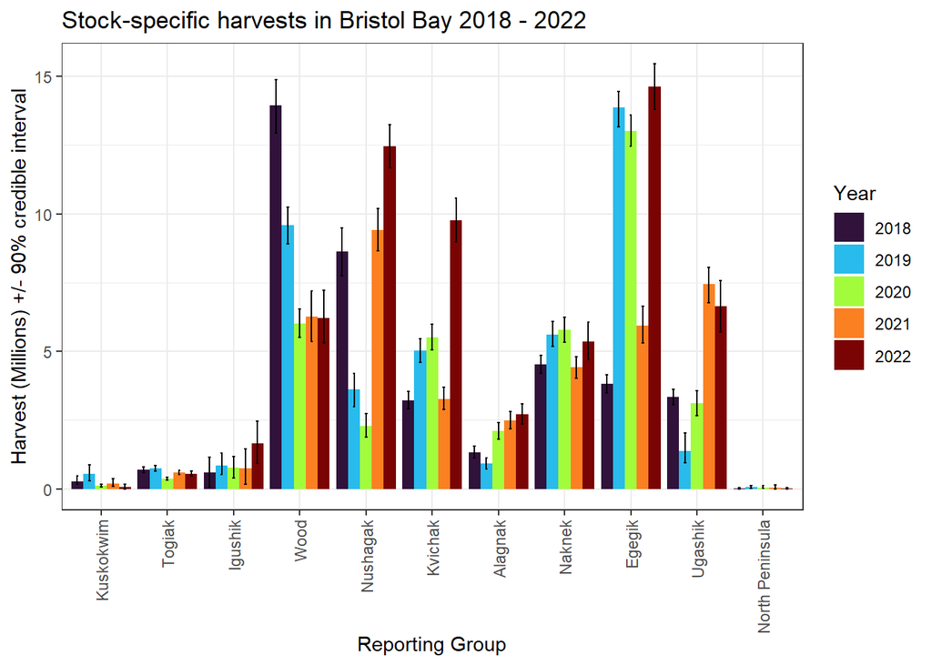

```r
OverallStockHarvests_2018 <- pop_2018_ho_bay$SBBAY %>%
    mutate(Harvest = AnnualHarvests %>%
        filter(YEAR == 2018) %>%
        select(AnnualHarvest) %>%
        pull()) %>%
    mutate(Harvest_Mean = Harvest * mean, Harvest_Median = Harvest * median, Harvest_Lower = Harvest *
        ci.05, Harvest_Upper = Harvest * ci.95) %>%
    select(group, Harvest_Mean, Harvest_Median, Harvest_Lower, Harvest_Upper) %>%
    mutate(Year = 2018)

OverallStockHarvests_2019 <- pop_2019_ho_bay$SBBAY %>%
    mutate(Harvest = AnnualHarvests %>%
        filter(YEAR == 2019) %>%
        select(AnnualHarvest) %>%
        pull()) %>%
    mutate(Harvest_Mean = Harvest * mean, Harvest_Median = Harvest * median, Harvest_Lower = Harvest *
        ci.05, Harvest_Upper = Harvest * ci.95) %>%
    select(group, Harvest_Mean, Harvest_Median, Harvest_Lower, Harvest_Upper) %>%
    mutate(Year = 2019)

OverallStockHarvests_2020 <- pop_2020_ho_bay$SBBAY %>%
    mutate(Harvest = AnnualHarvests %>%
        filter(YEAR == 2020) %>%
        select(AnnualHarvest) %>%
        pull()) %>%
    mutate(Harvest_Mean = Harvest * mean, Harvest_Median = Harvest * median, Harvest_Lower = Harvest *
        ci.05, Harvest_Upper = Harvest * ci.95) %>%
    select(group, Harvest_Mean, Harvest_Median, Harvest_Lower, Harvest_Upper) %>%
    mutate(Year = 2020)

OverallStockHarvests_2021 <- pop_2021_ho_bay$SBBAY %>%
    mutate(Harvest = AnnualHarvests %>%
        filter(YEAR == 2021) %>%
        select(AnnualHarvest) %>%
        pull()) %>%
    mutate(Harvest_Mean = Harvest * mean, Harvest_Median = Harvest * median, Harvest_Lower = Harvest *
        ci.05, Harvest_Upper = Harvest * ci.95) %>%
    select(group, Harvest_Mean, Harvest_Median, Harvest_Lower, Harvest_Upper) %>%
    mutate(Year = 2021)

OverallStockHarvests_2022 <- pop_2022_ho_bay %>%
    mutate(Harvest = AnnualHarvests %>%
        filter(YEAR == 2022) %>%
        select(AnnualHarvest) %>%
        pull()) %>%
    mutate(Harvest_Mean = Harvest * mean, Harvest_Median = Harvest * median, Harvest_Lower = Harvest *
        ci.05, Harvest_Upper = Harvest * ci.95) %>%
    select(group, Harvest_Mean, Harvest_Median, Harvest_Lower, Harvest_Upper) %>%
    mutate(Year = 2022)

AllOverallStockHarvests <- bind_rows(OverallStockHarvests_2018, OverallStockHarvests_2019,
    OverallStockHarvests_2020, OverallStockHarvests_2021, OverallStockHarvests_2022) %>%
    mutate(Year = factor(Year), group = factor(group, levels = c("Kuskokwim", "Togiak",
        "Igushik", "Wood", "Nushagak", "Kvichak", "Alagnak", "Naknek", "Egegik",
        "Ugashik", "North Peninsula")))

AllOverallStockHarvestsFig <- AllOverallStockHarvests %>%
    ggplot(aes(x = group, y = Harvest_Mean/1e+06, fill = Year)) + geom_col(position = "dodge") +
    geom_errorbar(aes(ymin = Harvest_Lower/1e+06, ymax = Harvest_Upper/1e+06), width = 0.2,
        position = position_dodge(0.9)) + theme_bw() + theme(axis.text.x = element_text(angle = 90,
    hjust = 1, vjust = 0.5)) + scale_fill_viridis(discrete = TRUE, option = "H") +
    labs(title = "Stock-specific harvests in Bristol Bay 2018 - 2022", x = "Reporting Group",
        y = "Harvest (Millions) +/- 90% credible interval")

ggsave("AllOverallStockHarvestsFig.png", AllOverallStockHarvestsFig, device = "png",
    height = 6, width = 6, units = "in")

AllOverallStockHarvestsFig
```

```r
DT::datatable(AllOverallStockHarvests) %>%
    formatRound(columns = 2:5, digits = 0)
```

|  | group | Harvest_Mean | Harvest_Median | Harvest_Lower | Harvest_Upper | Year |
| --- | --- | --- | --- | --- | --- | --- |
| 1 | Kuskokwim | 267037.4540229555 | 245473.3236341383 | 165423.2281924396 | 462914.5316098378 | 2018 |
| 2 | Togiak | 696203.6025227936 | 691795.7313142173 | 599093.5298244325 | 803547.0497278579 | 2018 |
| 3 | Igushik | 605569.7698311623 | 591146.486209496 | 67384.1164849297 | 1146168.400081344 | 2018 |
| 4 | Wood | 13937897.35704303 | 13937962.69296644 | 12934054.66451339 | 14883345.4717642 | 2018 |
| 5 | Nushagak | 8620493.842922052 | 8619819.06421991 | 7759126.703317082 | 9475670.492458504 | 2018 |
| 6 | Kvichak | 3224568.763186214 | 3219776.698771872 | 2916097.803025316 | 3542696.199348618 | 2018 |
| 7 | Alagnak | 1335808.544977522 | 1329509.585169317 | 1123152.336057284 | 1565494.508506486 | 2018 |
| 8 | Naknek | 4527143.902086096 | 4521248.19693104 | 4190496.528130364 | 4862238.924552478 | 2018 |
| 9 | Egegik | 3818136.662894188 | 3811711.574597401 | 3503158.031634234 | 4154447.85887479 | 2018 |
| 10 | Ugashik | 3337741.918353469 | 3335888.822879971 | 3055974.781975928 | 3630795.527768593 | 2018 |

[output cut: 45 more lines]

## Bring in areas where averages were applied in terms of both stock- and age-specific harvests

Igushik Section and WRSHA harvests were parsed out to stock using historical stock comp averages when creating the district roll-ups for Curry’s model input files. Here I’m summarizing harvests in those areas in 2018-2022 with harvest numbers from Stacy, bringing in those average stock comps, and observed age comps in each year from ASL data provided by Stacy. Note that no samples were collected from Igushik in 2020-2022 so age compositions are the overall Nushagak District age composition for each year.

## Parse annual stock-specific harvests by stock-specific age composition - Igushik and WRSHA

```r
## Bring in harvests
IgushikWRSHAHarvests <- read_csv("Harvest from Stacy/IgushikWRSHAHarvests.csv")

## Bring in age comps written out from other workspace
AllIgushikWRSHAAgeComps <- readRDS("ASL from Stacy/AllIgushikWRSHAAgeComps.RDs")

## Bring in historical averages we have been applying to harvests in recent
## years
EstDat2022 <- dget("V:/Analysis/2_Central/Sockeye/Bristol Bay/2022 District Harvest/Objects/EstDat2022.txt")

IgushikAverageStockComps <- EstDat2022 %>%
    filter(Mixture == "IgushikAverage") %>%
    select(group = Group, Mean)

## 2018 Igushik AllIgushikWRSHAAgeComps %>% filter(Year == 2018 & Area ==
## 'Igushik') %>% select(age) %>% unique()

IgushikHarvests_2018 <- OverallStockHarvests_2018 %>%
    select(group, Year) %>%
    mutate(Harvest = IgushikWRSHAHarvests %>%
        filter(Year == 2018) %>%
        select(Igushik) %>%
        pull()) %>%
    left_join(x = ., y = IgushikAverageStockComps) %>%
    mutate(StockHarvest = Harvest * Mean, `12` = StockHarvest * AllIgushikWRSHAAgeComps %>%
        filter(Year == 2018 & Area == "Igushik" & age == 12) %>%
        select(Prop) %>%
        pull(), `13` = StockHarvest * AllIgushikWRSHAAgeComps %>%
        filter(Year == 2018 & Area == "Igushik" & age == 13) %>%
        select(Prop) %>%
        pull())

## 2019 Igushik AllIgushikWRSHAAgeComps %>% filter(Year == 2019 & Area ==
## 'Igushik') %>% select(age) %>% unique()

IgushikHarvests_2019 <- OverallStockHarvests_2019 %>%
    select(group, Year) %>%
    mutate(Harvest = IgushikWRSHAHarvests %>%
        filter(Year == 2019) %>%
        select(Igushik) %>%
        pull()) %>%
    left_join(x = ., y = IgushikAverageStockComps) %>%
    mutate(StockHarvest = Harvest * Mean, `12` = StockHarvest * AllIgushikWRSHAAgeComps %>%
        filter(Year == 2019 & Area == "Igushik" & age == 12) %>%
        select(Prop) %>%
        pull(), `13` = StockHarvest * AllIgushikWRSHAAgeComps %>%
        filter(Year == 2019 & Area == "Igushik" & age == 13) %>%
        select(Prop) %>%
        pull(), `14` = StockHarvest * AllIgushikWRSHAAgeComps %>%
        filter(Year == 2019 & Area == "Igushik" & age == 14) %>%
        select(Prop) %>%
        pull(), `22` = StockHarvest * AllIgushikWRSHAAgeComps %>%
        filter(Year == 2019 & Area == "Igushik" & age == 22) %>%
        select(Prop) %>%
        pull(), `23` = StockHarvest * AllIgushikWRSHAAgeComps %>%
        filter(Year == 2019 & Area == "Igushik" & age == 23) %>%
        select(Prop) %>%
        pull())

## 2020 Igushik AllIgushikWRSHAAgeComps %>% filter(Year == 2020 & Area ==
## 'Igushik') %>% select(age) %>% unique()

IgushikHarvests_2020 <- OverallStockHarvests_2020 %>%
    select(group, Year) %>%
    mutate(Harvest = IgushikWRSHAHarvests %>%
        filter(Year == 2020) %>%
        select(Igushik) %>%
        pull()) %>%
    left_join(x = ., y = IgushikAverageStockComps) %>%
    mutate(StockHarvest = Harvest * Mean, `11` = StockHarvest * AllIgushikWRSHAAgeComps %>%
        filter(Year == 2020 & Area == "Igushik" & age == 11) %>%
        select(Prop) %>%
        pull(), `12` = StockHarvest * AllIgushikWRSHAAgeComps %>%
        filter(Year == 2020 & Area == "Igushik" & age == 12) %>%
        select(Prop) %>%
        pull(), `13` = StockHarvest * AllIgushikWRSHAAgeComps %>%
        filter(Year == 2020 & Area == "Igushik" & age == 13) %>%
        select(Prop) %>%
        pull(), `14` = StockHarvest * AllIgushikWRSHAAgeComps %>%
        filter(Year == 2020 & Area == "Igushik" & age == 14) %>%
        select(Prop) %>%
        pull(), `22` = StockHarvest * AllIgushikWRSHAAgeComps %>%
        filter(Year == 2020 & Area == "Igushik" & age == 22) %>%
        select(Prop) %>%
        pull(), `23` = StockHarvest * AllIgushikWRSHAAgeComps %>%
        filter(Year == 2020 & Area == "Igushik" & age == 23) %>%
        select(Prop) %>%
        pull())

## 2021 Igushik AllIgushikWRSHAAgeComps %>% filter(Year == 2021 & Area ==
## 'Igushik') %>% select(age) %>% unique()

IgushikHarvests_2021 <- OverallStockHarvests_2021 %>%
    select(group, Year) %>%
    mutate(Harvest = IgushikWRSHAHarvests %>%
        filter(Year == 2021) %>%
        select(Igushik) %>%
        pull()) %>%
    left_join(x = ., y = IgushikAverageStockComps) %>%
    mutate(StockHarvest = Harvest * Mean, `11` = StockHarvest * AllIgushikWRSHAAgeComps %>%
        filter(Year == 2021 & Area == "Igushik" & age == 11) %>%
        select(Prop) %>%
        pull(), `12` = StockHarvest * AllIgushikWRSHAAgeComps %>%
        filter(Year == 2021 & Area == "Igushik" & age == 12) %>%
        select(Prop) %>%
        pull(), `13` = StockHarvest * AllIgushikWRSHAAgeComps %>%
        filter(Year == 2021 & Area == "Igushik" & age == 13) %>%
        select(Prop) %>%
        pull(), `14` = StockHarvest * AllIgushikWRSHAAgeComps %>%
        filter(Year == 2021 & Area == "Igushik" & age == 14) %>%
        select(Prop) %>%
        pull(), `22` = StockHarvest * AllIgushikWRSHAAgeComps %>%
        filter(Year == 2021 & Area == "Igushik" & age == 22) %>%
        select(Prop) %>%
        pull(), `23` = StockHarvest * AllIgushikWRSHAAgeComps %>%
        filter(Year == 2021 & Area == "Igushik" & age == 23) %>%
        select(Prop) %>%
        pull())

## 2022 Igushik AllIgushikWRSHAAgeComps %>% filter(Year == 2022 & Area ==
## 'Igushik') %>% select(age) %>% unique()

IgushikHarvests_2022 <- OverallStockHarvests_2022 %>%
    select(group, Year) %>%
    mutate(Harvest = IgushikWRSHAHarvests %>%
        filter(Year == 2022) %>%
        select(Igushik) %>%
        pull()) %>%
    left_join(x = ., y = IgushikAverageStockComps) %>%
    mutate(StockHarvest = Harvest * Mean, `11` = StockHarvest * AllIgushikWRSHAAgeComps %>%
        filter(Year == 2022 & Area == "Igushik" & age == 11) %>%
        select(Prop) %>%
        pull(), `12` = StockHarvest * AllIgushikWRSHAAgeComps %>%
        filter(Year == 2022 & Area == "Igushik" & age == 12) %>%
        select(Prop) %>%
        pull(), `13` = StockHarvest * AllIgushikWRSHAAgeComps %>%
        filter(Year == 2022 & Area == "Igushik" & age == 13) %>%
        select(Prop) %>%
        pull(), `14` = StockHarvest * AllIgushikWRSHAAgeComps %>%
        filter(Year == 2022 & Area == "Igushik" & age == 14) %>%
        select(Prop) %>%
        pull(), `22` = StockHarvest * AllIgushikWRSHAAgeComps %>%
        filter(Year == 2022 & Area == "Igushik" & age == 22) %>%
        select(Prop) %>%
        pull(), `23` = StockHarvest * AllIgushikWRSHAAgeComps %>%
        filter(Year == 2022 & Area == "Igushik" & age == 23) %>%
        select(Prop) %>%
        pull())
```

```r
## WRSHA

WRSHAAverageStockComps <- EstDat2022 %>%
    filter(Mixture == "WRSHAAverage") %>%
    select(group = Group, Mean)

## 2018 WRSHA AllIgushikWRSHAAgeComps %>% filter(Year == 2018 & Area ==
## 'WRSHA') %>% select(age) %>% unique()

WRSHAHarvests_2018 <- OverallStockHarvests_2018 %>%
    select(group, Year) %>%
    mutate(Harvest = IgushikWRSHAHarvests %>%
        filter(Year == 2018) %>%
        select(WRSHA) %>%
        pull()) %>%
    left_join(x = ., y = WRSHAAverageStockComps) %>%
    mutate(StockHarvest = Harvest * Mean, `12` = StockHarvest * AllIgushikWRSHAAgeComps %>%
        filter(Year == 2018 & Area == "WRSHA" & age == 12) %>%
        select(Prop) %>%
        pull(), `13` = StockHarvest * AllIgushikWRSHAAgeComps %>%
        filter(Year == 2018 & Area == "WRSHA" & age == 13) %>%
        select(Prop) %>%
        pull(), `22` = StockHarvest * AllIgushikWRSHAAgeComps %>%
        filter(Year == 2018 & Area == "WRSHA" & age == 22) %>%
        select(Prop) %>%
        pull())

## 2019 WRSHA AllIgushikWRSHAAgeComps %>% filter(Year == 2019 & Area ==
## 'WRSHA') %>% select(age) %>% unique()

WRSHAHarvests_2019 <- OverallStockHarvests_2019 %>%
    select(group, Year) %>%
    mutate(Harvest = IgushikWRSHAHarvests %>%
        filter(Year == 2019) %>%
        select(WRSHA) %>%
        pull()) %>%
    left_join(x = ., y = WRSHAAverageStockComps) %>%
    mutate(StockHarvest = Harvest * Mean, `11` = StockHarvest * AllIgushikWRSHAAgeComps %>%
        filter(Year == 2019 & Area == "WRSHA" & age == 11) %>%
        select(Prop) %>%
        pull(), `12` = StockHarvest * AllIgushikWRSHAAgeComps %>%
        filter(Year == 2019 & Area == "WRSHA" & age == 12) %>%
        select(Prop) %>%
        pull(), `13` = StockHarvest * AllIgushikWRSHAAgeComps %>%
        filter(Year == 2019 & Area == "WRSHA" & age == 13) %>%
        select(Prop) %>%
        pull(), `22` = StockHarvest * AllIgushikWRSHAAgeComps %>%
        filter(Year == 2019 & Area == "WRSHA" & age == 22) %>%
        select(Prop) %>%
        pull())

## 2020 WRSHA AllIgushikWRSHAAgeComps %>% filter(Year == 2020 & Area ==
## 'WRSHA') %>% select(age) %>% unique()

WRSHAHarvests_2020 <- OverallStockHarvests_2020 %>%
    select(group, Year) %>%
    mutate(Harvest = IgushikWRSHAHarvests %>%
        filter(Year == 2020) %>%
        select(WRSHA) %>%
        pull()) %>%
    left_join(x = ., y = WRSHAAverageStockComps) %>%
    mutate(StockHarvest = Harvest * Mean, `12` = StockHarvest * AllIgushikWRSHAAgeComps %>%
        filter(Year == 2020 & Area == "WRSHA" & age == 12) %>%
        select(Prop) %>%
        pull(), `13` = StockHarvest * AllIgushikWRSHAAgeComps %>%
        filter(Year == 2020 & Area == "WRSHA" & age == 13) %>%
        select(Prop) %>%
        pull(), `14` = StockHarvest * AllIgushikWRSHAAgeComps %>%
        filter(Year == 2020 & Area == "WRSHA" & age == 14) %>%
        select(Prop) %>%
        pull(), `22` = StockHarvest * AllIgushikWRSHAAgeComps %>%
        filter(Year == 2020 & Area == "WRSHA" & age == 22) %>%
        select(Prop) %>%
        pull())

## 2021 WRSHA AllIgushikWRSHAAgeComps %>% filter(Year == 2021 & Area ==
## 'WRSHA') %>% select(age) %>% unique()

WRSHAHarvests_2021 <- OverallStockHarvests_2021 %>%
    select(group, Year) %>%
    mutate(Harvest = IgushikWRSHAHarvests %>%
        filter(Year == 2021) %>%
        select(WRSHA) %>%
        pull()) %>%
    left_join(x = ., y = WRSHAAverageStockComps) %>%
    mutate(StockHarvest = Harvest * Mean, `12` = StockHarvest * AllIgushikWRSHAAgeComps %>%
        filter(Year == 2021 & Area == "WRSHA" & age == 12) %>%
        select(Prop) %>%
        pull(), `13` = StockHarvest * AllIgushikWRSHAAgeComps %>%
        filter(Year == 2021 & Area == "WRSHA" & age == 13) %>%
        select(Prop) %>%
        pull(), `22` = StockHarvest * AllIgushikWRSHAAgeComps %>%
        filter(Year == 2021 & Area == "WRSHA" & age == 22) %>%
        select(Prop) %>%
        pull(), `23` = StockHarvest * AllIgushikWRSHAAgeComps %>%
        filter(Year == 2021 & Area == "WRSHA" & age == 23) %>%
        select(Prop) %>%
        pull())

## 2022 WRSHA AllIgushikWRSHAAgeComps %>% filter(Year == 2022 & Area ==
## 'WRSHA') %>% select(age) %>% unique()

WRSHAHarvests_2022 <- OverallStockHarvests_2022 %>%
    select(group, Year) %>%
    mutate(Harvest = IgushikWRSHAHarvests %>%
        filter(Year == 2022) %>%
        select(WRSHA) %>%
        pull()) %>%
    left_join(x = ., y = WRSHAAverageStockComps) %>%
    mutate(StockHarvest = Harvest * Mean, `12` = StockHarvest * AllIgushikWRSHAAgeComps %>%
        filter(Year == 2022 & Area == "WRSHA" & age == 12) %>%
        select(Prop) %>%
        pull(), `13` = StockHarvest * AllIgushikWRSHAAgeComps %>%
        filter(Year == 2022 & Area == "WRSHA" & age == 13) %>%
        select(Prop) %>%
        pull(), `14` = StockHarvest * AllIgushikWRSHAAgeComps %>%
        filter(Year == 2022 & Area == "WRSHA" & age == 14) %>%
        select(Prop) %>%
        pull(), `22` = StockHarvest * AllIgushikWRSHAAgeComps %>%
        filter(Year == 2022 & Area == "WRSHA" & age == 22) %>%
        select(Prop) %>%
        pull(), `23` = StockHarvest * AllIgushikWRSHAAgeComps %>%
        filter(Year == 2022 & Area == "WRSHA" & age == 23) %>%
        select(Prop) %>%
        pull())

## Bundle together

IgushikHarvests <- bind_rows(IgushikHarvests_2018, IgushikHarvests_2019, IgushikHarvests_2020,
    IgushikHarvests_2021, IgushikHarvests_2022)

WRSHAHarvests <- bind_rows(WRSHAHarvests_2018, WRSHAHarvests_2019, WRSHAHarvests_2020,
    WRSHAHarvests_2021, WRSHAHarvests_2022)

BothIguWRSHAHarvests <- bind_rows(IgushikHarvests %>%
    mutate(Area = "Igushik"), WRSHAHarvests %>%
    mutate(Area = "WRSHA"))

AllIgushikWRSHAAgeCompsFig <- AllIgushikWRSHAAgeComps %>%
    ggplot(aes(x = Year, y = Prop, fill = age)) + geom_col(position = "stack") +
    theme_bw() + scale_fill_viridis(discrete = TRUE) + facet_wrap(~Area, nrow = 2) +
    labs(title = "Age composition of Igushik and WRSHA in 2018 - 2022", subtitle = "No samples from Igushik in 2020-2022 so district averages applied",
        y = "Proportion")
```

```r
DT::datatable(IgushikWRSHAHarvests) %>%
    formatRound(columns = 2:3, digits = 0)
```

|  | Year | Igushik | WRSHA |
| --- | --- | --- | --- |
| 1 | 2018 | 592000 | 848961 |
| 2 | 2019 | 421347 | 245594 |
| 3 | 2020 | 341218 | 220683 |
| 4 | 2021 | 532091 | 604344 |
| 5 | 2022 | 480297 | 690818 |

```r
DT::datatable(left_join(IgushikAverageStockComps %>%
    dplyr::rename(IgushikMean = Mean), WRSHAAverageStockComps %>%
    dplyr::rename(WRSHAMean = Mean))) %>%
    formatRound(2:3)
```

|  | group | IgushikMean | WRSHAMean |
| --- | --- | --- | --- |
| 1 | Kuskokwim | 0.00014317028 | 0.00025955414 |
| 2 | Togiak | 0.00017826811 | 8.264411e-05 |
| 3 | Igushik | 0.91400814765 | 0.00338094369 |
| 4 | Wood | 0.06657717528 | 0.9207752919 |
| 5 | Nushagak | 0.00575266505 | 0.07486226388 |
| 6 | Kvichak | 0.00543787406 | 0.00025254612 |
| 7 | Alagnak | 0.00413066461 | 0.00011700251 |
| 8 | Naknek | 0.00280916763 | 8.335519e-05 |
| 9 | Egegik | 0.00039215158 | 5.856389e-05 |
| 10 | Ugashik | 0.00047178032 | 7.278836e-05 |

[output cut: 1 more lines]

```r
DT::datatable(AllIgushikWRSHAAgeComps) %>%
    formatRound(3)
```

|  | age | N | Prop | Area | Year |
| --- | --- | --- | --- | --- | --- |
| 1 | 12 | 55 | 0.2217741935483871 | Igushik | 2018 |
| 2 | 13 | 193 | 0.7782258064516129 | Igushik | 2018 |
| 3 | 12 | 270 | 0.7848837209302325 | WRSHA | 2018 |
| 4 | 13 | 72 | 0.2093023255813954 | WRSHA | 2018 |
| 5 | 22 | 2 | 0.005813953488372093 | WRSHA | 2018 |
| 6 | 12 | 205 | 0.1697019867549669 | Igushik | 2019 |
| 7 | 13 | 975 | 0.8071192052980133 | Igushik | 2019 |
| 8 | 14 | 3 | 0.002483443708609272 | Igushik | 2019 |
| 9 | 22 | 15 | 0.01241721854304636 | Igushik | 2019 |
| 10 | 23 | 10 | 0.008278145695364239 | Igushik | 2019 |

[output cut: 35 more lines]

```r
DT::datatable(BothIguWRSHAHarvests) %>%
    formatRound(columns = c(3, 5:11), digits = 0) %>%
    formatRound(columns = 4)
```

|  | group | Year | Harvest | Mean | StockHarvest | 12 | 13 | 14 | 22 | 23 | 11 | Area |
| --- | --- | --- | --- | --- | --- | --- | --- | --- | --- | --- | --- | --- |
| 1 | Kuskokwim | 2018 | 592000 | 0.00014317028 | 84.75680575999999 | 18.79687224516129 | 65.9599335148387 |  |  |  |  | Igushik |
| 2 | Togiak | 2018 | 592000 | 0.00017826811 | 105.53472112 | 23.40487766774194 | 82.12984345225806 |  |  |  |  | Igushik |
| 3 | Igushik | 2018 | 592000 | 0.91400814765 | 541092.8234088001 | 120000.4245463065 | 421092.3988624936 |  |  |  |  | Igushik |
| 4 | Wood | 2018 | 592000 | 0.06657717528 | 39413.68776576 | 8740.938819019355 | 30672.74894674064 |  |  |  |  | Igushik |
| 5 | Nushagak | 2018 | 592000 | 0.00575266505 | 3405.5777096 | 755.2692501129033 | 2650.308459487097 |  |  |  |  | Igushik |
| 6 | Kvichak | 2018 | 592000 | 0.00543787406 | 3219.22144352 | 713.9402394903226 | 2505.281204029678 |  |  |  |  | Igushik |
| 7 | Alagnak | 2018 | 592000 | 0.00413066461 | 2445.35344912 | 542.3162891193549 | 1903.037160000645 |  |  |  |  | Igushik |
| 8 | Naknek | 2018 | 592000 | 0.00280916763 | 1663.02723696 | 368.8165243258064 | 1294.210712634193 |  |  |  |  | Igushik |
| 9 | Egegik | 2018 | 592000 | 0.00039215158 | 232.15373536 | 51.48570743870967 | 180.6680279212903 |  |  |  |  | Igushik |
| 10 | Ugashik | 2018 | 592000 | 0.00047178032 | 279.29394944 | 61.9401904 | 217.35375904 |  |  |  |  | Igushik |

[output cut: 100 more lines]

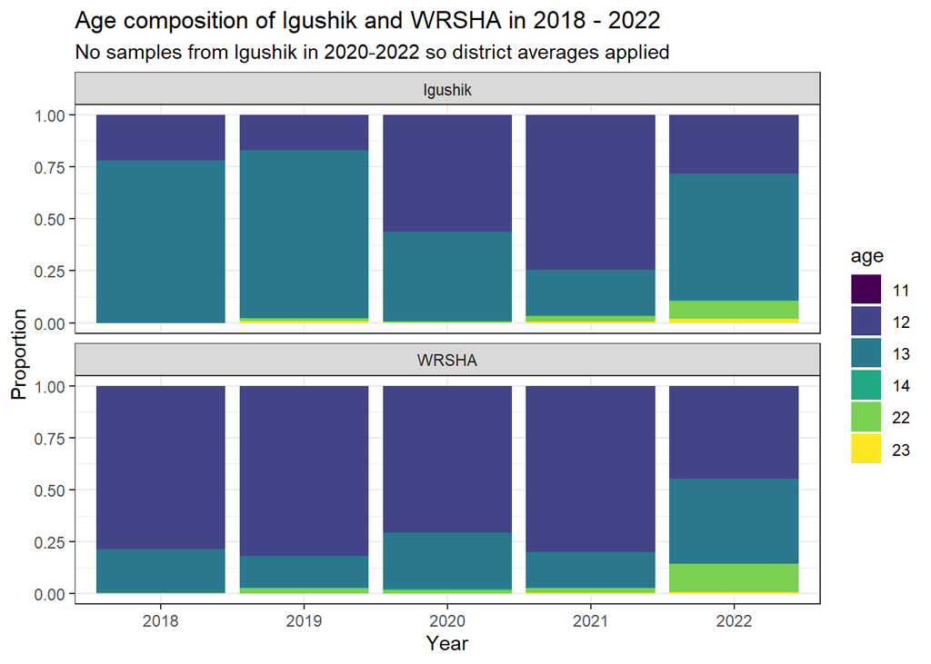

```r
AllIgushikWRSHAAgeCompsFig
```

## Parse annual stock-specific harvests by stock-specific age composition - 2018

Here I’m bundling together the stock-specific age comps for each year and ‘spreading’ out the Bay-wide stock-specific harvests summarized above out to age-specific harvests for each stock. Adding in Igushik/WRSHA stock- and age-specific estimates to magma estimated harvest brood table - left joining and summing columns the same name (overall stock-specific harvest and the six age classes that overlap).

```r
AnnualAgeCompMeans_2018 <- bind_rows(stock_age_2018_ho_bay$`(2)_DSBBAY_Togiak` %>%
    select(group, age, mean) %>%
    pivot_wider(names_from = age, values_from = mean), stock_age_2018_ho_bay$`(3)_DSBBAY_Igushik` %>%
    select(group, age, mean) %>%
    pivot_wider(names_from = age, values_from = mean), stock_age_2018_ho_bay$`(4)_DSBBAY_Wood` %>%
    select(group, age, mean) %>%
    pivot_wider(names_from = age, values_from = mean), stock_age_2018_ho_bay$`(5)_DSBBAY_Nushagak` %>%
    select(group, age, mean) %>%
    pivot_wider(names_from = age, values_from = mean), stock_age_2018_ho_bay$`(6)_DSBBAY_Kvichak` %>%
    select(group, age, mean) %>%
    pivot_wider(names_from = age, values_from = mean), stock_age_2018_ho_bay$`(7)_DSBBAY_Alagnak` %>%
    select(group, age, mean) %>%
    pivot_wider(names_from = age, values_from = mean), stock_age_2018_ho_bay$`(8)_DSBBAY_Naknek` %>%
    select(group, age, mean) %>%
    pivot_wider(names_from = age, values_from = mean), stock_age_2018_ho_bay$`(9)_DSBBAY_Egegik` %>%
    select(group, age, mean) %>%
    pivot_wider(names_from = age, values_from = mean), stock_age_2018_ho_bay$`(10)_DSBBAY_Ugashik` %>%
    select(group, age, mean) %>%
    pivot_wider(names_from = age, values_from = mean))

HarvestBroodTable_2018 <- OverallStockHarvests_2018 %>%
    select(group, Harvest_Mean) %>%
    slice(2:10) %>%
    left_join(., y = AnnualAgeCompMeans_2018) %>%
    mutate(across(.cols = 3:14, ~.x * Harvest_Mean))

## Bundle up stock- and age-specific harvests from both Igushik and WRSHA to
## add to
BothIguWRSHAHarvestsCollapsed <- BothIguWRSHAHarvests %>%
    replace_na(replace = list(`12` = 0, `13` = 0, `14` = 0, `22` = 0, `23` = 0, `11` = 0)) %>%
    group_by(Year, group) %>%
    summarize(Harvest = sum(Harvest), StockHarvest = sum(StockHarvest), `12` = sum(`12`),
        `13` = sum(`13`), `14` = sum(`14`), `22` = sum(`22`), `23` = sum(`23`), `11` = sum(`11`))

## Add Igushik/WRSHA stock- and age-specific to magma estimated harvest brood
## table - left joining and summing columns the same name (overall
## stock-specific harvest and the six age classes that overlap)
HarvestBroodTable_2018_WithIgushikWRSHA <- left_join(HarvestBroodTable_2018, BothIguWRSHAHarvestsCollapsed %>%
    filter(Year == 2018), by = "group") %>%
    mutate(Harvest_Stock = Harvest_Mean + StockHarvest, `11` = `11.x` + `11.y`, `12` = `12.x` +
        `12.y`, `13` = `13.x` + `13.y`, `14` = `14.x` + `14.y`, `22` = `22.x` + `22.y`,
        `23` = `23.x` + `23.y`) %>%
    select(group, Harvest_Stock, `03`, `11`, `12`, `13`, `14`, `15`, `21`, `22`,
        `23`, `24`, `32`, `33`)

HarvestBroodTable_2018Fig <- HarvestBroodTable_2018_WithIgushikWRSHA %>%
    select(-Harvest_Stock) %>%
    pivot_longer(cols = 2:13, names_to = "Age", values_to = "Harvest") %>%
    mutate(group = factor(group, levels = c("Togiak", "Igushik", "Wood", "Nushagak",
        "Kvichak", "Alagnak", "Naknek", "Egegik", "Ugashik")), Age = factor(Age,
        levels = c("03", "11", "12", "13", "14", "15", "21", "22", "23", "24", "32",
            "33"))) %>%
    ggplot(aes(x = group, y = Harvest, fill = Age)) + geom_col(position = "stack") +
    theme_bw() + scale_fill_viridis(discrete = TRUE, option = "H") + labs(title = "Stock- and age-specific harvests in Bristol Bay - 2018",
    x = "Stock")

write_csv(HarvestBroodTable_2018_WithIgushikWRSHA, file = "HarvestBroodTable_2018.csv")

DT::datatable(HarvestBroodTable_2018_WithIgushikWRSHA) %>%
    formatRound(2:14, digits = 0)
```

|  | group | Harvest_Stock | 03 | 11 | 12 | 13 | 14 | 15 | 21 | 22 | 23 | 24 | 32 | 33 |
| --- | --- | --- | --- | --- | --- | --- | --- | --- | --- | --- | --- | --- | --- | --- |
| 1 | Togiak | 696379.2988701833 | 2.963421759327154e-13 | 552.116388154377 | 255145.1867141979 | 425794.7332813852 | 5779.750779907912 | 278.3842218117077 | 400.3223415022391 | 3014.692706757748 | 4366.742969839954 | 382.0677850495033 | 6.333914952990932e-147 | 665.3016815767708 |
| 2 | Igushik | 1149532.882575968 | 1.347437464353544e-302 | 1792.314912686858 | 531368.5756293713 | 591141.1257878984 | 6645.733995225078 | 1046.061709170627 | 1710.071530553087 | 5551.307489101849 | 6646.830251971264 | 1254.604559416994 | 1.347437464353544e-302 | 2376.256710572998 |
| 3 | Wood | 14759013.3573955 | 1.266139313103215e-68 | 3889.254780694579 | 10444155.55551187 | 4158197.656404099 | 34470.70838256833 | 602.4608236065963 | 2032.388597069894 | 69982.85198760446 | 43386.45444616205 | 714.9673617563676 | 7.032670075994894e-40 | 1581.059100070288 |
| 4 | Nushagak | 8687454.563037481 | 1.85129552403149e-183 | 2022.654992410673 | 4231006.706024415 | 4313884.638756507 | 31050.30361013324 | 411.7994477853038 | 1145.735742781379 | 53239.27405735465 | 53264.31639656742 | 483.0593057358092 | 5.185374369160616e-91 | 946.0747037913401 |
| 5 | Kvichak | 3228002.386436315 | 7.17490365992454e-302 | 1145.831294402557 | 1865940.129095014 | 1187361.748552675 | 12810.53956212596 | 391.2371950710147 | 751.2360168752944 | 54714.05583413156 | 101908.64717228 | 1537.735171235003 | 3.771295773552832e-80 | 1441.226542504822 |
| 6 | Alagnak | 1338353.228994534 | 2.972272673400026e-302 | 214.3721742650819 | 484952.3355126691 | 788518.819966506 | 2813.707724114401 | 87.33372357170245 | 122.359065026139 | 9070.083588381294 | 52155.19758626916 | 251.5387484662159 | 2.972272673400026e-302 | 167.4809052653014 |
| 7 | Naknek | 4528877.694628513 | 7.74496104843681e-180 | 1001.703000438839 | 1037442.588098331 | 3049900.386765383 | 17049.50088190321 | 231.3239907154218 | 768.8655200666867 | 112825.6508100053 | 306871.4662141657 | 2381.239698420749 | 7.518911231316893e-53 | 404.9696490840585 |
| 8 | Egegik | 3818418.535088167 | 8.495636076813781e-302 | 7626.335443650078 | 898731.2438560195 | 1690574.396833979 | 2203.041001354668 | 100.2290038628395 | 143.7243118067558 | 296941.8357505865 | 915667.0969064266 | 142.2475719317439 | 5.181905022534572e-279 | 6288.384408549459 |
| 9 | Ugashik | 3338083.006781803 | 7.426722288971979e-302 | 2453.502463320121 | 1629580.525072921 | 1434235.667392424 | 1269.954878320631 | 692.0899168527998 | 324.4699205461729 | 79171.29141122293 | 188267.5433453299 | 705.5665862564814 | 1.402377013411022e-105 | 1382.39579460874 |

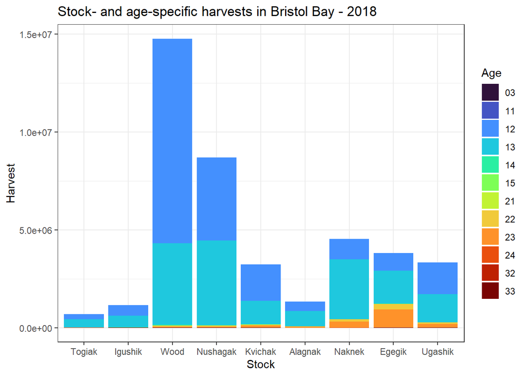

```r
HarvestBroodTable_2018Fig
```

## Parse annual stock-specific harvests by stock-specific age composition - 2019

Here I’m bundling together the stock-specific age comps for each year and ‘spreading’ out the Bay-wide stock-specific harvests summarized above out to age-specific harvests for each stock. Adding in Igushik/WRSHA stock- and age-specific estimates to magma estimated harvest brood table - left joining and summing columns the same name (overall stock-specific harvest and the six age classes that overlap).

```r
## 2019
AnnualAgeCompMeans_2019 <- bind_rows(stock_age_2019_ho_bay$`(2)_DSBBAY_Togiak` %>%
    select(group, age, mean) %>%
    pivot_wider(names_from = age, values_from = mean), stock_age_2019_ho_bay$`(3)_DSBBAY_Igushik` %>%
    select(group, age, mean) %>%
    pivot_wider(names_from = age, values_from = mean), stock_age_2019_ho_bay$`(4)_DSBBAY_Wood` %>%
    select(group, age, mean) %>%
    pivot_wider(names_from = age, values_from = mean), stock_age_2019_ho_bay$`(5)_DSBBAY_Nushagak` %>%
    select(group, age, mean) %>%
    pivot_wider(names_from = age, values_from = mean), stock_age_2019_ho_bay$`(6)_DSBBAY_Kvichak` %>%
    select(group, age, mean) %>%
    pivot_wider(names_from = age, values_from = mean), stock_age_2019_ho_bay$`(7)_DSBBAY_Alagnak` %>%
    select(group, age, mean) %>%
    pivot_wider(names_from = age, values_from = mean), stock_age_2019_ho_bay$`(8)_DSBBAY_Naknek` %>%
    select(group, age, mean) %>%
    pivot_wider(names_from = age, values_from = mean), stock_age_2019_ho_bay$`(9)_DSBBAY_Egegik` %>%
    select(group, age, mean) %>%
    pivot_wider(names_from = age, values_from = mean), stock_age_2019_ho_bay$`(10)_DSBBAY_Ugashik` %>%
    select(group, age, mean) %>%
    pivot_wider(names_from = age, values_from = mean))

HarvestBroodTable_2019 <- OverallStockHarvests_2019 %>%
    select(group, Harvest_Mean) %>%
    slice(2:10) %>%
    left_join(., y = AnnualAgeCompMeans_2019) %>%
    mutate(across(.cols = 3:14, ~.x * Harvest_Mean))

## Add Igushik/WRSHA stock- and age-specific to magma estimated harvest brood
## table - left joining and summing columns the same name (overall
## stock-specific harvest and the six age classes that overlap)
HarvestBroodTable_2019_WithIgushikWRSHA <- left_join(HarvestBroodTable_2019, BothIguWRSHAHarvestsCollapsed %>%
    filter(Year == 2019), by = "group") %>%
    mutate(Harvest_Stock = Harvest_Mean + StockHarvest, `11` = `11.x` + `11.y`, `12` = `12.x` +
        `12.y`, `13` = `13.x` + `13.y`, `14` = `14.x` + `14.y`, `22` = `22.x` + `22.y`,
        `23` = `23.x` + `23.y`) %>%
    select(group, Harvest_Stock, `03`, `11`, `12`, `13`, `14`, `15`, `21`, `22`,
        `23`, `24`, `32`, `33`)

HarvestBroodTable_2019Fig <- HarvestBroodTable_2019_WithIgushikWRSHA %>%
    select(-Harvest_Stock) %>%
    pivot_longer(cols = 2:13, names_to = "Age", values_to = "Harvest") %>%
    mutate(group = factor(group, levels = c("Togiak", "Igushik", "Wood", "Nushagak",
        "Kvichak", "Alagnak", "Naknek", "Egegik", "Ugashik")), Age = factor(Age,
        levels = c("03", "11", "12", "13", "14", "15", "21", "22", "23", "24", "32",
            "33"))) %>%
    ggplot(aes(x = group, y = Harvest, fill = Age)) + geom_col(position = "stack") +
    theme_bw() + scale_fill_viridis(discrete = TRUE, option = "H") + labs(title = "Stock- and age-specific harvests in Bristol Bay - 2019",
    x = "Stock")

write_csv(HarvestBroodTable_2019_WithIgushikWRSHA, file = "HarvestBroodTable_2019.csv")

DT::datatable(HarvestBroodTable_2019_WithIgushikWRSHA) %>%
    formatRound(2:14, digits = 0)
```

|  | group | Harvest_Stock | 03 | 11 | 12 | 13 | 14 | 15 | 21 | 22 | 23 | 24 | 32 | 33 |
| --- | --- | --- | --- | --- | --- | --- | --- | --- | --- | --- | --- | --- | --- | --- |
| 1 | Togiak | 741144.5068370654 | 0.08648133936025283 | 1311.18759633894 | 135043.9515143948 | 591815.8129762844 | 1508.213516027313 | 0.1031462863707747 | 1229.936592006605 | 5973.661323226083 | 3247.298185869663 | 1.929620531828684e-07 | 0.004591484646542286 | 1014.250913614363 |
| 2 | Igushik | 1247951.319503335 | 4.489210344787906e-08 | 2795.507079752737 | 462910.1912501132 | 748259.3478790853 | 3548.283020699163 | 1.741728122345684e-15 | 1573.762143146445 | 17134.24795889603 | 10639.80531303829 | 2.002881795326414e-05 | 4.256610236283356e-10 | 1090.174838529388 |
| 3 | Wood | 9843801.796266684 | 1.179357415199482 | 10808.25603246397 | 4796804.439176655 | 4702312.247136503 | 20152.63449619038 | 0.3285333551633104 | 5812.107190560204 | 227604.3268056171 | 76711.99548307278 | 0.1149183469190462 | 0.5344728134990242 | 3593.632663689358 |
| 4 | Nushagak | 3632393.202232717 | 0.03458476910903956 | 7150.8010146719 | 1551679.272995854 | 1937933.646073988 | 12674.25026287429 | 0.004939920685961506 | 3872.261225961031 | 90848.46694631838 | 25580.60052948792 | 0.006958353908674384 | 2.062303124582698e-08 | 2653.856700496982 |
| 5 | Kvichak | 5038721.909685466 | 0.0003114923040534985 | 5978.67991295329 | 2698486.216113735 | 2069015.858665001 | 11197.11526912233 | 0.0003347503618351317 | 5407.276154254455 | 147990.5957104371 | 96241.54519604941 | 0.09761861505522566 | 0.01282759742265542 | 4404.511571458449 |
| 6 | Alagnak | 935141.1511349011 | 7.194852249785649e-05 | 2000.823003736355 | 549048.0418964783 | 321745.5660850193 | 3663.052748237674 | 1.606638900976837e-13 | 1507.874008377991 | 46256.43367227309 | 9576.555132697298 | 6.93135548421037e-09 | 3.738728259234371e-05 | 1342.804478738366 |
| 7 | Naknek | 5621084.316446903 | 0.2947859419425738 | 3393.366858373713 | 2975754.117666422 | 2393600.071377672 | 6783.306443603865 | 0.7527693951052008 | 2760.340802013891 | 126904.5380834256 | 109111.3090496182 | 0.03024277201264092 | 3.274255188614264 | 2772.91411247508 |
| 8 | Egegik | 13872974.85880929 | 1.207133461534229e-13 | 4541.96219732111 | 10288774.40576526 | 2283644.543432028 | 2700.259964776737 | 1.026607384651484e-11 | 13196.50174549524 | 971857.041578429 | 304614.8294717566 | 0.0001053316155088906 | 2.289490332831617 | 3643.025058557163 |
| 9 | Ugashik | 1385876.941123283 | 0.001540120938436644 | 2317.484338440442 | 612687.1040720802 | 707396.5365178967 | 1483.277116389625 | 5.44400364990839e-09 | 1879.10530521677 | 31877.54839665625 | 26936.60752941174 | 0.00613682954627478 | 0.5339291282254699 | 1298.736241106619 |

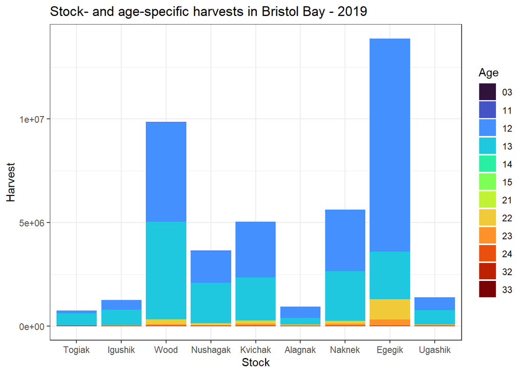

```r
HarvestBroodTable_2019Fig
```

## Parse annual stock-specific harvests by stock-specific age composition - 2020

Here I’m bundling together the stock-specific age comps for each year and ‘spreading’ out the Bay-wide stock-specific harvests summarized above out to age-specific harvests for each stock. Adding in Igushik/WRSHA stock- and age-specific estimates to magma estimated harvest brood table - left joining and summing columns the same name (overall stock-specific harvest and the six age classes that overlap).

```r
## 2020
AnnualAgeCompMeans_2020 <- bind_rows(stock_age_2020_ho_bay$`(2)_DSBBAY_Togiak` %>%
    select(group, age, mean) %>%
    pivot_wider(names_from = age, values_from = mean), stock_age_2020_ho_bay$`(3)_DSBBAY_Igushik` %>%
    select(group, age, mean) %>%
    pivot_wider(names_from = age, values_from = mean), stock_age_2020_ho_bay$`(4)_DSBBAY_Wood` %>%
    select(group, age, mean) %>%
    pivot_wider(names_from = age, values_from = mean), stock_age_2020_ho_bay$`(5)_DSBBAY_Nushagak` %>%
    select(group, age, mean) %>%
    pivot_wider(names_from = age, values_from = mean), stock_age_2020_ho_bay$`(6)_DSBBAY_Kvichak` %>%
    select(group, age, mean) %>%
    pivot_wider(names_from = age, values_from = mean), stock_age_2020_ho_bay$`(7)_DSBBAY_Alagnak` %>%
    select(group, age, mean) %>%
    pivot_wider(names_from = age, values_from = mean), stock_age_2020_ho_bay$`(8)_DSBBAY_Naknek` %>%
    select(group, age, mean) %>%
    pivot_wider(names_from = age, values_from = mean), stock_age_2020_ho_bay$`(9)_DSBBAY_Egegik` %>%
    select(group, age, mean) %>%
    pivot_wider(names_from = age, values_from = mean), stock_age_2020_ho_bay$`(10)_DSBBAY_Ugashik` %>%
    select(group, age, mean) %>%
    pivot_wider(names_from = age, values_from = mean))

HarvestBroodTable_2020 <- OverallStockHarvests_2020 %>%
    select(group, Harvest_Mean) %>%
    slice(2:10) %>%
    left_join(., y = AnnualAgeCompMeans_2020) %>%
    mutate(across(.cols = 3:14, ~.x * Harvest_Mean))

## Add Igushik/WRSHA stock- and age-specific to magma estimated harvest brood
## table - left joining and summing columns the same name (overall
## stock-specific harvest and the six age classes that overlap)
HarvestBroodTable_2020_WithIgushikWRSHA <- left_join(HarvestBroodTable_2020, BothIguWRSHAHarvestsCollapsed %>%
    filter(Year == 2020), by = "group") %>%
    mutate(Harvest_Stock = Harvest_Mean + StockHarvest, `11` = `11.x` + `11.y`, `12` = `12.x` +
        `12.y`, `13` = `13.x` + `13.y`, `14` = `14.x` + `14.y`, `22` = `22.x` + `22.y`,
        `23` = `23.x` + `23.y`) %>%
    select(group, Harvest_Stock, `03`, `11`, `12`, `13`, `14`, `15`, `21`, `22`,
        `23`, `24`, `32`, `33`)

HarvestBroodTable_2020Fig <- HarvestBroodTable_2020_WithIgushikWRSHA %>%
    select(-Harvest_Stock) %>%
    pivot_longer(cols = 2:13, names_to = "Age", values_to = "Harvest") %>%
    mutate(group = factor(group, levels = c("Togiak", "Igushik", "Wood", "Nushagak",
        "Kvichak", "Alagnak", "Naknek", "Egegik", "Ugashik")), Age = factor(Age,
        levels = c("03", "11", "12", "13", "14", "15", "21", "22", "23", "24", "32",
            "33"))) %>%
    ggplot(aes(x = group, y = Harvest, fill = Age)) + geom_col(position = "stack") +
    theme_bw() + scale_fill_viridis(discrete = TRUE, option = "H") + labs(title = "Stock- and age-specific harvests in Bristol Bay - 2020",
    x = "Stock")

write_csv(HarvestBroodTable_2020_WithIgushikWRSHA, file = "HarvestBroodTable_2020.csv")

DT::datatable(HarvestBroodTable_2020_WithIgushikWRSHA) %>%
    formatRound(2:14, digits = 0)
```

|  | group | Harvest_Stock | 03 | 11 | 12 | 13 | 14 | 15 | 21 | 22 | 23 | 24 | 32 | 33 |
| --- | --- | --- | --- | --- | --- | --- | --- | --- | --- | --- | --- | --- | --- | --- |
| 1 | Togiak | 362224.0334852965 | 1.647218022526818e-163 | 1041.619374961726 | 97883.21796520705 | 255562.4760718926 | 2751.867459337432 | 2.017113545195561e-97 | 699.8764354502146 | 2483.238706340263 | 1801.737472107233 | 1.702409942638913e-152 | 1.11284294726936e-40 | 8.057992991667e-303 |
| 2 | Igushik | 1081113.304160075 | 4.408344524233603e-146 | 1234.913530606696 | 488254.0368353735 | 581592.8782848319 | 1894.206522643564 | 7.196782333933654e-36 | 383.041698567368 | 5346.28810080324 | 2407.93918724926 | 1.709949580016069e-302 | 1.113315512744041e-15 | 1.709949580016069e-302 |
| 3 | Wood | 6246458.713006036 | 1.300063111149434e-13 | 10827.29206134589 | 3646970.525520523 | 2530113.134187062 | 12380.43822069796 | 7.164345503386209e-121 | 1220.219622322806 | 23622.18950755299 | 21324.91388653246 | 5.696454343132228e-71 | 4.615348291490969e-38 | 1.762187587016956e-111 |
| 4 | Nushagak | 2314734.018552955 | 5.006486595259615e-226 | 1757.207797043222 | 1259115.005524898 | 1037491.279024556 | 4284.867605617102 | 5.109326463297558e-302 | 801.871623757343 | 7731.25467391804 | 3552.215788778695 | 4.882803611558566e-105 | 3.111212145570388e-07 | 0.3165140752128601 |
| 5 | Kvichak | 5516674.555583396 | 2.267380106599584e-42 | 1673.112937572396 | 1145098.006623836 | 4266964.907474748 | 2813.708166400228 | 1.576270629187043e-136 | 1637.63218797889 | 84917.30077800289 | 13569.88741485798 | 2.90145241619472e-32 | 1.188401018194215e-145 | 5.223980607531456e-18 |
| 6 | Alagnak | 2101971.563154743 | 4.673848377874152e-302 | 528.8028935124969 | 389953.4521259162 | 1686634.875598321 | 845.7846525963173 | 1.653160733612611e-226 | 307.2916884842576 | 14908.90699053208 | 8792.44920538084 | 4.872270493901568e-96 | 3.699333551257695e-121 | 4.673848377874152e-302 |
| 7 | Naknek | 5785574.554611995 | 7.355524846641225e-54 | 4758.392609142167 | 808243.2453558972 | 4776859.664277237 | 1411.938469950737 | 2.556014227764162e-86 | 940.3913587072327 | 118081.584801566 | 75279.337739495 | 3.274795792788289e-52 | 1.950805852463509e-185 | 2.999019280889932e-220 |
| 8 | Egegik | 13018235.1675019 | 2.896620826282721e-301 | 5022.418787200488 | 1343468.549428008 | 10374348.60409422 | 859.3597741343856 | 8.242872069409444e-06 | 19676.29177619844 | 1085493.646336235 | 189366.2972976672 | 2.896620776575663e-301 | 1.10942458127649e-47 | 2.896620826282721e-301 |
| 9 | Ugashik | 3104611.388593612 | 6.907595707630044e-302 | 1065.48822088889 | 1270501.988799234 | 1420426.762089014 | 2582.665926986023 | 6.907595707630044e-302 | 1120.86418756623 | 380879.3710613803 | 28034.24830854282 | 1.207756202112759e-301 | 6.907595707630044e-302 | 5.771636923407082e-225 |

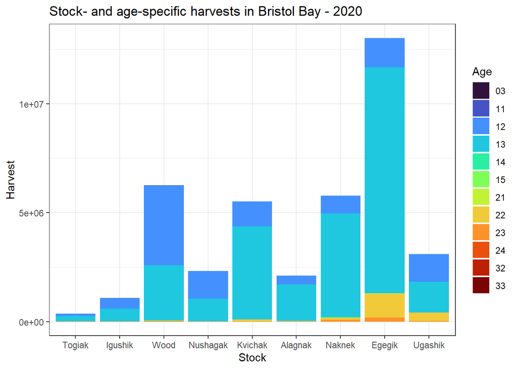

```r
HarvestBroodTable_2020Fig
```

## Parse annual stock-specific harvests by stock-specific age composition - 2021

Here I’m bundling together the stock-specific age comps for each year and ‘spreading’ out the Bay-wide stock-specific harvests summarized above out to age-specific harvests for each stock. Adding in Igushik/WRSHA stock- and age-specific estimates to magma estimated harvest brood table - left joining and summing columns the same name (overall stock-specific harvest and the six age classes that overlap).

```r
## 2021
AnnualAgeCompMeans_2021 <- bind_rows(stock_age_2021_ho_bay$`(2)_DSBBAY_Togiak` %>%
    select(group, age, mean) %>%
    pivot_wider(names_from = age, values_from = mean), stock_age_2021_ho_bay$`(3)_DSBBAY_Igushik` %>%
    select(group, age, mean) %>%
    pivot_wider(names_from = age, values_from = mean), stock_age_2021_ho_bay$`(4)_DSBBAY_Wood` %>%
    select(group, age, mean) %>%
    pivot_wider(names_from = age, values_from = mean), stock_age_2021_ho_bay$`(5)_DSBBAY_Nushagak` %>%
    select(group, age, mean) %>%
    pivot_wider(names_from = age, values_from = mean), stock_age_2021_ho_bay$`(6)_DSBBAY_Kvichak` %>%
    select(group, age, mean) %>%
    pivot_wider(names_from = age, values_from = mean), stock_age_2021_ho_bay$`(7)_DSBBAY_Alagnak` %>%
    select(group, age, mean) %>%
    pivot_wider(names_from = age, values_from = mean), stock_age_2021_ho_bay$`(8)_DSBBAY_Naknek` %>%
    select(group, age, mean) %>%
    pivot_wider(names_from = age, values_from = mean), stock_age_2021_ho_bay$`(9)_DSBBAY_Egegik` %>%
    select(group, age, mean) %>%
    pivot_wider(names_from = age, values_from = mean), stock_age_2021_ho_bay$`(10)_DSBBAY_Ugashik` %>%
    select(group, age, mean) %>%
    pivot_wider(names_from = age, values_from = mean))

HarvestBroodTable_2021 <- OverallStockHarvests_2021 %>%
    select(group, Harvest_Mean) %>%
    slice(2:10) %>%
    left_join(., y = AnnualAgeCompMeans_2021) %>%
    mutate(across(.cols = 3:14, ~.x * Harvest_Mean))

## Add Igushik/WRSHA stock- and age-specific to magma estimated harvest brood
## table - left joining and summing columns the same name (overall
## stock-specific harvest and the six age classes that overlap)
HarvestBroodTable_2021_WithIgushikWRSHA <- left_join(HarvestBroodTable_2021, BothIguWRSHAHarvestsCollapsed %>%
    filter(Year == 2021), by = "group") %>%
    mutate(Harvest_Stock = Harvest_Mean + StockHarvest, `11` = `11.x` + `11.y`, `12` = `12.x` +
        `12.y`, `13` = `13.x` + `13.y`, `14` = `14.x` + `14.y`, `22` = `22.x` + `22.y`,
        `23` = `23.x` + `23.y`) %>%
    select(group, Harvest_Stock, `03`, `11`, `12`, `13`, `14`, `15`, `21`, `22`,
        `23`, `24`, `32`, `33`)

HarvestBroodTable_2021Fig <- HarvestBroodTable_2021_WithIgushikWRSHA %>%
    select(-Harvest_Stock) %>%
    pivot_longer(cols = 2:13, names_to = "Age", values_to = "Harvest") %>%
    mutate(group = factor(group, levels = c("Togiak", "Igushik", "Wood", "Nushagak",
        "Kvichak", "Alagnak", "Naknek", "Egegik", "Ugashik")), Age = factor(Age,
        levels = c("03", "11", "12", "13", "14", "15", "21", "22", "23", "24", "32",
            "33"))) %>%
    ggplot(aes(x = group, y = Harvest, fill = Age)) + geom_col(position = "stack") +
    theme_bw() + scale_fill_viridis(discrete = TRUE, option = "H") + labs(title = "Stock- and age-specific harvests in Bristol Bay - 2021",
    x = "Stock")

write_csv(HarvestBroodTable_2021_WithIgushikWRSHA, file = "HarvestBroodTable_2021.csv")

DT::datatable(HarvestBroodTable_2021_WithIgushikWRSHA) %>%
    formatRound(2:14, digits = 0)
```

|  | group | Harvest_Stock | 03 | 11 | 12 | 13 | 14 | 15 | 21 | 22 | 23 | 24 | 32 | 33 |
| --- | --- | --- | --- | --- | --- | --- | --- | --- | --- | --- | --- | --- | --- | --- |
| 1 | Togiak | 586453.3008624407 | 5.463882465974961e-110 | 1502.648310499664 | 277084.7751528309 | 299482.2942593094 | 3771.419749197792 | 8.595103280929002e-75 | 387.3537767916175 | 2326.979217381936 | 1521.310414187137 | 376.5199822421963 | 1.372626038109196e-37 | 1.304579712006216e-302 |
| 2 | Igushik | 1241625.664900452 | 3.705566873305153e-221 | 3050.221417308418 | 851128.8673736297 | 324439.1822085947 | 5641.796211770714 | 1.676029991922999e-302 | 786.9347629811966 | 43724.45321056899 | 12231.69082927778 | 622.5188863206666 | 1.676029991922999e-302 | 1.67602215448483e-302 |
| 3 | Wood | 6867985.876777073 | 7.081640255514685e-15 | 2209.868691396465 | 5334644.529123135 | 1302607.88304684 | 10932.26446645755 | 7.66421292944022e-66 | 786.7228203401334 | 187608.006581232 | 28505.76616026249 | 690.8358874091117 | 8.116097781916695e-126 | 4.728448814453461e-175 |
| 4 | Nushagak | 9460252.031257205 | 1.611433200609393e-147 | 2497.161528115447 | 6794430.089812974 | 2469686.70939874 | 22741.02386121271 | 2.094228063161991e-301 | 535.9983378141987 | 142917.9095765221 | 26949.32323907531 | 493.8155027522397 | 5.709715024218172e-93 | 3.689880772283596e-42 |
| 5 | Kvichak | 3283176.758631154 | 1.149955638902405e-10 | 2076.200173553202 | 2045794.480593631 | 814748.5835566637 | 21134.50302727371 | 4.150691635193307e-103 | 3444.88399356403 | 268362.2117675394 | 126986.892751681 | 629.0027672484495 | 2.382413434748455e-70 | 2.574657409055762e-88 |
| 6 | Alagnak | 2496373.564546298 | 3.234167063733528e-140 | 1676.410590331205 | 981506.624895941 | 1262076.938593779 | 20822.46653548871 | 1.029806763934871e-254 | 211.3523024516431 | 102476.6650173343 | 127417.4269951508 | 185.6796158218858 | 5.549567758702971e-302 | 4.528664652198324e-191 |
| 7 | Naknek | 4416564.861969289 | 7.062437176565958e-42 | 1543.568681203914 | 1675406.960349714 | 1973791.470261404 | 57784.78766688197 | 7.998955048102486e-82 | 477.2380193864542 | 277143.9711869684 | 430116.88688778 | 299.9789159501798 | 6.017725420670931e-92 | 5.26933660523697e-33 |
| 8 | Egegik | 5933381.626526223 | 1.368757457440367e-198 | 10145.14162467587 | 3132271.248030151 | 764766.0553766524 | 5264.41069007609 | 1.320147291213615e-301 | 6243.967715834786 | 1554749.343017516 | 459633.5409016301 | 307.9191696857494 | 5.035076238964915e-99 | 1.845889836062547e-45 |
| 9 | Ugashik | 7453472.305844006 | 1.658386994317349e-301 | 1861.410543386327 | 4384620.459833598 | 1780288.553524917 | 6793.288444543599 | 5.64227218249541e-50 | 1205.957183285806 | 1022807.297770581 | 248324.1126751053 | 7571.225868588806 | 1.658386994317349e-301 | 2.670515882924062e-271 |

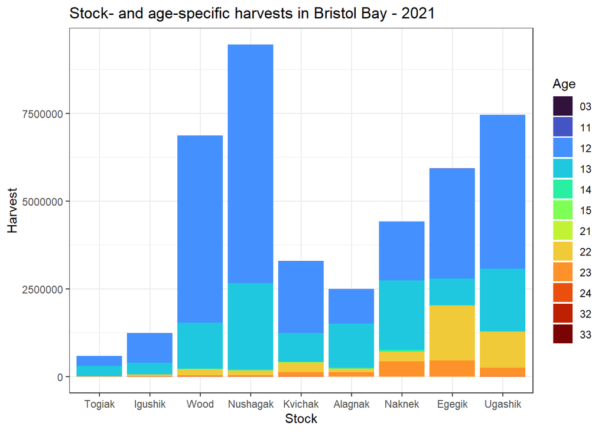

```r
HarvestBroodTable_2021Fig
```

## Parse annual stock-specific harvests by stock-specific age composition - 2022

Here I’m bundling together the stock-specific age comps for each year and ‘spreading’ out the Bay-wide stock-specific harvests summarized above out to age-specific harvests for each stock. Adding in Igushik/WRSHA stock- and age-specific estimates to magma estimated harvest brood table - left joining and summing columns the same name (overall stock-specific harvest and the six age classes that overlap).

```r
## 2022
AnnualAgeCompMeans_2022 <- bind_rows(stock_age_2022_ho_bay$age_summ$`(2)_DSBBAY_Togiak` %>%
    select(group, age, mean) %>%
    pivot_wider(names_from = age, values_from = mean), stock_age_2022_ho_bay$age_summ$`(3)_DSBBAY_Igushik` %>%
    select(group, age, mean) %>%
    pivot_wider(names_from = age, values_from = mean), stock_age_2022_ho_bay$age_summ$`(4)_DSBBAY_Wood` %>%
    select(group, age, mean) %>%
    pivot_wider(names_from = age, values_from = mean), stock_age_2022_ho_bay$age_summ$`(5)_DSBBAY_Nushagak` %>%
    select(group, age, mean) %>%
    pivot_wider(names_from = age, values_from = mean), stock_age_2022_ho_bay$age_summ$`(6)_DSBBAY_Kvichak` %>%
    select(group, age, mean) %>%
    pivot_wider(names_from = age, values_from = mean), stock_age_2022_ho_bay$age_summ$`(7)_DSBBAY_Alagnak` %>%
    select(group, age, mean) %>%
    pivot_wider(names_from = age, values_from = mean), stock_age_2022_ho_bay$age_summ$`(8)_DSBBAY_Naknek` %>%
    select(group, age, mean) %>%
    pivot_wider(names_from = age, values_from = mean), stock_age_2022_ho_bay$age_summ$`(9)_DSBBAY_Egegik` %>%
    select(group, age, mean) %>%
    pivot_wider(names_from = age, values_from = mean), stock_age_2022_ho_bay$age_summ$`(10)_DSBBAY_Ugashik` %>%
    select(group, age, mean) %>%
    pivot_wider(names_from = age, values_from = mean))

HarvestBroodTable_2022 <- OverallStockHarvests_2022 %>%
    select(group, Harvest_Mean) %>%
    slice(-c(4, 7)) %>%
    left_join(., y = AnnualAgeCompMeans_2022) %>%
    mutate(across(.cols = 3:11, ~.x * Harvest_Mean))

## Add Igushik/WRSHA stock- and age-specific to magma estimated harvest brood
## table - left joining and summing columns the same name (overall
## stock-specific harvest and the six age classes that overlap)
HarvestBroodTable_2022_WithIgushikWRSHA <- left_join(HarvestBroodTable_2022, BothIguWRSHAHarvestsCollapsed %>%
    filter(Year == 2022), by = "group") %>%
    mutate(Harvest_Stock = Harvest_Mean + StockHarvest, `12` = `12.x` + `12.y`, `13` = `13.x` +
        `13.y`, `14` = `14.x` + `14.y`, `22` = `22.x` + `22.y`, `23` = `23.x` + `23.y`) %>%
    select(group, Harvest_Stock, `12`, `13`, `14`, `22`, `23`, `24`, `32`, `33`)

HarvestBroodTable_2022Fig <- HarvestBroodTable_2022_WithIgushikWRSHA %>%
    select(-Harvest_Stock) %>%
    pivot_longer(cols = 2:9, names_to = "Age", values_to = "Harvest") %>%
    mutate(group = factor(group, levels = c("Togiak", "Igushik", "Wood", "Nushagak",
        "Kvichak", "Alagnak", "Naknek", "Egegik", "Ugashik")), Age = factor(Age,
        levels = c("12", "13", "14", "22", "23", "24", "32", "33"))) %>%
    ggplot(aes(x = group, y = Harvest, fill = Age)) + geom_col(position = "stack") +
    theme_bw() + scale_fill_viridis(discrete = TRUE, option = "H") + labs(title = "Stock- and age-specific harvests in Bristol Bay - 2022",
    x = "Stock")

HarvestBroodTable_2022_WithIgushikWRSHA <- HarvestBroodTable_2022_WithIgushikWRSHA %>%
    mutate(group = factor(group, levels = c("Togiak", "Igushik", "Wood", "Nushagak",
        "Kvichak", "Alagnak", "Naknek", "Egegik", "Ugashik"))) %>%
    arrange(group)

write_csv(HarvestBroodTable_2022_WithIgushikWRSHA, file = "HarvestBroodTable_2022.csv")

DT::datatable(HarvestBroodTable_2022_WithIgushikWRSHA) %>%
    formatRound(2:10, digits = 0)
```

|  | group | Harvest_Stock | 12 | 13 | 14 | 22 | 23 | 24 | 32 | 33 |
| --- | --- | --- | --- | --- | --- | --- | --- | --- | --- | --- |
| 1 | Togiak | 556617.054361641 | 76898.31395766162 | 464059.6089978412 | 4308.369393648582 | 4377.658999981358 | 3076.775361713157 | 897.7195567035104 | 1076.05205459019 | 908.6189620911938 |
| 2 | Igushik | 2100306.545941273 | 1149714.35730519 | 721549.0311139398 | 18671.16264568262 | 184729.6077150541 | 19215.78820290333 | 1637.513519798919 | 1824.005215718291 | 1411.451074077195 |
| 3 | Wood | 6886199.324756432 | 2594345.82973492 | 3414257.507667943 | 51628.33922906235 | 781633.9685781648 | 31262.68596200779 | 3354.03956346324 | 3318.727956170271 | 3203.083717848054 |
| 4 | Nushagak | 12516213.22263362 | 1634139.074012984 | 9978727.873965958 | 31172.62193050295 | 532448.5108047954 | 329970.121810856 | 2405.961944865518 | 2457.435885986954 | 2504.960590143838 |
| 5 | Kvichak | 9755742.739034168 | 4313152.572147004 | 3150836.982750147 | 11111.03085734433 | 2185963.547281751 | 74112.58538938338 | 4997.99418679613 | 6123.966511130375 | 4804.454311940659 |
| 6 | Alagnak | 2721788.755971348 | 309851.2426696213 | 2090480.650976972 | 3215.702540532732 | 79020.23500200623 | 233034.1108130541 | 1456.468288237732 | 1911.827702666366 | 1361.749510538182 |
| 7 | Naknek | 5357177.085227203 | 1114807.649400972 | 3502365.194312288 | 14356.8899178196 | 459221.7556248373 | 255757.0554077072 | 2436.84505484341 | 3360.177637490479 | 2471.859063044499 |
| 8 | Egegik | 14623253.08103512 | 2448600.870750651 | 3711085.001245047 | 3641.23764327542 | 7667688.958365783 | 784793.3297737865 | 1888.086686432802 | 1911.954806709451 | 1847.888490681497 |
| 9 | Ugashik | 6650385.193561101 | 1357757.701591321 | 4311541.266342101 | 5622.8099748144 | 637747.7080529762 | 330099.30687488 | 1781.954049214732 | 1999.596255965965 | 1913.211882451129 |

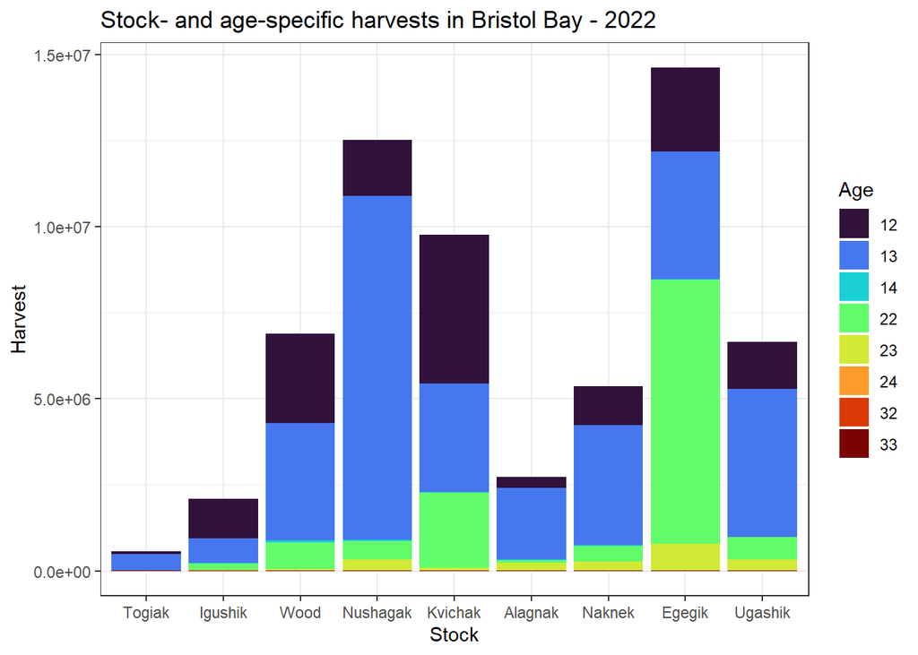

```r
HarvestBroodTable_2022Fig
```

## I haven’t carried these annual estimates of stock- and age-specific harvests to brood tables of harvest (e.g., Ugashik 1.2s in 2020 = BY2016) but I certainly can if you’d like. I thought I’d get this off to area staff/Hamachan sooner than later, but please let me know if you have any questions, concerns or I can provide anything else.